# Characterizing Motion: A Clustering Approach to Identify Driving Behaviors

# Unsupervised clustering of actor trajectories in the Lyft AV dataset to reveal interpretable behavior archetypes.

[Lyft Motion Prediction for Autonomous Vehicles](https://www.kaggle.com/c/lyft-motion-prediction-autonomous-vehicles)

## By: Travis Reinart

### September 10, 2025

#### **• CSCA 5632: *Unsupervised Algorithms in Machine Learning Final Project •*** **• University of Colorado Boulder •**

[GitHub - Week 5 Unsupervised Algorithms in Machine Learning Final Project](https://github.com/treinart/CSCA-5632-Unsupervised-Algorithms-in-Machine-Learning/tree/main/Week%205)

[View Live HTML Analysis](https://treinart.github.io/CSCA-5632-Unsupervised-Algorithms-in-Machine-Learning/CSCA5632_Final_Project_Lyft.html)

[GitHub Release Direct Link (large files)](https://github.com/treinart/CSCA-5632-Unsupervised-Algorithms-in-Machine-Learning/releases/tag/v1)

[Direct Download of Notebook (.ipynb)](https://github.com/treinart/CSCA-5632-Unsupervised-Algorithms-in-Machine-Learning/releases/download/v1/CSCA5632_Final_Project_Lyft.ipynb)

[Direct Download HTML (static file)](https://github.com/treinart/CSCA-5632-Unsupervised-Algorithms-in-Machine-Learning/releases/download/v1/CSCA5632_Final_Project_Lyft.html)

###### Copyright (c) 2025 Travis Reinart

###### Licensed under the [MIT License](https://opensource.org/licenses/MIT).

## Section 1: Introduction & Problem Definition

This notebook documents a complete unsupervised learning workflow that adapts the Lyft Level 5 autonomous vehicle dataset for a novel purpose: pattern discovery. The original Kaggle competition was a supervised forecasting challenge, a task better suited for a different course. Here, I am reframing the problem to align with this course's focus. Instead of predicting future movements, the objective is to analyze past trajectories to automatically discover and classify the fundamental behaviors of vehicles, cyclists, and pedestrians in complex urban environments.

The Lyft Level 5 Motion Prediction dataset was released on Kaggle for a supervised learning competition where the goal was to predict future trajectories of vehicles and pedestrians. That challenge measured success with a forecasting error score. This notebook does not pursue the supervised task. Instead, it reframes the dataset for an **unsupervised learning project**, where the objective is to uncover patterns of driving and pedestrian behaviors without labels or ground truth outcomes.

An autonomous vehicle faces countless scenarios every day: a four-way stop, a pedestrian stepping off the curb, or a vehicle merging into traffic. The ability to recognize these situations quickly is essential for safe navigation. By clustering the trajectories of agents in this dataset, the project seeks to group motion into archetypes such as cars accelerating straight, vehicles turning left, or pedestrians waiting at an intersection. This unsupervised framing fits the course assignment, which requires discovery of hidden structure rather than prediction against a target.

### Unsupervised Learning & Clustering

**Unsupervised Learning** is a branch of machine learning where algorithms learn patterns from data without any explicit labels or predefined outcomes. The goal is to explore the data's hidden structure on its own. For this project, the focus is on **clustering**, a primary unsupervised task where the algorithm groups similar data points together into distinct clusters.

Imagine watching a busy intersection from above. After a while, you'd naturally start categorizing what you see: cars making cautious right turns, others accelerating aggressively straight ahead, and pedestrians waiting patiently on the curb. Clustering algorithms do the same thing, but they use mathematical definitions of "similarity" to find these groups automatically from raw data, revealing the underlying distinct behavioral patterns of the traffic.

### Modeling Strategy: A "Best of Both Worlds" Approach

The analysis uses a two-pipeline strategy to discover these behavioral archetypes:

- **Pipeline A (Classical):** Engineer a set of transparent, human-interpretable features from the trajectory data, such as speed, acceleration, and turning angle, and cluster them using traditional algorithms.
- **Pipeline B (Deep Learning):** Build and train a deep learning **Autoencoder** to learn a rich, compressed representation of the trajectories automatically. These learned "embeddings" will then be clustered to find more nuanced patterns.

By comparing the results of both pipelines, we can leverage the interpretability of the classical approach and the power of the deep learning method. The primary clustering algorithms used will be **K-Means**, **Gaussian Mixture Models (GMM)**, and **HDBSCAN**.

### Framework Choice: PyTorch

**PyTorch** is used in Pipeline B to train the autoencoder on GPU. It offers a concise API, stable CUDA support in WSL2, and fast iteration with `torch` modules and dataloaders. Clustering is performed with Scikit-learn, but representation learning (the autoencoder) runs on PyTorch to leverage the GPU for speed and reproducibility.

### Evaluation & Validation

Since this is an unsupervised task, there is no single "score" to optimize. Instead, cluster quality will be evaluated using a combination of quantitative internal validation metrics and qualitative analysis.

- **Quantitative Metrics:** Use the **Silhouette Score**, **Davies-Bouldin Index**, and **Calinski-Harabasz Index** to measure cluster cohesion and separation.
- **Qualitative Analysis:** The clusters will be visualized using dimensionality reduction (PCA/UMAP), and by creating "Scenario Cards" with exemplar trajectories to interpret and validate the real-world meaning of each discovered behavioral group.

### Project Plan

1. **Section 1: Introduction**: Define the problem, concept, modeling strategy, and evaluation methods.
2. **Section 2: Setup**: Configure the environment, import libraries, and set seeds.
3. **Section 3: Data Loading & Audit**: Load a subset of the Lyft dataset and perform an integrity check.
4. **Section 4: Visual EDA**: Visually inspect the data to understand its underlying distributions.
5. **Section 5: Pipeline A - Classical Feature Engineering**: Create an interpretable feature set from raw trajectories.
6. **Section 6: Pipeline A - Clustering with Classical Features**: Apply and evaluate clustering models on the engineered features.
7. **Section 7: Pipeline B - Deep Learning Feature Extraction**: Build and train an autoencoder to learn trajectory embeddings.
8. **Section 8: Pipeline B - Clustering with Learned Embeddings**: Apply and evaluate clustering models on the autoencoder embeddings.
9. **Section 9: Model Validation and Stress Testing**: Test the stability and generalizability of the clusters.
10. **Section 10: Interpretation - Scenario Archetypes**: Create "Scenario Cards" to interpret and visualize the discovered behaviors.
11. **Section 11: Pipeline Comparison**: Perform a side-by-side comparison of the results from both pipelines.
12. **Section 12: Conclusion & Analysis**: Summarize key findings, learnings, and directions for future work.

## Section 2: Environment Setup & Diagnostics

Before any analysis can begin, the first step is to build a clean and reproducible environment. This section confirms the location of the data sources, provides an optional installer for missing packages, centralizes all library imports, and runs a comprehensive diagnostic script to verify that the GPU is accessible and all dependencies are correctly configured.

### Section Plan:

**Data Sources:** Detail the Lyft dataset components and their purpose.

**Package Installation:** Provide a utility cell for installing any missing libraries.

**Environment Notes:** Include an optional guide for setting up a high-performance WSL2 + PyTorch environment.

**Core Library Imports:** Consolidate all project imports into a single, organized cell.

**Diagnostics & Verification:** Set seeds for reproducibility and run a full diagnostic check on the hardware and software stack.

**Output Utilities:** Create helper functions for saving project artifacts like figures and cached data.

### 2.1 The Dataset: Lyft Autonomous Vehicle Logs

This project is built on the *Lyft Level 5 Motion Prediction* dataset, a rich collection of time-indexed agent trajectories and map data from urban driving environments. While the original Kaggle competition focused on supervised trajectory forecasting, this notebook reframes the dataset for an unsupervised task: discovering and classifying the fundamental behavioral patterns of traffic.

[Kaggle Dataset Page: Lyft Motion Prediction](https://www.kaggle.com/competitions/lyft-motion-prediction-autonomous-vehicles/data)

#### Dataset at a Glance

[output not shown]

The full dataset is about **23.7 GB**. This notebook focuses on `train.zarr` and `val.zarr`, which together provide millions of agent trajectories across diverse urban driving scenes.

#### What is a Zarr File?

Zarr is a storage format designed for large, chunked, multidimensional arrays. Instead of saving everything in one massive file, Zarr breaks data into smaller compressed chunks and organizes them in a directory structure. This makes it efficient to read or write only the slices of data that are needed, which is critical for high-resolution trajectory datasets that cannot fit into memory all at once. In practice, this means a model can stream data in batches from disk without ever loading the entire dataset, keeping both training and analysis scalable.

This notebook was developed using the Jupyter Notebook extension within Visual Studio Code. Generative AI was used as a supplementary tool to assist with code debugging and to refine language for clarity. The core logic and all final analysis are original.

### 2.2 *Optional:* Install Missing Packages

To keep the runtime smooth, use this installer cell when a dependency is missing. Using `%pip` inside Jupyter ensures installation happens in the active kernel environment.

**Instructions:**

Uncomment the needed `%pip install` lines.

Run the cell.

Wait for the “Successfully installed” message.

In the menu, select **Kernel → Restart**.

Re-run the import cell in 2.4.

**Note:** A kernel restart is required for new packages to be recognized by Jupyter.

```python
# Uncomment and run the lines below to install any missing packages.

# --- Core Jupyter environment ---
# %pip install notebook
# %pip install jupyterlab
# %pip install ipywidgets
# %pip install ipykernel
# %pip install kaggle

# --- Core data science and utilities ---
# %pip install numpy
# %pip install pandas
# %pip install scipy
# %pip install scikit-learn
# %pip install tqdm
# %pip install joblib
# %pip install zarr
# %pip install pyarrow
# %pip install openpyxl

# --- Visualization ---
# %pip install matplotlib
# %pip install seaborn
# %pip install plotly

# --- Dimensionality reduction and clustering extras ---
# %pip install umap-learn
# %pip install hdbscan

# --- Geospatial and geometry helpers ---
# %pip install shapely
# %pip install pyproj

# --- PyTorch (choose ONE block) ---
# CPU-only build
# %pip install torch --index-url https://download.pytorch.org/whl/cpu

# CUDA 12.1 build (Windows or WSL2 with NVIDIA driver)
# %pip install torch torchvision torchaudio --index-url https://download.pytorch.org/whl/cu121

# --- Optional: Export to HTML ---
# Most Jupyter installs include nbconvert. If the command fails, install it first.
# %pip install nbconvert
#
# IMPORTANT: This bang command is written for a Windows or plain Python kernel.
# It will not work as-is in a WSL kernel unless you use a Linux path to the notebook.
#/ !jupyter nbconvert --to html "CSCA5632_Final_Project_Lyft.ipynb"
```

### 2.3 *Optional:* Run on GPU with Ubuntu 22.04 + VS Code (WSL2)

This guide sets up Ubuntu 22.04 on WSL2 with PyTorch + CUDA 12.1. The target is a clean Python 3.10.12 environment that runs Jupyter and uses the NVIDIA GPU for training.

#### Step 1: Install Ubuntu on WSL2

| Open PowerShell as Administrator and run: | wsl --install -d Ubuntu-22.04 wsl --set-default-version 2 wsl --update |
| --- | --- |
| Create the Ubuntu user and password. | Tip: The password prompt stays blank while typing. |

#### Step 2: Install the NVIDIA driver in Windows and verify in Ubuntu

| Install the latest Windows driver: | [NVIDIA Driver Downloads](https://www.nvidia.com/Download/index.aspx) |
| --- | --- |
| Verify inside Ubuntu: | nvidia-smi |

#### Step 3: Create the Python 3.10.12 environment

| Install Python and venv: | sudo apt update && sudo apt -y install python3.10 python3.10-venv python3-pip |
| --- | --- |
| Create and activate the env (`avenv`): | python3.10 -m venv ~/avenv source ~/avenv/bin/activate python --version # should print 3.10.12 |
| Install libraries and register the Jupyter kernel: | python -m pip install -U pip pip install numpy pandas scikit-learn matplotlib seaborn tqdm umap-learn hdbscan shapely pyproj ipykernel pip install torch torchvision torchaudio --index-url https://down… |

#### Step 4: Connect with VS Code and select the kernel

| Open a WSL window: | Install “Remote – WSL”. Command Palette → `WSL: Connect to WSL`. Status bar should read **WSL: Ubuntu-22.04**. |
| --- | --- |
| Select the Jupyter kernel: | Notebook toolbar → kernel name → **Jupyter: Select Notebook Kernel** → choose **Python (avenv 3.10.12)**. If missing, browse to `/home/<user>/avenv/bin/python`, then reload. |

#### Step 5: Verify PyTorch sees the GPU

| Run in a cell: | import torch print("torch:", torch.__version__, "cuda:", torch.version.cuda) print("CUDA available:", torch.cuda.is_available()) print("Device:", torch.cuda.get_device_name(0) if torch.cuda.is_availab… |
| --- | --- |

If CUDA remains *False*, confirm `nvidia-smi` works, reinstall the CUDA wheel, and reload VS Code. For faster I/O, keep project files in the Linux filesystem (for example, `~/projects/`) rather than on the mounted Windows drive (`/mnt/c`).

### 2.4 Core Library Imports & Seeding

All required libraries are imported here in a single, centralized location to surface any dependency issues early. The imports are organized by purpose, and global seeds are set for all relevant libraries to ensure the results are reproducible.

```python
# System and utilities
import os
import sys
import platform
import random
import time
import gc
import re
import json
import math
from math import ceil
import shutil
import warnings
from pathlib import Path
from collections import defaultdict

# Numerics and data
import numpy as np
import pandas as pd
import zarr
import pyarrow

# Progress bar
from tqdm.notebook import tqdm

# Visualization
import matplotlib
import matplotlib.pyplot as plt
import matplotlib.colors as mcolors
import matplotlib.animation as animation
from matplotlib import cm
from matplotlib.patches import Patch
from matplotlib.lines import Line2D
from matplotlib.colors import LogNorm
from matplotlib.collections import LineCollection
import seaborn as sns
from IPython.display import HTML
import plotly
import plotly.graph_objects as go

# Unsupervised learning toolkit
import sklearn
from sklearn.preprocessing import StandardScaler
from sklearn.decomposition import PCA
from sklearn.metrics import silhouette_score, silhouette_samples
from sklearn.metrics import davies_bouldin_score
from sklearn.metrics import calinski_harabasz_score
from sklearn.metrics import confusion_matrix
from sklearn.metrics.cluster import contingency_matrix
from sklearn.metrics import adjusted_rand_score as ARI
from sklearn.metrics import normalized_mutual_info_score as NMI
from sklearn.metrics import pairwise_distances
from sklearn.cluster import KMeans
from sklearn.mixture import GaussianMixture
from scipy.optimize import linear_sum_assignment
from sklearn.utils import resample
import umap
import umap.umap_ as umap_
import hdbscan
from itertools import product

# Geometry and maps
try:
    import shapely
    import pyproj
except Exception:
    shapely = None
    pyproj = None

# Deep learning
import torch
import torch.nn as nn
from torch.utils.data import Dataset, DataLoader

# Set global seed for reproducibility
SEED = 42
random.seed(SEED)
np.random.seed(SEED)
os.environ["PYTHONHASHSEED"] = str(SEED)
if torch.cuda.is_available():
    torch.manual_seed(SEED)
    torch.cuda.manual_seed_all(SEED)
    torch.backends.cudnn.deterministic = True
    torch.backends.cudnn.benchmark = False

# Suppress all warnings for clean output
warnings.filterwarnings("ignore")

# Print confirmation
print("-" * 70)
print(f"SEED set to {SEED}")
print("-" * 70)
```

```
----------------------------------------------------------------------
SEED set to 42
----------------------------------------------------------------------
```

### 2.5 Diagnostics and Verification

A quick environment check confirms core library versions and verifies GPU access with a small matrix multiplication test. These diagnostics catch configuration issues before modeling begins.

- **Environment:** Python, OS, NumPy, Pandas, scikit-learn, PyTorch, CUDA, cuDNN, HDBSCAN, and UMAP.
- **GPU:** Availability, device name, VRAM, and a short CUDA matmul benchmark.

```python
# Run a GPU driver snapshot
print("-" * 70)
print("\n--- GPU Driver Snapshot ---")
try:
    # On WSL this will print the Windows-side driver info
    get_ipython().system("nvidia-smi")
except Exception:
    print("nvidia-smi not available in this environment.")

# Check environment and library versions
print("-" * 70)
print("\n--- Environment & Library Versions ---")
print(f"Python:          {platform.python_version()}")
print(f"OS:              {platform.system()} {platform.release()}")

print("\n--- Core Libraries ---")
print(f"NumPy:           {np.__version__}")
print(f"Pandas:          {pd.__version__}")
print(f"scikit-learn:    {sklearn.__version__}")
print(f"Zarr:            {zarr.__version__}")

print("\n--- Visualization ---")
print(f"Matplotlib:      {matplotlib.__version__}")
print(f"Seaborn:         {sns.__version__}")
print(f"tqdm:            {__import__('tqdm').__version__}")
print(f"Plotly:          {plotly.__version__}")

print("\n--- DR / Clustering Extras ---")
from importlib.metadata import version as _pkg_version
try:
    print(f"UMAP-learn:      {_pkg_version('umap-learn')}")
except Exception:
    print("UMAP-learn:      not installed")
try:
    import hdbscan as _hdb
    print(f"HDBSCAN:         {_pkg_version('hdbscan')}")
except Exception:
    print("HDBSCAN:         not installed")

print("\n--- Geometry / Maps ---")
print(f"shapely:         {getattr(shapely, '__version__', 'not installed')}")
print(f"pyproj:          {getattr(pyproj, '__version__', 'not installed')}")

print("\n--- PyTorch ---")
print(f"pyarrow:         {pyarrow.__version__}")
print(f"Torch:           {torch.__version__}")
print(f"CUDA (torch):    {torch.version.cuda}")
try:
    print(f"cuDNN (torch):   {torch.backends.cudnn.version()}")
except Exception:
    pass

# Verify GPU availability and performance
print("\n--- GPU Verification ---")
cuda_ok = torch.cuda.is_available()
print(f"CUDA available: {cuda_ok}")
if cuda_ok:
    dev = torch.cuda.current_device()
    props = torch.cuda.get_device_properties(dev)
    total_gb = props.total_memory / (1024 ** 3)
    print(f"Device:          {props.name}")
    print(f"Compute cap:     {props.major}.{props.minor}")
    print(f"VRAM:            {total_gb:.1f} GB")
    torch.cuda.synchronize()
    a = torch.randn((1024, 1024), device="cuda")
    b = torch.randn((1024, 1024), device="cuda")
    t0 = time.time()
    _ = a @ b
    torch.cuda.synchronize()
    print(f"Matmul 1k x 1k: {(time.time() - t0) * 1000:.2f} ms")
else:
    print("--- Running on CPU. GPU-only steps will be skipped or adjusted ---")

# Verify Jupyter environment
print("\n--- Jupyter ---")
print("Which Jupyter :", shutil.which("jupyter"))
try:
    get_ipython().system("jupyter --version")
except Exception:
    print("Jupyter version command not available.")

# Print completion message
print("\n--- Setup Complete. Libraries Imported Successfully. ---")
print("\n" + ("-" * 70))
```

```
----------------------------------------------------------------------

--- GPU Driver Snapshot ---
Wed Sep 17 19:46:53 2025
+---------------------------------------------------------------------------------------+
| NVIDIA-SMI 545.34                 Driver Version: 546.26       CUDA Version: 12.3     |
|-----------------------------------------+----------------------+----------------------+
| GPU  Name                 Persistence-M | Bus-Id        Disp.A | Volatile Uncorr. ECC |
| Fan  Temp   Perf          Pwr:Usage/Cap |         Memory-Usage | GPU-Util  Compute M. |
|                                         |                      |               MIG M. |
|=========================================+======================+======================|
|   0  NVIDIA GeForce RTX 4070 ...    On  | 00000000:01:00.0 Off |                  N/A |
| N/A   46C    P0              13W / 110W |    571MiB /  8188MiB |      5%      Default |
|                                         |                      |                  N/A |
+-----------------------------------------+----------------------+----------------------+

+---------------------------------------------------------------------------------------+
| Processes:                                                                            |
|  GPU   GI   CI        PID   Type   Process name                            GPU Memory |
|        ID   ID                                                             Usage      |
|=======================================================================================|
|    0   N/A  N/A      1911      C   /python3.10                               N/A      |
+---------------------------------------------------------------------------------------+
----------------------------------------------------------------------

--- Environment & Library Versions ---
Python:          3.10.12
OS:              Linux 6.6.87.2-microsoft-standard-WSL2

--- Core Libraries ---
NumPy:           1.26.4
Pandas:          2.3.2
scikit-learn:    1.7.2
Zarr:            2.18.3

--- Visualization ---
Matplotlib:      3.10.6
Seaborn:         0.13.2
tqdm:            4.67.1
Plotly:          6.3.0
```

[output cut: 27 more lines]

```
ipywidgets       : 8.1.7
jupyter_client   : 8.6.3
jupyter_core     : 5.8.1
jupyter_server   : 2.17.0
jupyterlab       : 4.4.7
nbclient         : 0.10.2
nbconvert        : 7.16.6
nbformat         : 5.10.4
notebook         : 7.4.5
qtconsole        : 5.7.0
traitlets        : 5.14.3

--- Setup Complete. Libraries Imported Successfully. ---

----------------------------------------------------------------------
```

### **Observation: Diagnostics and Environment Verification**

- **Hardware & Driver Stack:**
  - **GPU:** NVIDIA GeForce RTX 4070 Laptop GPU
  - **NVIDIA Driver:** 546.26
  - **CUDA Version (from driver):** 12.3
  - **CUDA Version (from PyTorch):** 12.1
  - **cuDNN Version (from PyTorch):** 9.1.0
  - **VRAM:** 8.0 GB
- **Software Environment:**
  - **OS:** Linux 6.6.87.2-microsoft-standard-WSL2
  - **Python:** 3.10.12
  - **PyTorch:** 2.5.1+cu121
  - **NumPy:** 1.26.4
  - **Pandas:** 2.3.2
  - **Scikit-learn:** 1.7.2
  - **UMAP-learn:** 0.5.9.post2
  - **HDBSCAN:** 0.8.33
- **Jupyter Core Packages:**
  - **IPython:** 8.37.0
  - **ipykernel:** 6.30.1
  - **jupyter_core:** 5.8.1
  - **notebook:** 7.4.5

**Key Configuration Note:** Reproducibility is a primary focus of this setup. Global seeds for `random`, `numpy`, and `torch` have been set to **42**. Furthermore, for GPU operations, `torch.backends.cudnn.deterministic` has been set to `True` to ensure that all model training runs are as reproducible as possible, which is critical for comparing the results of different clustering experiments.

This verified setup provides a high-performance and reproducible environment for the subsequent data processing, feature engineering, and model analysis.

### 2.6 Path & Output Utilities

These helper functions and path definitions create a consistent and organized project structure. They establish the locations for data and saved artifacts, and provide reliable functions for saving figures and cached NumPy arrays to both the Linux and mirrored Windows filesystems.

```python
# Path Definitions
PROJECT_ROOT = Path.home() / "projects" / "lyft-unsupervised"
DATA_DIR     = Path.home() / "data" / "lyft"
ARTIFACT_DIR = PROJECT_ROOT / "artifacts"
FIG_DIR      = ARTIFACT_DIR / "figures"
CACHE_DIR    = ARTIFACT_DIR / "cache"
WINDOWS_MIRROR = Path("/mnt/c/Users/travi/Documents/Training/Colorado/MS-AI/CSCA 5632 Final Project/artifacts")

# Create all output directories
for d in (PROJECT_ROOT, DATA_DIR, ARTIFACT_DIR, FIG_DIR, CACHE_DIR):
    d.mkdir(parents=True, exist_ok=True)
if WINDOWS_MIRROR is not None:
    (WINDOWS_MIRROR / "figures").mkdir(parents=True, exist_ok=True)
    (WINDOWS_MIRROR / "cache").mkdir(parents=True, exist_ok=True)
os.chdir(PROJECT_ROOT)


# General Helper Functions
def _timestamp() -> str:
    return time.strftime("%Y%m%d_%H%M%S")

def _ok_dir(p: Path) -> bool:
    try:
        return os.access(p, os.W_OK) if p.exists() else os.access(p.parent, os.W_OK)
    except Exception:
        return False


# Saving Helper Functions
def save_fig(fig, name: str, dpi: int = 150):
    fname = f"{_timestamp()}_{name}.png"
    linux_path = FIG_DIR / fname
    fig.tight_layout(pad=1.0)
    fig.savefig(linux_path, dpi=dpi, bbox_inches="tight")
    plt.show()
    print(f"Figure saved to (Linux): {linux_path}")
    if WINDOWS_MIRROR is not None:
        try:
            win_dir = WINDOWS_MIRROR / "figures"
            win_path = win_dir / fname
            shutil.copy2(linux_path, win_dir)
            print(f"Figure saved to (Win):   {win_path}")
        except Exception as e:
            print(f"[Mirror Warning] Could not copy {name}: {e}")

def save_numpy(arr: np.ndarray, name: str):
    fname = f"{_timestamp()}_{name}.npy"
    linux_path = CACHE_DIR / fname
    np.save(linux_path, arr, allow_pickle=False)
    print(f"NumPy array saved to (Linux): {linux_path}")
    if WINDOWS_MIRROR is not None:
        try:
            win_dir = WINDOWS_MIRROR / "cache"
            win_path = win_dir / fname
            shutil.copy2(linux_path, win_dir)
            print(f"NumPy array saved to (Win):   {win_path}")
        except Exception as e:
            print(f"[Mirror Warning] Could not copy {name}: {e}")

def _save_df(df: pd.DataFrame, name: str, formats=['parquet', 'csv']) -> dict:
    fname_base = f"{_timestamp()}_{name}"
    saved_paths = {}

    if 'parquet' in formats:
        fname_parq = f"{fname_base}.parquet"
        linux_path_parq = CACHE_DIR / fname_parq
        df.to_parquet(linux_path_parq, index=False)
        saved_paths['parquet_linux'] = str(linux_path_parq)
        if WINDOWS_MIRROR is not None:
            try:
                win_dir = WINDOWS_MIRROR / "cache"
                shutil.copy2(linux_path_parq, win_dir)
                saved_paths['parquet_windows'] = str(win_dir / fname_parq)
            except Exception: pass

    if 'csv' in formats:
        fname_csv = f"{fname_base}.csv"
        linux_path_csv = CACHE_DIR / fname_csv
        df.to_csv(linux_path_csv, index=False)
        saved_paths['csv_linux'] = str(linux_path_csv)
        if WINDOWS_MIRROR is not None:
            try:
                win_dir = WINDOWS_MIRROR / "cache"
                shutil.copy2(linux_path_csv, win_dir)
                saved_paths['csv_windows'] = str(win_dir / fname_csv)
            except Exception: pass

    return saved_paths


# Verify and Print Configured Paths
print("-" * 70)
print("\n--- Paths Configured ---\n")
paths_to_print = [
    ("Project root", PROJECT_ROOT.resolve(), "[Linux]"),
    ("Data dir", DATA_DIR.resolve(), "[Linux]"),
    ("Artifacts", ARTIFACT_DIR.resolve(), "[Linux]"),
    ("Figures", FIG_DIR.resolve(), "[Linux]"),
    ("Cache", CACHE_DIR.resolve(), "[Linux]"),
]
if WINDOWS_MIRROR is not None:
    status_tag = f"[{'OK' if _ok_dir(WINDOWS_MIRROR) else 'check path/permissions'}]"
    paths_to_print.extend([
        ("Win mirror", WINDOWS_MIRROR, status_tag),
        ("Figures", WINDOWS_MIRROR / 'figures', "(Win)"),
        ("Cache", WINDOWS_MIRROR / 'cache', "(Win)"),
    ])
else:
    paths_to_print.append(("Win mirror", "disabled", ""))
max_len = max(len(str(p)) for _, p, _ in paths_to_print)
for label, path_val, tag in paths_to_print:
    print(f"{label:<12} : {str(path_val):<{max_len}} {tag}")
print("-" * 70)


# Data Directory Inventory
print("\n--- DATA_DIR Inventory and Sizes ---\n")

def dir_size_bytes(p: Path) -> int:
    if p.is_file():
        try: return p.stat().st_size
        except Exception: return 0
    total = 0
    for root, _, files in os.walk(p):
        for f in files:
            fp = Path(root) / f
            try: total += fp.stat().st_size
            except Exception: pass
    return total

def format_bytes(nbytes: int) -> str:
    size = float(nbytes)
    for unit in ["B", "K", "M", "G", "T"]:
        if size < 1024.0 or unit == "T":
            return f"{int(size)}B" if unit == "B" else f"{size:.1f}{unit}"
        size /= 1024.0

try:
    items = sorted(DATA_DIR.iterdir(), key=lambda q: q.name.lower())
    for p in items:
        nbytes = dir_size_bytes(p)
        formatted_size = format_bytes(nbytes)
        print(f"{formatted_size:>7}     {p}")
    print("\nContents:", [x.name for x in items])
except FileNotFoundError:
    print("DATA_DIR not found. Check path configuration.")
print("\n" + ("-" * 70))
```

```
----------------------------------------------------------------------

--- Paths Configured ---

Project root : /home/treinart/projects/lyft-unsupervised                                                      [Linux]
Data dir     : /home/treinart/data/lyft                                                                       [Linux]
Artifacts    : /home/treinart/projects/lyft-unsupervised/artifacts                                            [Linux]
Figures      : /home/treinart/projects/lyft-unsupervised/artifacts/figures                                    [Linux]
Cache        : /home/treinart/projects/lyft-unsupervised/artifacts/cache                                      [Linux]
Win mirror   : /mnt/c/Users/travi/Documents/Training/Colorado/MS-AI/CSCA 5632 Final Project/artifacts         [OK]
Figures      : /mnt/c/Users/travi/Documents/Training/Colorado/MS-AI/CSCA 5632 Final Project/artifacts/figures (Win)
Cache        : /mnt/c/Users/travi/Documents/Training/Colorado/MS-AI/CSCA 5632 Final Project/artifacts/cache   (Win)
----------------------------------------------------------------------

--- DATA_DIR Inventory and Sizes ---

   2.3G     /home/treinart/data/lyft/aerial_map
   1.0K     /home/treinart/data/lyft/meta.json
 178.6M     /home/treinart/data/lyft/multi_mode_sample_submission.csv
  19.5G     /home/treinart/data/lyft/scenes
   2.8M     /home/treinart/data/lyft/semantic_map
 168.6M     /home/treinart/data/lyft/single_mode_sample_submission.csv

Contents: ['aerial_map', 'meta.json', 'multi_mode_sample_submission.csv', 'scenes', 'semantic_map', 'single_mode_sample_submission.csv']

----------------------------------------------------------------------
```

### **Observation: Project Structure and Data Inventory**

The project's directory structure has been successfully established, and an initial inventory of the source data has been completed. This step confirms that the environment is correctly configured for saving artifacts and that the raw dataset is present and ready for loading.

- **Configured Paths:** All necessary directories for the project, including separate folders for artifacts, figures, and cached data, have been created. The system also successfully verified write access to the mirrored Windows directory, ensuring that all outputs will be saved to both the primary Linux (WSL) and the mirrored Windows filesystems.
- **Data Inventory:** The inventory of the data directory confirms the presence of the core Lyft dataset components. Most notably, it highlights the large scale of the dataset, with the `scenes` directory alone occupying **19.5 GB**. This significant size underscores the importance of the `zarr` format and the need for efficient, out-of-core data processing techniques that will be used later in the notebook.

**Conclusion:** With the project paths verified and the data located, the setup is complete. The notebook is now ready to proceed with loading and performing an exploratory analysis of the dataset.

## Section 3: Data Loading & Audit

This section verifies the dataset on disk, opens `train.zarr`, selects a deterministic subset of scenes, materializes compact `frames_df` and `agents_df` tables, and runs integrity checks. Outputs are cached to `artifacts/cache` and mirrored to Windows.

### Section Plan:

**Parameters & Echo** Confirm constants and resolved paths.

**Dataset Presence** Check `train`, `validate`, `test` under `DATA_DIR/scenes`; open `train.zarr`; select scene subset.

**Tables** Build `frames_df` and `agents_df` for the subset with tqdm progress.

**Audit** Duplicates, timestamp order, missingness, and speed outliers; save cleaned tables and the audit summary.

### 3.1 Parameters & Helper Functions

This cell centralizes key parameters and helper functions for the data loading process. It establishes the constants that control the scope of the analysis and provides reusable utilities for saving data and styling tables.

**N_SCENES:** The total number of scenes to randomly select from the dataset for this analysis.

**MIN_CONSEC:** The minimum number of consecutive frames an agent must appear in to be considered for trajectory analysis later.

**STRIDE:** The step size used for creating overlapping windows from trajectories in a later section.

**DT:** The time delta (in seconds) between consecutive frames, based on the dataset's nominal sample rate.

```python
# Define Parameters
N_SCENES   = 50    # The number of scenes to sample for the working dataset.
MIN_CONSEC = 20    # Minimum consecutive frames required for an agent's track.
STRIDE     = 5     # The step size for trajectory windowing (used later).
DT         = 0.1   # The nominal time step (seconds) between frames.
rng        = np.random.default_rng(SEED)
SCENES_DIR = DATA_DIR / "scenes"


# Define Helper Functions
def style_section_table(df, header_color="#565A5C", border_color="#CFB87C",
                        body_bg="#000000", body_fg="#F8F8F8"):
    sty = (df.style
           .set_properties(**{"background-color": body_bg,
                              "color": body_fg,
                              "border-color": border_color})
           .set_table_styles([
               {"selector": "th",
                "props": [("background-color", header_color),
                          ("color", "white"),
                          ("text-align", "left"),
                          ("border", f"1px solid {border_color}")]},
               {"selector": "td",
                "props": [("border", f"1px solid {border_color}")]}
           ]))
    try:
        sty = sty.hide(axis="index")
    except Exception:
        pass
    return sty

def highlight_exists(col):
    if col.name != "exists":
        return [""] * len(col)
    return ["background-color: #CFB87C; color: #000;" if bool(v) else
            "background-color: #DA291C; color: #fff;" for v in col]

def bytes_in_tree(p: Path) -> int:
    if not p.exists():
        return 0
    total = 0
    for root, _, files in os.walk(p):
        for f in files:
            try:
                total += (Path(root) / f).stat().st_size
            except Exception:
                pass
    return total

def format_or_dash(x, precision=3):
    if pd.isna(x) or (isinstance(x, (int, float)) and abs(x) < 1e-9):
        return "---"
    if isinstance(x, float):
        return f"{x:.{precision}f}"
    return x

def format_value(x):
    if (isinstance(x, float) and abs(x) < 1e-9) or (isinstance(x, int) and x == 0):
        return "---"
    if isinstance(x, int) or (isinstance(x, float) and x.is_integer()):
        return f"{int(x):,}"
    if isinstance(x, float):
        return f"{x:.4f}"
    return x


# Print Configuration
print("-" * 70)
print("--- Parameters ---")
print(f"N_SCENES:     {N_SCENES}  scenes to index")
print(f"MIN_CONSEC:   {MIN_CONSEC} min consecutive frames per agent")
print(f"SEED:         {SEED}")
print(f"DATA_DIR:     {DATA_DIR}")
print(f"SCENES_DIR:   {SCENES_DIR}  [{'OK' if SCENES_DIR.exists() else 'MISSING'}]")
print(f"CACHE_DIR:    {CACHE_DIR}")
print(f"FIG_DIR:      {FIG_DIR}")
if WINDOWS_MIRROR is not None:
    print(f"WIN MIRROR:   {WINDOWS_MIRROR}")
try:
    if SCENES_DIR.exists():
        items = sorted(x.name for x in SCENES_DIR.iterdir())
        print(f"scenes/ contents: {items[:10]}{' ...' if len(items) > 10 else ''}")
except Exception:
    pass
print("-" * 70)
print("\n--- Setup complete. Ready to proceed ---")
print("\n" +"-" * 70)
```

```
----------------------------------------------------------------------
--- Parameters ---
N_SCENES:     50  scenes to index
MIN_CONSEC:   20 min consecutive frames per agent
SEED:         42
DATA_DIR:     /home/treinart/data/lyft
SCENES_DIR:   /home/treinart/data/lyft/scenes  [OK]
CACHE_DIR:    /home/treinart/projects/lyft-unsupervised/artifacts/cache
FIG_DIR:      /home/treinart/projects/lyft-unsupervised/artifacts/figures
WIN MIRROR:   /mnt/c/Users/travi/Documents/Training/Colorado/MS-AI/CSCA 5632 Final Project/artifacts
scenes/ contents: ['mask.npz', 'sample.zarr', 'test.zarr', 'train.zarr', 'validate.zarr']
----------------------------------------------------------------------

--- Setup complete. Ready to proceed ---

----------------------------------------------------------------------
```

### 3.2 Verify Zarr Dataset Presence

The first step in the loading process is to verify that the core dataset components (`train.zarr`, `validate.zarr`, and `test.zarr`) exist in the expected directory. This check confirms the environment is set up correctly and inventories the size of each data split, ensuring the raw data is ready for access.

```python
# Define Expected Dataset Paths
train_path    = SCENES_DIR / "train.zarr"
validate_path = SCENES_DIR / "validate.zarr"
test_path     = SCENES_DIR / "test.zarr"

# Build Summary of Dataset Presence and Size
rows = []
for split, p in (("train", train_path), ("validate", validate_path), ("test", test_path)):
    exists = p.exists()
    nbytes = bytes_in_tree(p) if exists else 0
    rows.append({
        "split": split,
        "path": str(p),
        "exists": bool(exists),
        "bytes": int(nbytes),
        "size_gb": float(nbytes / 1e9),
    })
dataset_presence_df = pd.DataFrame(rows, columns=["split","path","exists","bytes","size_gb"])

# Display Styled Summary Table and Print Confirmation
display(style_section_table(dataset_presence_df).apply(highlight_exists, axis=0))
print("-" * 70)
print("\n--- Dataset presence summary ---\n")
for _, r in dataset_presence_df.iterrows():
    status = "found" if r["exists"] else "MISSING"
    print(f"{r['split']:>8} | {status:7} | {r['size_gb']:>7.3f} GB | {r['path']}")

# Cache the Summary Table
print("\n" +"-" * 70)
print("\n--- Caching dataset presence summary ---\n")
saved_paths = _save_df(dataset_presence_df, "dataset_presence")
for path_type, path_loc in saved_paths.items():
    print(f"Saved to ({path_type.replace('_', ' ')}): {path_loc}")
print("\n" +"-" * 70)
```

| split | path | exists | bytes | size_gb |
| --- | --- | --- | --- | --- |
| train | /home/treinart/data/lyft/scenes/train.zarr | True | 9261857040 | 9.261857 |
| validate | /home/treinart/data/lyft/scenes/validate.zarr | True | 9000820663 | 9.000821 |
| test | /home/treinart/data/lyft/scenes/test.zarr | True | 2489849602 | 2.489850 |

```
----------------------------------------------------------------------

--- Dataset presence summary ---

   train | found   |   9.262 GB | /home/treinart/data/lyft/scenes/train.zarr
validate | found   |   9.001 GB | /home/treinart/data/lyft/scenes/validate.zarr
    test | found   |   2.490 GB | /home/treinart/data/lyft/scenes/test.zarr

----------------------------------------------------------------------

--- Caching dataset presence summary ---

Saved to (parquet linux): /home/treinart/projects/lyft-unsupervised/artifacts/cache/20250917_193620_dataset_presence.parquet
Saved to (parquet windows): /mnt/c/Users/travi/Documents/Training/Colorado/MS-AI/CSCA 5632 Final Project/artifacts/cache/20250917_193620_dataset_presence.parquet
Saved to (csv linux): /home/treinart/projects/lyft-unsupervised/artifacts/cache/20250917_193620_dataset_presence.csv
Saved to (csv windows): /mnt/c/Users/travi/Documents/Training/Colorado/MS-AI/CSCA 5632 Final Project/artifacts/cache/20250917_193620_dataset_presence.csv

----------------------------------------------------------------------
```

### 3.3 Select a Deterministic Scene Subset

With the training data confirmed, this step opens `train.zarr` to access the full set of scenes. To ensure a manageable and reproducible analysis, a random subset of `N_SCENES` is selected. The random selection is controlled by the global `SEED`, guaranteeing that the same subset of scenes is used every time the notebook is run.

```python
# Open the train.zarr Data Store
if not train_path.exists():
    print("train.zarr not found. Populate dataset and re-run the previous cell.")
    zg = None
    scene_index_df = pd.DataFrame(columns=["scene_index"])
else:
    try:
        zg = zarr.open_group(str(train_path), mode="r")
    except Exception as e:
        print(f"Failed to open {train_path}. Error: {e}")
        zg = None

# Get Full Dataset Counts and Select a Scene Subset
print("-" * 70 + "\n")
if zg is not None:
    scenes_count = int(zg["scenes"].shape[0])
    frames_count = int(zg["frames"].shape[0])
    agents_count = int(zg["agents"].shape[0])
    print(f"Full dataset counts | scenes: {scenes_count:,}  frames: {frames_count:,}  agents: {agents_count:,}")
    print("\n" +"-" * 70)

    # Select a deterministic, shuffled subset of scene indices
    if scenes_count > 0:
        N = min(N_SCENES, scenes_count)
        scene_indices = np.arange(scenes_count, dtype=np.int64)
        rng.shuffle(scene_indices)
        scene_subset = np.sort(scene_indices[:N])
        scene_index_df = pd.DataFrame({"scene_index": scene_subset})
        print(f"Total scenes: {scenes_count}  |  Selected for subset: {len(scene_subset)}")
        display(style_section_table(scene_index_df.head(10)))
    else:
        print("Could not find scenes in train.zarr. Check dataset integrity.")
        scene_index_df = pd.DataFrame(columns=["scene_index"])
else:
    scene_index_df = pd.DataFrame(columns=["scene_index"])

# Cache the Selected Scene Indices
print("\n" +"-" * 70)
print("\n--- Caching scene subset indices ---\n")
saved_paths = _save_df(scene_index_df, "scene_subset_indices")
for path_type, path_loc in saved_paths.items():
    print(f"Saved to ({path_type.replace('_', ' ')}): {path_loc}")
print("\n" +"-" * 70)
```

```
----------------------------------------------------------------------

Full dataset counts | scenes: 16,265  frames: 4,039,527  agents: 320,124,624

----------------------------------------------------------------------
Total scenes: 16265  |  Selected for subset: 50
```

| scene_index |
| --- |
| 108 |
| 342 |
| 900 |
| 1151 |
| 1156 |
| 1174 |
| 1309 |
| 1384 |
| 1456 |
| 1533 |

```
----------------------------------------------------------------------

--- Caching scene subset indices ---

Saved to (parquet linux): /home/treinart/projects/lyft-unsupervised/artifacts/cache/20250917_193624_scene_subset_indices.parquet
Saved to (parquet windows): /mnt/c/Users/travi/Documents/Training/Colorado/MS-AI/CSCA 5632 Final Project/artifacts/cache/20250917_193624_scene_subset_indices.parquet
Saved to (csv linux): /home/treinart/projects/lyft-unsupervised/artifacts/cache/20250917_193624_scene_subset_indices.csv
Saved to (csv windows): /mnt/c/Users/travi/Documents/Training/Colorado/MS-AI/CSCA 5632 Final Project/artifacts/cache/20250917_193624_scene_subset_indices.csv

----------------------------------------------------------------------
```

### **Observation: Data Loading & Subset Creation**

The initial data loading and setup process has been completed successfully. This sequence of steps confirms that the project environment is correctly configured, the large-scale source dataset is present and intact, and a manageable, reproducible subset of the data has been defined for the subsequent analysis. All paths are validated, and the core parameters guiding the analysis have been set.

- **Environment & Configuration:**
  - The analysis is configured to run on a subset of **50 scenes**, selected deterministically using a global `SEED` of **42** to ensure reproducibility.
  - All necessary paths for data input (`DATA_DIR`) and artifact output (`CACHE_DIR`, `WIN MIRROR`) have been verified, confirming the environment is ready for data processing.
- **Dataset Inventory & Scale:**
  - The presence check successfully located the `train`, `validate`, and `test` Zarr stores, which collectively amount to over **20 GB** of data.
  - The primary `train.zarr` data store is **9.26 GB**, containing over **16,000 scenes** and **320 million agent records**. This significant scale validates the use of the Zarr format for efficient data handling.
- **Reproducible Subsetting (Key Finding):**
  - From the full set of scenes, a random but deterministic subset of **50 scene indices** was selected for this analysis.
  - This crucial step reduces the problem to a computationally feasible scope while ensuring the entire analysis is repeatable. The list of selected indices was cached to disk to be used in all following steps.

**Conclusion:** With the environment configured, the source data validated, and a reproducible data subset defined, the foundational steps are complete. The project can now confidently proceed to materialize the raw data for this subset and perform a detailed integrity audit.

### 3.4 Materialize `frames_df` and `agents_df`

This cell extracts the raw frame and agent records for the selected scenes from the Zarr store into memory. By iterating through the scene subset, it constructs two core pandas DataFrames: `frames_df`, which contains timestamp information, and `agents_df`, which holds the positional and kinematic data for every agent in every frame.

```python
# Guard Clause
if 'zg' not in globals() or zg is None or len(scene_index_df) == 0:
    print("Skipping 3.4. Re-run cells 3.2 and 3.3 successfully first.")
    frames_df = pd.DataFrame()
    agents_df = pd.DataFrame()
else:
    # Get References to Zarr Arrays
    scenes_arr = zg["scenes"]
    frames_arr = zg["frames"]
    agents_arr = zg["agents"]

    # Pre-calculate Scene Ranges for Progress Bars
    scene_subset = scene_index_df["scene_index"].astype(int).values
    scene_ranges = []
    total_frames = 0
    for sid in scene_subset:
        f0, f1 = scenes_arr[sid]["frame_index_interval"]
        if f1 > f0:
            scene_ranges.append((int(sid), int(f0), int(f1)))
            total_frames += (f1 - f0)

    # Iterate Through Scenes to Build DataFrames
    frames_rows, agents_rows = [], []
    t0 = time.time()
    with tqdm(total=len(scene_ranges), desc="Scenes", unit="scene") as p_scenes, \
         tqdm(total=total_frames, desc="Frames", unit="frame", leave=True) as p_frames:
        for sid, f0, f1 in scene_ranges:
            for fidx in range(f0, f1):
                fr = frames_arr[fidx]

                # Append a row to the frames list
                frames_rows.append({
                    "scene_id": sid,
                    "frame_idx": fidx,
                    "timestamp": np.int64(fr["timestamp"]),
                })

                # Append rows for all agents in the current frame
                a0, a1 = fr["agent_index_interval"]
                if a1 > a0:
                    for i in range(int(a0), int(a1)):
                        ar = agents_arr[i]
                        agents_rows.append({
                            "scene_id": sid,
                            "frame_idx": fidx,
                            "track_id": int(ar["track_id"]),
                            "x": float(ar["centroid"][0]), "y": float(ar["centroid"][1]),
                            "vx": float(ar["velocity"][0]), "vy": float(ar["velocity"][1]),
                            "yaw": float(ar["yaw"])
                        })
                p_frames.update(1)
            p_scenes.update(1)

    # Convert Lists to DataFrames and Create Formatted Previews
    frames_df = pd.DataFrame(frames_rows)
    agents_df = pd.DataFrame(agents_rows)
    frames_pretty = frames_df.head(20).copy()
    agents_pretty = agents_df.head(20).copy()

    # Apply formatting to the float columns
    if not agents_pretty.empty:
        for col in ['x', 'y', 'vx', 'vy', 'yaw']:
            agents_pretty[col] = agents_pretty[col].apply(lambda v: format_or_dash(v))

    # Display Previews and Cache Raw DataFrames
    print("-" * 70 + "\n")
    display(style_section_table(frames_pretty))
    print("\n" + "-" * 70)
    display(style_section_table(agents_pretty))

    _save_df(frames_df, "frames_df_raw_subset")
    _save_df(agents_df, "agents_df_raw_subset")

    print("\n" + "-" * 70)
    print(f"\nBuilt frames_df: {len(frames_df):,} rows | agents_df: {len(agents_df):,} rows | Build Time: {time.time()-t0:.1f}s")
    print("\n" + "-" * 70)
```

| scene_id | frame_idx | timestamp |
| --- | --- | --- |
| 108 | 26822 | 1571845261602116254 |
| 108 | 26823 | 1571845261702228254 |
| 108 | 26824 | 1571845261802296254 |
| 108 | 26825 | 1571845261902326254 |
| 108 | 26826 | 1571845262002320254 |
| 108 | 26827 | 1571845262102310626 |
| 108 | 26828 | 1571845262202311946 |
| 108 | 26829 | 1571845262302253866 |
| 108 | 26830 | 1571845262402150186 |
| 108 | 26831 | 1571845262502151626 |
| 108 | 26832 | 1571845262602343946 |
| 108 | 26833 | 1571845262702494866 |
| 108 | 26834 | 1571845262802582186 |
| 108 | 26835 | 1571845262902581506 |
| 108 | 26836 | 1571845263002488426 |
| 108 | 26837 | 1571845263102318746 |
| 108 | 26838 | 1571845263202035186 |
| 108 | 26839 | 1571845263301894396 |
| 108 | 26840 | 1571845263402031716 |
| 108 | 26841 | 1571845263502138036 |

| scene_id | frame_idx | track_id | x | y | vx | vy | yaw |
| --- | --- | --- | --- | --- | --- | --- | --- |
| 108 | 26822 | 1 | -600.763 | 961.004 | --- | --- | -0.810 |
| 108 | 26822 | 2 | -586.976 | 946.249 | --- | --- | -0.809 |
| 108 | 26822 | 3 | -605.117 | 965.908 | --- | --- | -0.841 |
| 108 | 26822 | 4 | -595.209 | 955.103 | --- | --- | -0.810 |
| 108 | 26822 | 5 | -603.814 | 969.343 | --- | --- | -0.832 |
| 108 | 26822 | 6 | -618.581 | 980.473 | --- | --- | -0.825 |
| 108 | 26822 | 7 | -581.760 | 941.155 | --- | --- | -0.815 |
| 108 | 26822 | 8 | -595.474 | 965.866 | --- | --- | -0.819 |
| 108 | 26822 | 9 | -576.768 | 935.309 | --- | --- | -0.825 |
| 108 | 26822 | 10 | -596.797 | 973.261 | --- | --- | 2.322 |
| 108 | 26822 | 11 | -586.990 | 962.788 | --- | --- | -0.853 |
| 108 | 26822 | 12 | -563.246 | 930.632 | --- | --- | -0.772 |
| 108 | 26822 | 13 | -529.029 | 904.397 | --- | --- | -0.832 |
| 108 | 26822 | 14 | -535.010 | 923.134 | --- | --- | 2.314 |
| 108 | 26822 | 15 | -537.097 | 902.738 | --- | --- | -0.792 |
| 108 | 26822 | 16 | -503.669 | 890.558 | --- | --- | -2.670 |
| 108 | 26822 | 17 | -477.583 | 882.616 | --- | --- | 1.807 |
| 108 | 26822 | 18 | -558.591 | 916.118 | --- | --- | -0.834 |
| 108 | 26822 | 19 | -569.777 | 929.272 | --- | --- | -0.829 |
| 108 | 26822 | 20 | -589.611 | 944.107 | --- | --- | 0.727 |

```
----------------------------------------------------------------------

Built frames_df: 12,421 rows | agents_df: 994,105 rows | Build Time: 429.4s

----------------------------------------------------------------------
```

### **Observation: Raw Data Materialization**

**--- Successful Completion ---**

First and foremost, the code ran to completion without errors. The progress bars both reached 100%, and the final summary line printed, confirming that the script successfully processed all **50 scenes** and their corresponding frames, extracting the raw records from the disk-based Zarr store and loading them into memory as pandas DataFrames. The output confirms that the process completed as expected, yielding two structured tables that will serve as the foundation for all further analysis. The processing time reflects the I/O-intensive nature of this one-time data extraction task.

**--- Correct Data Structure ---**

The DataFrame previews show that the data has been loaded into the correct structure. The columns for both `frames_df` (like `scene_id`, `timestamp`) and `agents_df` (like `track_id`, `x`, `y`, `vx`, `vy`) are exactly what is needed for trajectory analysis.

**Why are vx and vy zero in the table?**  
The table preview is showing agent records from the very first frame of a scene. In many cases, vehicles and pedestrians are stationary at the beginning of a scene (e.g., waiting at a red light). Zero-velocity records represent these common, real-world "stopped" behaviors.

**Conclusion:** The raw data has been successfully extracted into a structured, in-memory format. The scale and content of the data are consistent with expectations, and the performance cost of this one-time operation is understood. The project is now ready for the final data integrity audit.

### 3.5 Integrity Checks & Audit Summary

Before proceeding, the raw DataFrames are subjected to a rigorous audit to ensure data quality. This involves removing duplicate records, verifying that timestamps are monotonically increasing within each scene, checking for missing values, and flagging clear outliers in velocity. The results are compiled into a summary table, and the cleaned DataFrames are saved for use in subsequent analysis.

```python
# Guard Clause
if 'frames_df' not in globals() or 'agents_df' not in globals() or len(frames_df) == 0:
    print("Skipping 3.5. No frames/agents tables present. Complete previous steps first.")
    audit_summary_df = pd.DataFrame(columns=["metric","value"])
else:
    # Check for and Remove Duplicates
    dups_agents_exact = agents_df.duplicated().sum()
    dups_agents_key   = agents_df.duplicated(subset=["scene_id", "frame_idx", "track_id"]).sum()
    dups_frames_exact = frames_df.duplicated().sum()
    dups_frames_key   = frames_df.duplicated(subset=["scene_id", "frame_idx"]).sum()

    agents_df_clean = agents_df.drop_duplicates(subset=["scene_id", "frame_idx", "track_id"], keep="first")
    frames_df_clean = frames_df.drop_duplicates(subset=["scene_id", "frame_idx"], keep="first")

    # Verify Timestamp Monotonicity
    ts_violations = 0
    if "timestamp" in frames_df_clean.columns and frames_df_clean["timestamp"].notna().any():
        for sid, grp in frames_df_clean.sort_values(["scene_id", "frame_idx"]).groupby("scene_id"):
            ts = grp["timestamp"].values
            if np.any(np.diff(ts) <= 0):
                ts_violations += 1

    # Calculate Missingness
    miss_agents = agents_df_clean.isna().mean().to_dict()
    miss_frames = frames_df_clean.isna().mean().to_dict()

    # Identify Velocity Outliers
    vel_outliers = 0
    if {"vx", "vy"}.issubset(agents_df_clean.columns):
        speed = np.sqrt(np.square(agents_df_clean["vx"]) + np.square(agents_df_clean["vy"]))
        vel_outliers = int(np.sum(speed > 60.0))
        agents_df_clean["speed"] = speed

    # Compile and Display Audit Summary
    summary_rows = [
        {"metric": "scenes_selected",      "value": int(scene_index_df.shape[0]) if 'scene_index_df' in globals() else 0},
        {"metric": "frames_subset_rows",   "value": int(len(frames_df))},
        {"metric": "agents_subset_rows",   "value": int(len(agents_df))},
        {"metric": "dup_agents_exact",     "value": int(dups_agents_exact)},
        {"metric": "dup_agents_key",       "value": int(dups_agents_key)},
        {"metric": "dup_frames_exact",     "value": int(dups_frames_exact)},
        {"metric": "dup_frames_key",       "value": int(dups_frames_key)},
        {"metric": "timestamp_violations", "value": int(ts_violations)},
        {"metric": "vel_outliers_gt60ms",  "value": int(vel_outliers)},
    ]
    for k, v in miss_agents.items():
        summary_rows.append({"metric": f"agents_na_rate[{k}]", "value": float(np.round(v, 6))})
    for k, v in miss_frames.items():
        summary_rows.append({"metric": f"frames_na_rate[{k}]", "value": float(np.round(v, 6))})

    audit_summary_df = pd.DataFrame(summary_rows)

    # Create a formatted version for display
    pretty_audit = audit_summary_df.copy()
    pretty_audit['value'] = pretty_audit['value'].apply(format_value)

    print("-" * 70 + "\n")
    display(style_section_table(pretty_audit))

    # Save Cleaned DataFrames and Audit Summary
    _save_df(frames_df_clean, "frames_df_clean_subset")
    _save_df(agents_df_clean, "agents_df_clean_subset")
    _save_df(audit_summary_df, "audit_summary_section3")

    print("\n" + "-" * 70)
    print(f"\nCleaned frames_df: {len(frames_df_clean):,} rows | agents_df: {len(agents_df_clean):,} rows")
    print("\n" + "-" * 70)
```

| metric | value |
| --- | --- |
| scenes_selected | 50 |
| frames_subset_rows | 12,421 |
| agents_subset_rows | 994,105 |
| dup_agents_exact | --- |
| dup_agents_key | --- |
| dup_frames_exact | --- |
| dup_frames_key | --- |
| timestamp_violations | --- |
| vel_outliers_gt60ms | --- |
| agents_na_rate[scene_id] | --- |
| agents_na_rate[frame_idx] | --- |
| agents_na_rate[track_id] | --- |
| agents_na_rate[x] | --- |
| agents_na_rate[y] | --- |
| agents_na_rate[vx] | --- |
| agents_na_rate[vy] | --- |
| agents_na_rate[yaw] | --- |
| frames_na_rate[scene_id] | --- |
| frames_na_rate[frame_idx] | --- |
| frames_na_rate[timestamp] | --- |

```
----------------------------------------------------------------------

Cleaned frames_df: 12,421 rows | agents_df: 994,105 rows

----------------------------------------------------------------------
```

### **Observation: Data Integrity Audit**

The comprehensive data audit confirms that the selected data subset is of exceptionally high quality and structurally sound. The audit table below summarizes a series of rigorous checks, and the results show zero critical issues. The dataset is free from duplicates, missing values, temporal inconsistencies, and clear physical outliers. This high level of cleanliness provides a strong foundation for the subsequent feature engineering and modeling phases.

| Metric | Definition |
| --- | --- |
| scenes_selected | The total count of scenes sampled for the analysis. |
| frames_subset_rows | The total number of frame records extracted before cleaning. |
| agents_subset_rows | The total number of agent records extracted before cleaning. |
| dup_agents_exact | The count of rows in `agents_df` that are exact duplicates. |
| dup_agents_key | The count of duplicate agent records based on the unique key `(scene_id, frame_idx, track_id)`. |
| dup_frames_exact | The count of rows in `frames_df` that are exact duplicates. |
| dup_frames_key | The count of duplicate frame records based on the unique key `(scene_id, frame_idx)`. |
| timestamp_violations | The number of scenes where frame timestamps are not strictly increasing. |
| vel_outliers_gt60ms | The count of agent records with a computed speed greater than 60 m/s. |
| agents_na_rate[scene_id] | Fraction of missing values in the `scene_id` column of `agents_df`. |
| agents_na_rate[frame_idx] | Fraction of missing values in the `frame_idx` column of `agents_df`. |
| agents_na_rate[track_id] | Fraction of missing values in the `track_id` column of `agents_df`. |
| agents_na_rate[x] | Fraction of missing values in the `x` column of `agents_df`. |
| agents_na_rate[y] | Fraction of missing values in the `y` column of `agents_df`. |
| agents_na_rate[vx] | Fraction of missing values in the `vx` column of `agents_df`. |
| agents_na_rate[vy] | Fraction of missing values in the `vy` column of `agents_df`. |
| agents_na_rate[yaw] | Fraction of missing values in the `yaw` column of `agents_df`. |
| frames_na_rate[scene_id] | Fraction of missing values in the `scene_id` column of `frames_df`. |
| frames_na_rate[frame_idx] | Fraction of missing values in the `frame_idx` column of `frames_df`. |
| frames_na_rate[timestamp] | Fraction of missing values in the `timestamp` column of `frames_df`. |

#### Key Findings

- **Data Completeness and Uniqueness:**
  - The audit for missingness (`agents_na_rate`, `frames_na_rate`) found **zero null values** across all columns. This is a significant finding, as it means the dataset is complete and requires no complex imputation or data filling strategies.
  - The checks for duplicate records (`dup_agents_*`, `dup_frames_*`) also returned **zero**. This confirms that every agent record within each frame is unique, and every frame within each scene is unique, ensuring no redundant data will influence the analysis.
- **Temporal and Physical Consistency:**
  - A check for `timestamp_violations` confirmed that frame timestamps are strictly increasing within all 50 scenes. This is critical for ensuring the temporal integrity of the trajectory data.
  - The audit for `vel_outliers` found **zero agents** with a speed greater than 60 m/s. This lack of physically impossible outliers provides high confidence in the quality and realism of the kinematic data.

**Conclusion:** The data audit reveals a clean, complete, and reliable dataset. All initial integrity checks passed, which allows the project to proceed directly to exploratory data analysis and feature engineering without the need for extensive data cleaning. The final, verified dataset consists of **994,105 agent records** across **12,421 frames**, providing a rich and high-quality foundation for discovering behavioral patterns.

## Section 4: Exploratory Data Analysis & Feature Engineering

This section performs a comprehensive exploratory data analysis to uncover the underlying patterns in the dataset. The analysis begins with visualizing the structural and kinematic distributions of the data, followed by a qualitative look at individual trajectories and their spatial density. A set of descriptive features is then engineered to summarize each trajectory's behavior, and the relationships between these features are explored. Finally, UMAP is used to create low-dimensional "behavior maps" that visually group similar trajectories, setting the stage for unsupervised clustering.

### Section Plan:

**Structural Distributions:** Analyze the distributions of scene and track lengths.

**Kinematic Distributions:** Visualize the distributions of agent speed, acceleration, and yaw.

**Trajectory Snippets:** Plot a random sample of trajectories for a qualitative check.

**Spatial Density Heatmap:** Create a 2D heatmap of agent positions to reveal the road network.

**Feature Engineering:** Build a descriptive feature vector for each eligible trajectory.

**Feature Correlation Matrix:** Analyze the relationships between the engineered features.

**2D UMAP Behavior Map:** Project features into a 2D space to find visual structure.

**3D UMAP Behavior Map:** Create an alternative 3D projection for further insight.

**EDA Quantitative Summary:** Conclude with a summary table of all key descriptive statistics.

### 4.1 Initial Distribution Analysis

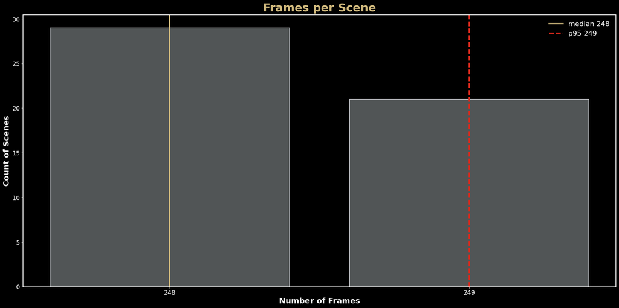

```
Figure saved to (Linux): /home/treinart/projects/lyft-unsupervised/artifacts/figures/20250917_200953_eda_frames_per_scene.png
Figure saved to (Win):   /mnt/c/Users/travi/Documents/Training/Colorado/MS-AI/CSCA 5632 Final Project/artifacts/figures/20250917_200953_eda_frames_per_scene.png
----------------------------------------------------------------------
Frames/Scene Stats: n=50 | median=248 | p95=249
----------------------------------------------------------------------
```

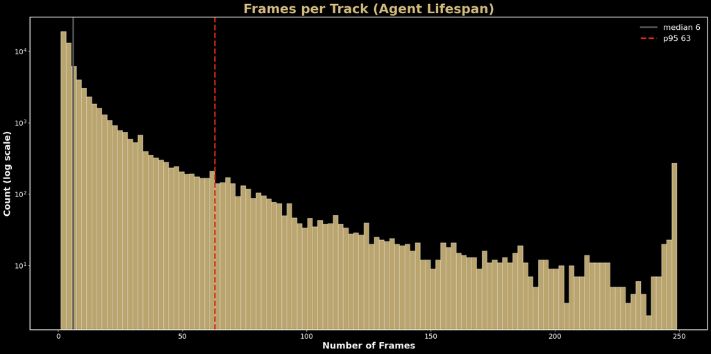

```
Figure saved to (Linux): /home/treinart/projects/lyft-unsupervised/artifacts/figures/20250917_200954_eda_frames_per_track.png
Figure saved to (Win):   /mnt/c/Users/travi/Documents/Training/Colorado/MS-AI/CSCA 5632 Final Project/artifacts/figures/20250917_200954_eda_frames_per_track.png
----------------------------------------------------------------------
Frames/Track Stats: n=64,625 | median=6 | p95=63
----------------------------------------------------------------------
```

```python
# Calculate Data for Frames per Scene
counts = frames_df_clean.groupby("scene_id")["frame_idx"].nunique().value_counts().sort_index()
frames_per_scene_data = frames_df_clean.groupby("scene_id")["frame_idx"].nunique().to_numpy()
median_val = np.median(frames_per_scene_data)
p95_val = np.percentile(frames_per_scene_data, 95)

# Create and Style the Plot
fig, ax = plt.subplots(figsize=(20, 10), facecolor="black")
ax.set_facecolor("black")
ax.bar(counts.index, counts.values, color="#565A5C", edgecolor="ghostwhite", linewidth=1.2, alpha=0.95)
ax.axvline(median_val, color="#CFB87C", lw=3, ls="-", label=f"median {median_val:.0f}")
ax.axvline(p95_val, color="#DA291C", lw=3, ls="--", label=f"p95 {p95_val:.0f}")
ax.set_title("Frames per Scene", fontsize=26, color="#CFB87C", fontweight="bold", pad=8)
ax.set_xlabel("Number of Frames", fontsize=18, color="#F8F8F8", fontweight="bold")
ax.set_ylabel("Count of Scenes", fontsize=18, color="#F8F8F8", fontweight="bold")
ax.tick_params(axis='x', colors='white', labelsize=14)
ax.tick_params(axis='y', colors='white', labelsize=14)
ax.set_xticks(counts.index)
for spine in ax.spines.values():
    spine.set_edgecolor("white")
    spine.set_linewidth(1.5)
ax.legend(frameon=False, fontsize=16, labelcolor="white", loc="upper right")

# Save Figure and Print Stats
save_fig(fig, "eda_frames_per_scene")
print("-" * 70)
print(f"Frames/Scene Stats: n={frames_per_scene_data.size:,} | median={median_val:.0f} | p95={p95_val:.0f}")
print("-" * 70)


# Calculate Data for Frames per Track
frames_per_track_data = agents_df_clean.groupby(["scene_id", "track_id"])["frame_idx"].nunique().to_numpy()
median_val = np.median(frames_per_track_data)
p95_val = np.percentile(frames_per_track_data, 95)

# Create and Style the Plot
fig, ax = plt.subplots(figsize=(20, 10), facecolor="black")
ax.set_facecolor("black")
ax.hist(frames_per_track_data, bins=120, color="#CFB87C", edgecolor="ghostwhite", linewidth=0.5, alpha=0.9)
ax.axvline(median_val, color="#565A5C", lw=3, ls="-", label=f"median {median_val:.0f}")
ax.axvline(p95_val, color="#DA291C", lw=3, ls="--", label=f"p95 {p95_val:.0f}")
ax.set_title("Frames per Track (Agent Lifespan)", fontsize=26, color="#CFB87C", fontweight="bold", pad=8)
ax.set_xlabel("Number of Frames", fontsize=18, color="#F8F8F8", fontweight="bold")
ax.set_ylabel("Count (log scale)", fontsize=18, color="#F8F8F8", fontweight="bold")
ax.tick_params(axis='x', colors='white', labelsize=14)
ax.tick_params(axis='y', colors='white', labelsize=14)
ax.set_yscale('log')
for spine in ax.spines.values():
    spine.set_edgecolor("white")
    spine.set_linewidth(1.5)
ax.legend(frameon=False, fontsize=16, labelcolor="white", loc="upper right")

# Save Figure and Print Stats
save_fig(fig, "eda_frames_per_track")
print("-" * 70)
print(f"Frames/Track Stats: n={frames_per_track_data.size:,} | median={median_val:.0f} | p95={p95_val:.0f}")
print("-" * 70)
```

### 4.2 Kinematic Distributions: Speed, Acceleration, and Yaw

This analysis moves beyond simple counts to examine the core kinematic properties of the agents. The distributions of speed (from $\sqrt{v_x^2 + v_y^2}$), acceleration (from finite differences of velocity), and yaw (heading) are fundamental to understanding agent behavior. The yaw distribution is particularly insightful, as its peaks can reveal the primary directions of travel dictated by the underlying road network.

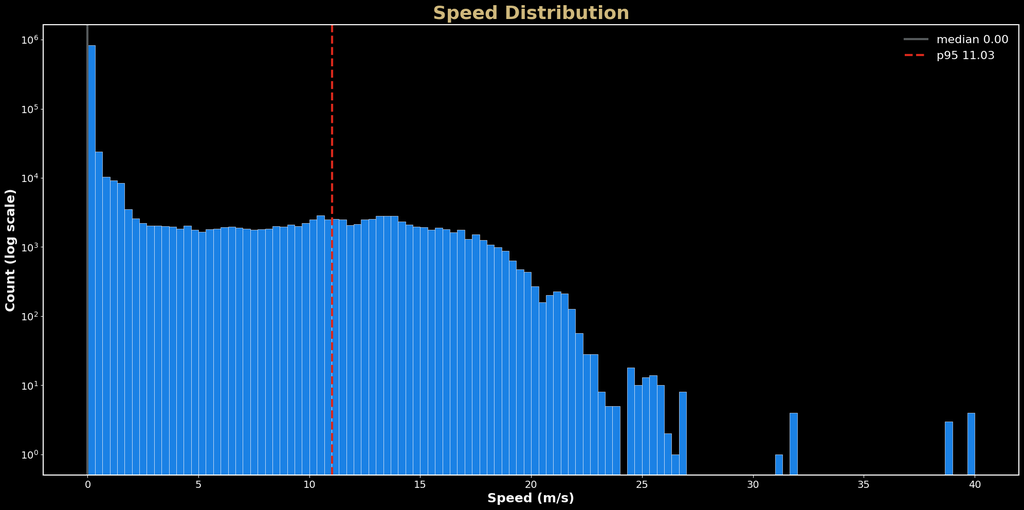

```
Figure saved to (Linux): /home/treinart/projects/lyft-unsupervised/artifacts/figures/20250917_201002_eda_kinematic_speed.png
Figure saved to (Win):   /mnt/c/Users/travi/Documents/Training/Colorado/MS-AI/CSCA 5632 Final Project/artifacts/figures/20250917_201002_eda_kinematic_speed.png
```

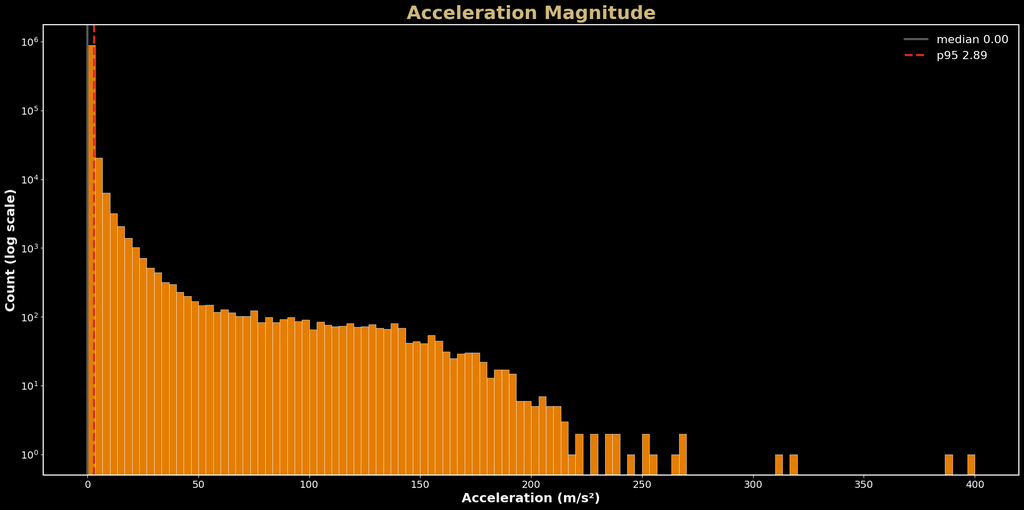

```
Figure saved to (Linux): /home/treinart/projects/lyft-unsupervised/artifacts/figures/20250917_201003_eda_kinematic_acceleration.png
Figure saved to (Win):   /mnt/c/Users/travi/Documents/Training/Colorado/MS-AI/CSCA 5632 Final Project/artifacts/figures/20250917_201003_eda_kinematic_acceleration.png
```

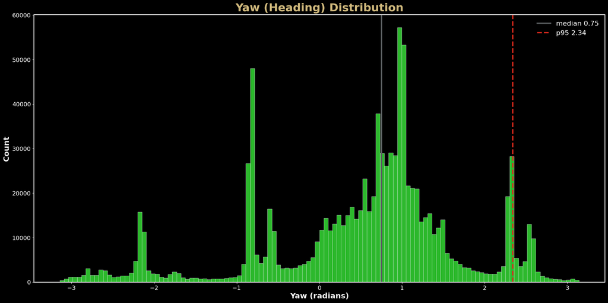

```
Figure saved to (Linux): /home/treinart/projects/lyft-unsupervised/artifacts/figures/20250917_201003_eda_kinematic_yaw.png
Figure saved to (Win):   /mnt/c/Users/travi/Documents/Training/Colorado/MS-AI/CSCA 5632 Final Project/artifacts/figures/20250917_201003_eda_kinematic_yaw.png

----------------------------------------------------------------------

Speed:        n=994,105 | median=0.00 | p95=11.03

Acceleration: n=929,480 | median=0.00 | p95=2.89

Yaw:          n=994,105 | median=0.75 | p95=2.34

----------------------------------------------------------------------
```

```python
# Calculate Kinematic Variables
vx = agents_df_clean["vx"].to_numpy()
vy = agents_df_clean["vy"].to_numpy()
speed_data = np.sqrt(vx**2 + vy**2)
DT_local = float(DT)
accel_arr = []
grouped = agents_df_clean.sort_values(["scene_id", "track_id", "frame_idx"]).groupby(["scene_id", "track_id"], sort=False)
for _, group in grouped:
    if len(group) < 2:
        continue
    vx_diff = np.diff(group["vx"].to_numpy())
    vy_diff = np.diff(group["vy"].to_numpy())
    accel_arr.append(np.sqrt(vx_diff**2 + vy_diff**2) / DT_local)
accel_data = np.concatenate(accel_arr) if accel_arr else np.array([])
yaw_data = agents_df_clean["yaw"].to_numpy()

# Plot Speed Distribution
median_val = np.median(speed_data)
p95_val = np.percentile(speed_data, 95)
fig, ax = plt.subplots(figsize=(20, 10), facecolor="black")
ax.set_facecolor("black")
ax.hist(speed_data, bins=120, color='dodgerblue', edgecolor="ghostwhite", linewidth=0.5, alpha=0.9)
ax.axvline(median_val, color="#565A5C", lw=3, ls="-", label=f"median {median_val:.2f}")
ax.axvline(p95_val, color="#DA291C", lw=3, ls="--", label=f"p95 {p95_val:.2f}")
ax.set_title("Speed Distribution", fontsize=26, color="#CFB87C", fontweight="bold", pad=8)
ax.set_xlabel("Speed (m/s)", fontsize=18, color="#F8F8F8", fontweight="bold")
ax.set_ylabel("Count (log scale)", fontsize=18, color="#F8F8F8", fontweight="bold")
ax.tick_params(axis='x', colors='white', labelsize=14)
ax.tick_params(axis='y', colors='white', labelsize=14)
ax.set_yscale('log')
for spine in ax.spines.values():
    spine.set_edgecolor("white")
    spine.set_linewidth(1.5)
ax.legend(frameon=False, fontsize=16, labelcolor="white", loc="upper right")
save_fig(fig, "eda_kinematic_speed")

# Plot Acceleration Distribution
median_val = np.median(accel_data)
p95_val = np.percentile(accel_data, 95)
fig, ax = plt.subplots(figsize=(20, 10), facecolor="black")
ax.set_facecolor("black")
ax.hist(accel_data, bins=120, color='darkorange', edgecolor="ghostwhite", linewidth=0.5, alpha=0.9)
ax.axvline(median_val, color="#565A5C", lw=3, ls="-", label=f"median {median_val:.2f}")
ax.axvline(p95_val, color="#DA291C", lw=3, ls="--", label=f"p95 {p95_val:.2f}")
ax.set_title("Acceleration Magnitude", fontsize=26, color="#CFB87C", fontweight="bold", pad=8)
ax.set_xlabel("Acceleration (m/s²)", fontsize=18, color="#F8F8F8", fontweight="bold")
ax.set_ylabel("Count (log scale)", fontsize=18, color="#F8F8F8", fontweight="bold")
ax.tick_params(axis='x', colors='white', labelsize=14)
ax.tick_params(axis='y', colors='white', labelsize=14)
ax.set_yscale('log')
for spine in ax.spines.values():
    spine.set_edgecolor("white")
    spine.set_linewidth(1.5)
ax.legend(frameon=False, fontsize=16, labelcolor="white", loc="upper right")
save_fig(fig, "eda_kinematic_acceleration")

# Plot Yaw Distribution
median_val = np.median(yaw_data)
p95_val = np.percentile(yaw_data, 95)
fig, ax = plt.subplots(figsize=(20, 10), facecolor="black")
ax.set_facecolor("black")
ax.hist(yaw_data, bins=120, color='limegreen', edgecolor="ghostwhite", linewidth=0.5, alpha=0.9)
ax.axvline(median_val, color="#565A5C", lw=3, ls="-", label=f"median {median_val:.2f}")
ax.axvline(p95_val, color="#DA291C", lw=3, ls="--", label=f"p95 {p95_val:.2f}")
ax.set_title("Yaw (Heading) Distribution", fontsize=26, color="#CFB87C", fontweight="bold", pad=8)
ax.set_xlabel("Yaw (radians)", fontsize=18, color="#F8F8F8", fontweight="bold")
ax.set_ylabel("Count", fontsize=18, color="#F8F8F8", fontweight="bold")
ax.tick_params(axis='x', colors='white', labelsize=14)
ax.tick_params(axis='y', colors='white', labelsize=14)
for spine in ax.spines.values():
    spine.set_edgecolor("white")
    spine.set_linewidth(1.5)
ax.legend(frameon=False, fontsize=16, labelcolor="white", loc="upper right")
save_fig(fig, "eda_kinematic_yaw")

# Print Summary Statistics
print("\n" + "-" * 70)
print(f"\nSpeed:        n={speed_data.size:,} | median={np.median(speed_data):.2f} | p95={np.percentile(speed_data, 95):.2f}")
print(f"\nAcceleration: n={accel_data.size:,} | median={np.median(accel_data):.2f} | p95={np.percentile(accel_data, 95):.2f}")
print(f"\nYaw:          n={yaw_data.size:,} | median={np.median(yaw_data):.2f} | p95={np.percentile(yaw_data, 95):.2f}")
print("\n" + "-" * 70)
```

### 4.3 Trajectory Snippets: A Qualitative Look

After analyzing the quantitative distributions, it's important to get a qualitative feel for the data. This section plots a random, reproducible sample of 12 agent trajectories that meet a minimum length requirement (`MIN_CONSEC`). Plotting these "snippets" helps to visually verify the data's integrity and reveals the diverse range of motion patterns present, from simple straight paths to complex turns and stationary behavior.

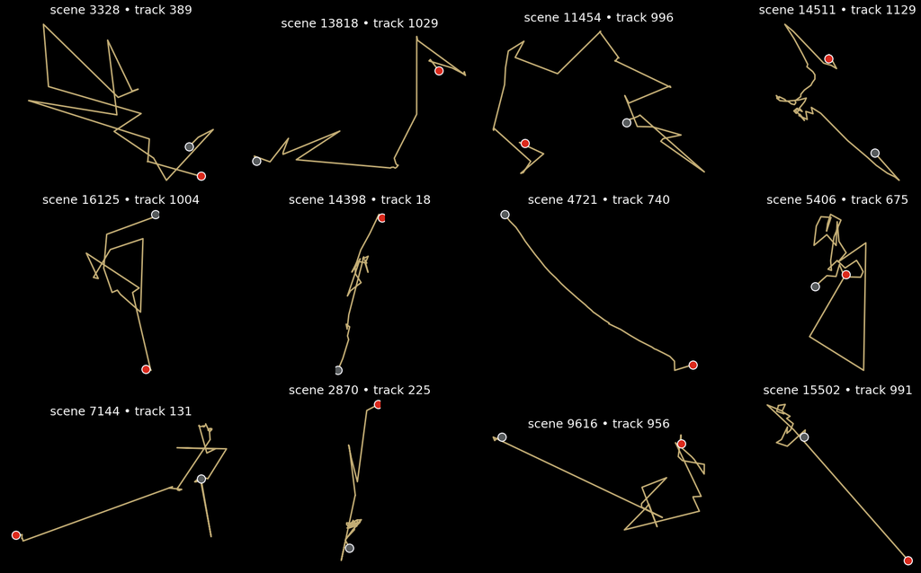

```
Figure saved to (Linux): /home/treinart/projects/lyft-unsupervised/artifacts/figures/20250917_201006_eda_trajectory_snippets.png
Figure saved to (Win):   /mnt/c/Users/travi/Documents/Training/Colorado/MS-AI/CSCA 5632 Final Project/artifacts/figures/20250917_201006_eda_trajectory_snippets.png
----------------------------------------------------------------------
Trajectory samples plotted: 12
----------------------------------------------------------------------
```

```python
# Filter for Eligible Tracks
eligible_tracks = agents_df_clean.groupby(["scene_id", "track_id"])["frame_idx"].nunique().reset_index(name="n_frames")
eligible_tracks = eligible_tracks[eligible_tracks["n_frames"] >= MIN_CONSEC]

# Create a Reproducible Random Sample
n_samples = min(12, len(eligible_tracks))
sampled_tracks = eligible_tracks.sample(n=n_samples, random_state=SEED)

# Create and Style the Plot Grid
fig, axes = plt.subplots(3, 4, figsize=(20, 12), facecolor="black")
fig.patch.set_facecolor("black")
axes = axes.flatten()
for ax in axes:
    ax.set_facecolor("black")
    ax.set_xticks([])
    ax.set_yticks([])
    for spine in ax.spines.values():
        spine.set_visible(False)

# Plot Each Sampled Trajectory
for ax, (_, track_info) in zip(axes, sampled_tracks.iterrows()):
    sid = int(track_info["scene_id"])
    tid = int(track_info["track_id"])

    # Select trajectory data
    trajectory = agents_df_clean[(agents_df_clean["scene_id"] == sid) & (agents_df_clean["track_id"] == tid)].sort_values("frame_idx")

    # Plot the path and start/end points
    ax.plot(trajectory["x"].to_numpy(), trajectory["y"].to_numpy(), lw=2.2, color="#CFB87C", alpha=0.95)
    ax.scatter(trajectory["x"].iloc[0], trajectory["y"].iloc[0], s=150, c="#DA291C", edgecolors="ghostwhite", linewidths=1.5, zorder=3)
    ax.scatter(trajectory["x"].iloc[-1], trajectory["y"].iloc[-1], s=150, c="#565A5C", edgecolors="ghostwhite", linewidths=1.5, zorder=3)
    ax.set_aspect("equal", adjustable="box")
    ax.set_title(f"scene {sid} • track {tid}", color="#F8F8F8", fontsize=18, pad=4)

# Save the Final Figure
save_fig(fig, "eda_trajectory_snippets")
print("-" * 70)
print(f"Trajectory samples plotted: {n_samples}")
print("-" * 70)
```

### 4.4 Spatial Density Heatmap

To understand the spatial context of the dataset, this plot shows a 2D histogram of all agent positions. The resulting heatmap reveals the "hotspots" of activity, effectively drawing an invisible map of the road network, intersections, and other high-traffic areas. A logarithmic color scale is used to prevent a few very high-density areas from dominating the visual and obscuring the details of less-traveled paths.

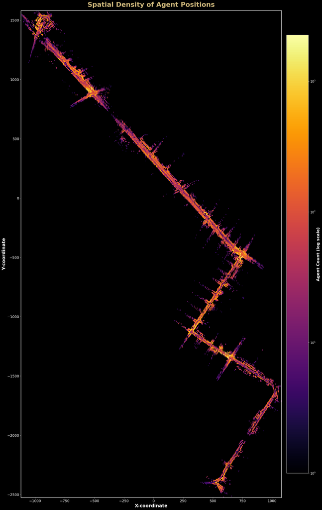

```
Figure saved to (Linux): /home/treinart/projects/lyft-unsupervised/artifacts/figures/20250917_201009_eda_spatial_heatmap.png
Figure saved to (Win):   /mnt/c/Users/travi/Documents/Training/Colorado/MS-AI/CSCA 5632 Final Project/artifacts/figures/20250917_201009_eda_spatial_heatmap.png
```

```python
# Create Figure and Axes
fig, ax = plt.subplots(figsize=(28, 28), facecolor="black")
ax.set_facecolor("black")

# Plot the 2D Histogram
h = ax.hist2d(
    agents_df_clean['x'],
    agents_df_clean['y'],
    bins=(500, 500),
    cmap='inferno',
    norm=LogNorm()
)

# Style the Plot
ax.set_title("Spatial Density of Agent Positions", fontsize=26, color="#CFB87C", fontweight="bold", pad=15)
ax.set_xlabel("X-coordinate", fontsize=18, color="#F8F8F8", fontweight="bold")
ax.set_ylabel("Y-coordinate", fontsize=18, color="#F8F8F8", fontweight="bold")
ax.tick_params(axis='x', colors='white', labelsize=14)
ax.tick_params(axis='y', colors='white', labelsize=14)
ax.set_aspect('equal')
for spine in ax.spines.values():
    spine.set_edgecolor("white")
    spine.set_linewidth(1.5)

# Style the Color Bar
cbar = fig.colorbar(h[3], ax=ax, pad=0.01, shrink=0.9)
cbar.set_label("Agent Count (log scale)", color="white", fontsize=16, fontweight="bold")
cbar.ax.tick_params(colors="white", labelsize=12)
cbar.outline.set_edgecolor("white")

# Save the Figure
save_fig(fig, "eda_spatial_heatmap")
```

### 4.5 Feature Engineering for Clustering

To prepare for dimensionality reduction and clustering, we first need to summarize the behavior of each agent's trajectory into a fixed-size numerical "feature vector." This process distills the raw time-series data of each track into a set of descriptive statistics that capture its key kinematic properties. Only tracks that meet the minimum length requirement (`MIN_CONSEC`) are included.

```python
# Define Helper Function
def _heading(vx, vy):
    return np.arctan2(vy, vx)

# Group Data by Individual Tracks
grouped_tracks = (agents_df_clean
                  .sort_values(["scene_id", "track_id", "frame_idx"])
                  .groupby(["scene_id", "track_id"], sort=False))

# Iterate and Compute Feature Vectors
track_features = []
with tqdm(total=len(grouped_tracks), desc="Engineering Features", unit="track") as pbar:
    for (sid, tid), group in grouped_tracks:
        # Ensure track is long enough
        if group["frame_idx"].nunique() < MIN_CONSEC:
            pbar.update(1)
            continue

        # Extract kinematic data
        vx = group["vx"].to_numpy(dtype=float)
        vy = group["vy"].to_numpy(dtype=float)
        speed = np.sqrt(vx**2 + vy**2)

        # Calculate heading change rate
        headings = _heading(vx, vy)
        unwrapped_headings = np.unwrap(headings)
        if unwrapped_headings.size >= 2:
            h_change_rate = np.nanmean(np.abs(np.diff(unwrapped_headings)) / DT)
        else:
            h_change_rate = 0.0

        # Calculate other summary features
        stop_ratio = float((speed < 0.5).mean())
        duration = float((group["frame_idx"].max() - group["frame_idx"].min() + 1) * DT)

        track_features.append({
            "scene_id": int(sid),
            "track_id": int(tid),
            "n_frames": int(group["frame_idx"].nunique()),
            "mean_speed": float(np.nanmean(speed)),
            "p95_speed": float(np.nanpercentile(speed, 95)),
            "std_speed": float(np.nanstd(speed)),
            "heading_change_rate": float(h_change_rate),
            "stop_ratio": stop_ratio,
            "duration_s": duration
        })
        pbar.update(1)

# Create Final Feature DataFrame
feat_df = pd.DataFrame(track_features)
print("-" * 70)
print(f"Total eligible tracks for feature extraction: {len(feat_df):,}")
print("-" * 70)

# Create Formatted Preview for Display
pretty_feat = feat_df.head().copy()
def format_or_dash(x, precision=3):
    if pd.isna(x) or (isinstance(x, (int, float)) and abs(x) < 1e-9):
        return "---"
    if isinstance(x, float):
        return f"{x:.{precision}f}"
    return x
for col in ["mean_speed", "p95_speed", "std_speed", "heading_change_rate", "stop_ratio", "duration_s"]:
    pretty_feat[col] = pretty_feat[col].apply(format_or_dash)
display(style_section_table(pretty_feat))
```

```
----------------------------------------------------------------------
Total eligible tracks for feature extraction: 11,956
----------------------------------------------------------------------
```

| scene_id | track_id | n_frames | mean_speed | p95_speed | std_speed | heading_change_rate | stop_ratio | duration_s |
| --- | --- | --- | --- | --- | --- | --- | --- | --- |
| 108 | 1 | 67 | 0.020 | --- | 0.105 | 1.339 | 0.985 | 6.700 |
| 108 | 2 | 248 | 0.002 | --- | 0.021 | 0.198 | 1.000 | 24.800 |
| 108 | 3 | 56 | 0.014 | --- | 0.075 | 0.685 | 1.000 | 5.600 |
| 108 | 4 | 87 | 0.012 | --- | 0.083 | 0.109 | 0.989 | 8.700 |
| 108 | 5 | 248 | 2.460 | 7.422 | 2.962 | 3.643 | 0.544 | 24.800 |

### 4.6 Feature Correlation Matrix

This heatmap shows the Pearson correlation between the engineered features. It's a crucial step to understand the relationships within the feature space before applying dimensionality reduction or clustering. Strong correlations (positive or negative) can indicate feature redundancy and help validate our understanding of how different agent behaviors are related.

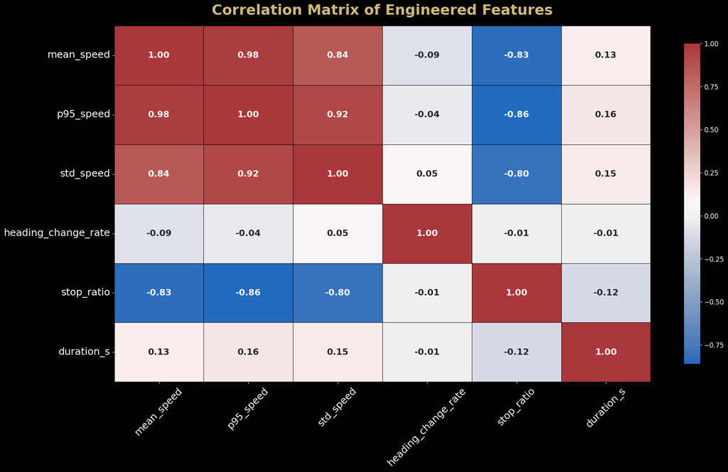

```
Figure saved to (Linux): /home/treinart/projects/lyft-unsupervised/artifacts/figures/20250917_201027_eda_feature_correlation_matrix.png
Figure saved to (Win):   /mnt/c/Users/travi/Documents/Training/Colorado/MS-AI/CSCA 5632 Final Project/artifacts/figures/20250917_201027_eda_feature_correlation_matrix.png
```

```python
# Define Feature Columns and Calculate Correlation
feature_cols = ["mean_speed", "p95_speed", "std_speed", "heading_change_rate", "stop_ratio", "duration_s"]
corr_matrix = feat_df[feature_cols].corr()

# Create the Figure and Axes
fig, ax = plt.subplots(figsize=(20, 12), facecolor="black")
ax.set_facecolor("black")

# Plot the Heatmap
sns.heatmap(
    corr_matrix,
    annot=True,
    fmt=".2f",
    cmap="vlag",
    linewidths=.5,
    linecolor='black',
    ax=ax,
    cbar_kws={"shrink": 0.9},
    annot_kws={'size': 16, 'weight': 'bold'},
)

# Style the Plot
ax.set_title("Correlation Matrix of Engineered Features", fontsize=26, color="#CFB87C", fontweight="bold", pad=20)
ax.tick_params(axis='x', colors='white', labelsize=18, rotation=45)
ax.tick_params(axis='y', colors='white', labelsize=18, rotation=0)

# Style the Color Bar
cbar = ax.collections[0].colorbar
cbar.ax.tick_params(colors='white', labelsize=12)
cbar.outline.set_edgecolor("white")

# Save the Figure
save_fig(fig, "eda_feature_correlation_matrix")
```

### 4.7 2D UMAP Behavior Map

With the high-dimensional feature vectors created, UMAP (Uniform Manifold Approximation and Projection) is used to project them down to a 2D "behavior map." On this map, trajectories with similar numerical features will appear close together, revealing the underlying structure of the data. Coloring the points by a key feature like mean speed helps to interpret the resulting clusters.

```
UMAP(min_dist=0.2, n_jobs=1, n_neighbors=75, random_state=42, verbose=True)
Wed Sep 17 20:10:30 2025 Construct fuzzy simplicial set
Wed Sep 17 20:10:30 2025 Finding Nearest Neighbors
Wed Sep 17 20:10:30 2025 Building RP forest with 10 trees
Wed Sep 17 20:10:34 2025 NN descent for 14 iterations
	 1  /  14
	 2  /  14
	Stopping threshold met -- exiting after 2 iterations
Wed Sep 17 20:10:40 2025 Finished Nearest Neighbor Search
Wed Sep 17 20:10:41 2025 Construct embedding
```

```
Epochs completed:   0%|            0/200 [00:00]
```

```
	completed  0  /  200 epochs
	completed  20  /  200 epochs
	completed  40  /  200 epochs
	completed  60  /  200 epochs
	completed  80  /  200 epochs
	completed  100  /  200 epochs
	completed  120  /  200 epochs
	completed  140  /  200 epochs
	completed  160  /  200 epochs
	completed  180  /  200 epochs
Wed Sep 17 20:11:05 2025 Finished embedding
```

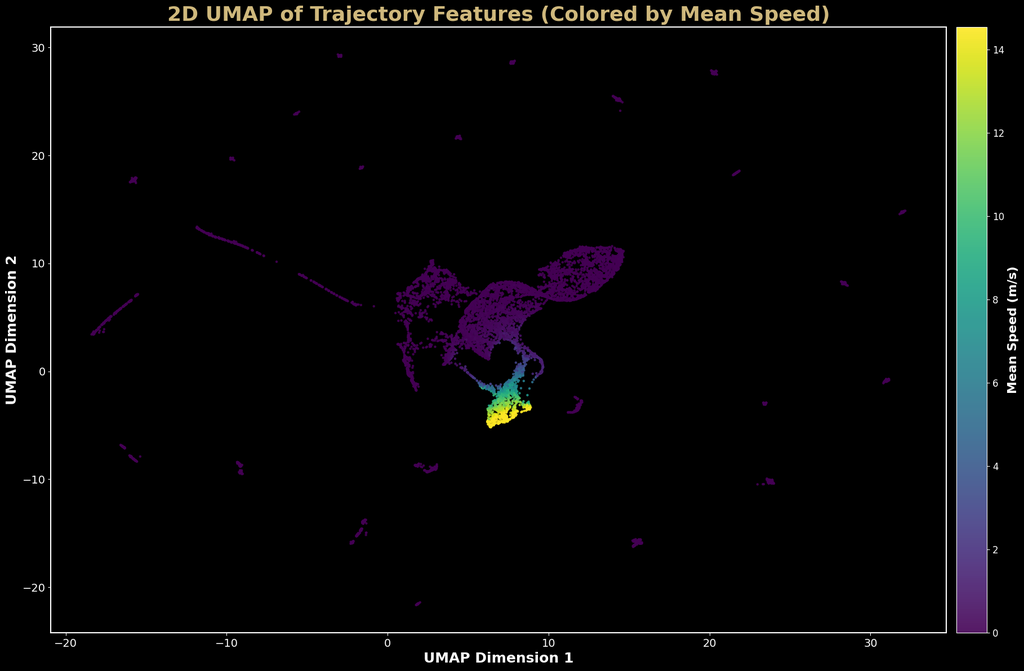

```
Figure saved to (Linux): /home/treinart/projects/lyft-unsupervised/artifacts/figures/20250917_201105_eda_umap_2d_behavior_map.png
Figure saved to (Win):   /mnt/c/Users/travi/Documents/Training/Colorado/MS-AI/CSCA 5632 Final Project/artifacts/figures/20250917_201105_eda_umap_2d_behavior_map.png

--- Feature Correlation with 2D UMAP Dimensions ---
```

| feature | corr_umap1 | corr_umap2 |
| --- | --- | --- |
| mean_speed | 0.056000 | -0.252000 |
| p95_speed | 0.063000 | -0.260000 |
| std_speed | 0.063000 | -0.243000 |
| heading_change_rate | 0.072000 | -0.042000 |
| stop_ratio | -0.082000 | 0.263000 |
| duration_s | -0.220000 | -0.228000 |

```python
# Prepare Features for UMAP
feature_cols = ["mean_speed", "p95_speed", "std_speed", "heading_change_rate", "stop_ratio", "duration_s"]
feat_df_nna = feat_df.dropna(subset=feature_cols).reset_index(drop=True)
X = feat_df_nna[feature_cols].to_numpy(dtype=float)
X_scaled = StandardScaler().fit_transform(X)

# Run 2D UMAP
reducer_2d = umap.UMAP(
    n_neighbors=75,
    min_dist=0.2,
    metric="euclidean",
    random_state=SEED,
    n_components=2,
    verbose=True
)
Z_2d = reducer_2d.fit_transform(X_scaled)

# Plot the 2D Behavior Map
mean_speed_colors = feat_df_nna["mean_speed"].to_numpy()
vmin, vmax = np.nanpercentile(mean_speed_colors, 2), np.nanpercentile(mean_speed_colors, 98)
fig, ax = plt.subplots(figsize=(20, 12), facecolor="black")
ax.set_facecolor("black")
sc = ax.scatter(
    Z_2d[:, 0], Z_2d[:, 1],
    c=mean_speed_colors, s=10, cmap="viridis", vmin=vmin, vmax=vmax,
    alpha=0.9, edgecolors="none"
)
ax.set_title("2D UMAP of Trajectory Features (Colored by Mean Speed)", fontsize=26, color="#CFB87C", fontweight="bold", pad=8)
ax.set_xlabel("UMAP Dimension 1", fontsize=18, color="white", fontweight="bold")
ax.set_ylabel("UMAP Dimension 2", fontsize=18, color="white", fontweight="bold")
ax.tick_params(colors="white", labelsize=14)
for spine in ax.spines.values():
    spine.set_edgecolor("white")
    spine.set_linewidth(1.5)
cb = plt.colorbar(sc, ax=ax, pad=0.01)
cb.set_label("Mean Speed (m/s)", color="white", fontsize=16, fontweight="bold")
cb.ax.tick_params(colors="white", labelsize=12)
cb.outline.set_edgecolor("white")
save_fig(fig, "eda_umap_2d_behavior_map")

# Analyze Feature Correlations with UMAP Dimensions
def _corr(a, b):
    return float(np.corrcoef(a, b)[0, 1])
U_2d = pd.DataFrame(Z_2d, columns=["umap1", "umap2"])
F_2d = feat_df_nna[feature_cols]
corr_rows = []
for col in F_2d.columns:
    corr_rows.append({
        "feature": col,
        "corr_umap1": _corr(U_2d["umap1"], F_2d[col]),
        "corr_umap2": _corr(U_2d["umap2"], F_2d[col]),
    })
corr2d_df = pd.DataFrame(corr_rows)
print("\n--- Feature Correlation with 2D UMAP Dimensions ---")
display(style_section_table(corr2d_df.round(3)))
```

### 4.8 3D UMAP Behavior Map

As an alternative visualization, the same high-dimensional feature vectors are projected into a 3D space. This can sometimes reveal additional structure or separation between behavioral patterns that may be less obvious in the 2D projection. The same color mapping by mean speed is used to aid interpretation.

```
UMAP(min_dist=0.2, n_components=3, n_jobs=1, n_neighbors=75, random_state=42, verbose=True)
Wed Sep 17 20:15:30 2025 Construct fuzzy simplicial set
Wed Sep 17 20:15:30 2025 Finding Nearest Neighbors
Wed Sep 17 20:15:30 2025 Building RP forest with 10 trees
Wed Sep 17 20:15:30 2025 NN descent for 14 iterations
	 1  /  14
	 2  /  14
	Stopping threshold met -- exiting after 2 iterations
Wed Sep 17 20:15:32 2025 Finished Nearest Neighbor Search
Wed Sep 17 20:15:33 2025 Construct embedding
```

```
Epochs completed:   0%|            0/200 [00:00]
```

```
	completed  0  /  200 epochs
	completed  20  /  200 epochs
	completed  40  /  200 epochs
	completed  60  /  200 epochs
	completed  80  /  200 epochs
	completed  100  /  200 epochs
	completed  120  /  200 epochs
	completed  140  /  200 epochs
	completed  160  /  200 epochs
	completed  180  /  200 epochs
Wed Sep 17 20:15:56 2025 Finished embedding
```

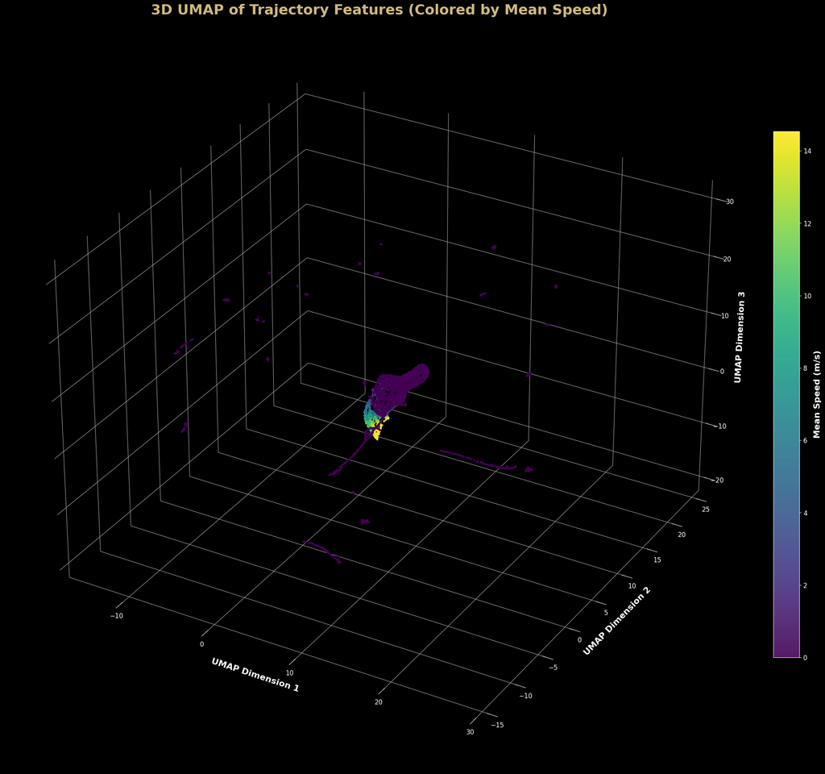

```
Figure saved to (Linux): /home/treinart/projects/lyft-unsupervised/artifacts/figures/20250917_201556_eda_umap_3d_behavior_map.png
Figure saved to (Win):   /mnt/c/Users/travi/Documents/Training/Colorado/MS-AI/CSCA 5632 Final Project/artifacts/figures/20250917_201556_eda_umap_3d_behavior_map.png

--- Feature Correlation with 3D UMAP Dimensions ---
```

| feature | corr_umap1 | corr_umap2 | corr_umap3 |
| --- | --- | --- | --- |
| mean_speed | -0.069000 | 0.026000 | -0.203000 |
| p95_speed | -0.067000 | 0.036000 | -0.204000 |
| std_speed | -0.055000 | 0.040000 | -0.186000 |
| heading_change_rate | 0.078000 | 0.194000 | 0.021000 |
| stop_ratio | 0.090000 | -0.058000 | 0.198000 |
| duration_s | -0.025000 | -0.087000 | -0.372000 |

```python
# Run 3D UMAP
reducer_3d = umap.UMAP(
    n_neighbors=75,
    min_dist=0.2,
    metric="euclidean",
    random_state=SEED,
    n_components=3,
    verbose=True
)
Z_3d = reducer_3d.fit_transform(X_scaled)

# Plot the 3D Behavior Map
mean_speed_colors = feat_df_nna["mean_speed"].to_numpy()
vmin, vmax = np.nanpercentile(mean_speed_colors, 2), np.nanpercentile(mean_speed_colors, 98)
fig = plt.figure(figsize=(24, 20), facecolor="black")
ax = fig.add_subplot(111, projection="3d")
ax.set_facecolor("black")
sc = ax.scatter(
    Z_3d[:, 0], Z_3d[:, 1], Z_3d[:, 2],
    c=mean_speed_colors, s=10, cmap="viridis", vmin=vmin, vmax=vmax,
    alpha=0.9, edgecolors="none"
)

# Style the 3D Plot
ax.set_title("3D UMAP of Trajectory Features (Colored by Mean Speed)", fontsize=26, color="#CFB87C", fontweight="bold", pad=8)
ax.set_xlabel("UMAP Dimension 1", fontsize=16, color="white", fontweight="bold", labelpad=10)
ax.set_ylabel("UMAP Dimension 2", fontsize=16, color="white", fontweight="bold", labelpad=10)
ax.set_zlabel("UMAP Dimension 3", fontsize=16, color="white", fontweight="bold", labelpad=10)
ax.xaxis.set_pane_color((0, 0, 0, 1))
ax.yaxis.set_pane_color((0, 0, 0, 1))
ax.zaxis.set_pane_color((0, 0, 0, 1))
ax.tick_params(axis='x', colors='white', labelsize=12)
ax.tick_params(axis='y', colors='white', labelsize=12)
ax.tick_params(axis='z', colors='white', labelsize=12)
cb = fig.colorbar(sc, ax=ax, pad=0.02, shrink=0.7)
cb.set_label("Mean Speed (m/s)", color="white", fontsize=16, fontweight="bold")
cb.ax.tick_params(colors="white", labelsize=12)
cb.outline.set_edgecolor("white")
save_fig(fig, "eda_umap_3d_behavior_map")

# Analyze Feature Correlations with 3D UMAP Dimensions
U_3d = pd.DataFrame(Z_3d, columns=["umap1", "umap2", "umap3"])
F_3d = feat_df_nna[feature_cols]
corr_rows_3d = []
for col in F_3d.columns:
    corr_rows_3d.append({
        "feature": col,
        "corr_umap1": _corr(U_3d["umap1"], F_3d[col]),
        "corr_umap2": _corr(U_3d["umap2"], F_3d[col]),
        "corr_umap3": _corr(U_3d["umap3"], F_3d[col]),
    })
corr3d_df = pd.DataFrame(corr_rows_3d)
print("\n--- Feature Correlation with 3D UMAP Dimensions ---")
display(style_section_table(corr3d_df.round(3)))
```

### 4.9 EDA Quantitative Summary

To conclude the exploratory analysis, this section compiles the key descriptive statistics from the previous visualizations into a single summary table. This provides a clear, quantitative reference for the distributions of speed, acceleration, and track/scene lengths, which can be used for sanity checks in later stages of the project.

```python
# Define Helper Function
def q(a, p):
    a = a[np.isfinite(a)]
    return float(np.percentile(a, p)) if a.size else np.nan

# Calculate Summary Statistics
summary_df = pd.DataFrame({
    "measure": [
        "speed_mean", "speed_median", "speed_p95",
        "accel_mean", "accel_median", "accel_p95",
        "frames_per_scene_median", "frames_per_scene_p95",
        "frames_per_track_median", "frames_per_track_p95",
    ],
    "estimate": [
        float(np.nanmean(speed_data)),
        float(np.nanmedian(speed_data)),
        q(speed_data, 95),
        float(np.nanmean(accel_data)),
        float(np.nanmedian(accel_data)),
        q(accel_data, 95),
        float(np.median(frames_per_scene_data)),
        q(frames_per_scene_data, 95),
        float(np.median(frames_per_track_data)),
        q(frames_per_track_data, 95)
    ]
})

# Display and Cache the Summary Table
display(style_section_table(summary_df).format({"estimate": "{:.3f}"}))
print("-" * 70)
print("\n--- Caching EDA summary table ---\n")
saved_paths = _save_df(summary_df, "eda_summary_section4")
for path_type, path_loc in saved_paths.items():
    print(f"Saved to ({path_type.replace('_', ' ')}): {path_loc}")
print("\n" + "-" * 70)
```

| measure | estimate |
| --- | --- |
| speed_mean | 1.167 |
| speed_median | 0.000 |
| speed_p95 | 11.027 |
| accel_mean | 0.916 |
| accel_median | 0.000 |
| accel_p95 | 2.891 |
| frames_per_scene_median | 248.000 |
| frames_per_scene_p95 | 249.000 |
| frames_per_track_median | 6.000 |
| frames_per_track_p95 | 63.000 |

```
----------------------------------------------------------------------

--- Caching EDA summary table ---

Saved to (parquet linux): /home/treinart/projects/lyft-unsupervised/artifacts/cache/20250917_201731_eda_summary_section4.parquet
Saved to (parquet windows): /mnt/c/Users/travi/Documents/Training/Colorado/MS-AI/CSCA 5632 Final Project/artifacts/cache/20250917_201731_eda_summary_section4.parquet
Saved to (csv linux): /home/treinart/projects/lyft-unsupervised/artifacts/cache/20250917_201731_eda_summary_section4.csv
Saved to (csv windows): /mnt/c/Users/travi/Documents/Training/Colorado/MS-AI/CSCA 5632 Final Project/artifacts/cache/20250917_201731_eda_summary_section4.csv

----------------------------------------------------------------------
```

### **Observation: Key Findings from Exploratory Data Analysis**

The exploratory data analysis (EDA) successfully illuminated the core characteristics of the agent trajectory data. The findings reveal a dataset that is structurally consistent, spatially organized, and contains a diverse but separable set of behaviors. This analysis culminates in the creation of UMAP "behavior maps," which visually confirm that distinct patterns of motion are identifiable and provide a strong foundation for the formal clustering tasks.

- **Structural Consistency:**
  - The analysis of scene and track lengths revealed two key properties. First, the scenes are remarkably consistent in duration, with almost all lasting **~25 seconds (248-249 frames)**. Second, while most individual agent tracks are short (a median of **6 frames**), a significant long tail exists, with 5% of tracks lasting longer than 63 frames.
  - The **Spatial Density Heatmap** clearly reveals a structured, non-random road network. The **Yaw Distribution** corroborates this by showing agent travel is heavily concentrated along specific cardinal directions, which is characteristic of an urban grid.
- **Dominance of Stationary Behavior (Key Finding):**
  - A primary characteristic of the dataset is the overwhelming prevalence of stationary behavior. The **Speed and Acceleration distributions** both report a median value of **0.00 m/s**. This is a significant finding, confirming that more than half of the nearly one million agent-moments captured in the subset are spent at a complete standstill, likely due to traffic signals and congestion.
- **Successful Feature Engineering:**
  - The feature engineering process methodically distilled the complex, variable-length trajectories of **11,956** eligible agents (those with at least 20 consecutive frames) into a fixed-size, interpretable feature vector for each.
  - The **Feature Correlation Matrix** validates these features, showing logical relationships while also confirming that metrics like `heading_change_rate` capture relatively independent aspects of motion.
- **Clear Behavioral Separation in UMAP:**
  - The UMAP projections are the most critical finding of this EDA. They successfully transform the engineered features into low-dimensional "behavior maps" where clear, non-random structures emerge.
  - The maps show a large, dense core corresponding to the low-speed and stationary agents. Extending from this core are distinct arms and peninsulas representing more dynamic behaviors. This visual separation is powerful evidence that different behavioral archetypes exist and are separable.

**Conclusion:**

The exploratory analysis has achieved its goal. It has progressed from raw data distributions to a low-dimensional embedding where distinct patterns of agent behavior are visually apparent. The clear separation of behaviors in the UMAP maps provides strong evidence that formal clustering algorithms can successfully partition this data. The project can now proceed with confidence to the modeling phase.

## Section 5: Pipeline A - Classical Feature Engineering

This section details the first of two parallel pipelines for discovering behavioral patterns. "Pipeline A" uses a classical, interpretable approach. A comprehensive set of features is engineered from the raw trajectory data to numerically summarize each agent's behavior. These features, covering kinematics, path geometry, and stopping behavior, are designed to be transparent and human-understandable. The final output is a standardized feature matrix ready for clustering.

### Section Plan:

**Checkpoint & Loader:** Option to skip computation and load the latest cached artifacts.

**Feature Design:** Define the catalog of features to be engineered and verify the input data is ready.

**Build Feature Table:** Create a single, powerful function to compute the feature vectors for all eligible tracks.

**Preprocess Features:** Mitigate outliers by capping extreme values and standardize the data for clustering.

**Sanity Check:** Review a quantitative summary of the final feature table.

**Sensitivity Analysis:** Visualize how the choice of the `MIN_CONSEC` hyperparameter impacts the feature distributions to justify the final selection.

**Final Feature Distributions:** Plot a panel of histograms to visualize the final, capped feature distributions.

### 5.1 Checkpoint: Run Full Section or Load from Cache

This cell acts as a checkpoint. The feature engineering process can be time-consuming. Set the flag below to control the behavior of this section.

**`True`:** Run the full feature engineering and preprocessing pipeline. This is required on the first run.

**`False`:** Skip the long computations and load the most recent cached artifacts from a previous run.

```python
# Set to True to run the time-consuming feature engineering process.
# Set to False to skip computation and load the latest cached results from a previous run.
RUN_FEATURE_ENGINEERING = True

if not RUN_FEATURE_ENGINEERING:
    print("--- Skipping feature engineering. Loading latest artifacts from cache... ---")
    try:
        # Load the capped feature DataFrame
        latest_df_file = max(CACHE_DIR.glob("*_feat_df_capped_pipeline_a.parquet"), key=os.path.getctime)
        feat_df_capped = pd.read_parquet(latest_df_file)
        print(f"Loaded DataFrame from: {latest_df_file.name}")

        # Load the scaled data matrix
        latest_npy_file = max(CACHE_DIR.glob("*_X_scaled_pipeline_a.npy"), key=os.path.getctime)
        X_scaled = np.load(latest_npy_file)
        print(f"Loaded scaled matrix from: {latest_npy_file.name}")

        # Load the scaler parameters
        latest_scaler_file = max(CACHE_DIR.glob("*_scaler_pipeline_a.json"), key=os.path.getctime)
        with open(latest_scaler_file, 'r') as f:
            scaler_params = json.load(f)
        print(f"Loaded scaler params from: {latest_scaler_file.name}")

        print(f"\n--- Successfully loaded {len(feat_df_capped):,} tracks. Ready to proceed to Section 6 ---")
    except ValueError:
        print("\n--- ERROR: No cached artifacts found. Please set RUN_FEATURE_ENGINEERING to True and run the full section ---")
        RUN_FEATURE_ENGINEERING = True
else:
    print("--- RUN_FEATURE_ENGINEERING is True. Proceeding with full computation. ---")
```

```
--- RUN_FEATURE_ENGINEERING is True. Proceeding with full computation. ---
```

### 5.2 Feature Design & Readiness Check

This initial step defines the feature catalog: the full set of interpretable metrics that will be calculated for each trajectory. It also performs a readiness check to verify that all necessary data from Section 3 is present and to quantify how many agent tracks are eligible for feature engineering based on the `MIN_CONSEC` parameter.

```python
# This cell will only run if the full computation is enabled.
if RUN_FEATURE_ENGINEERING:
    # Verify Input Data
    required_vars = ['agents_df_clean', 'frames_df_clean', 'MIN_CONSEC', 'DT']
    missing_vars = [var for var in required_vars if var not in globals()]
    if missing_vars:
        raise NameError(f"Missing required data from previous sections: {', '.join(missing_vars)}")

    # Report on Eligibility
    total_tracks = agents_df_clean.groupby(["scene_id", "track_id"]).ngroups
    eligible_tracks_count = (agents_df_clean.groupby(["scene_id", "track_id"])["frame_idx"]
                             .nunique() >= MIN_CONSEC).sum()
    coverage_rate = eligible_tracks_count / total_tracks if total_tracks > 0 else 0.0

    print("-" * 70)
    print("Feature Engineering Readiness Check")
    print("-" * 70)
    print(f"Key Parameters: MIN_CONSEC={MIN_CONSEC} frames | DT={DT} seconds")
    print(f"Track Eligibility: {eligible_tracks_count:,} of {total_tracks:,} tracks are eligible ({coverage_rate:.1%})")

    # Define the Feature Catalog
    feature_catalog = pd.DataFrame([
        {"feature": "n_frames", "purpose": "coverage", "definition": "Count of unique frames in the track."},
        {"feature": "duration_s", "purpose": "coverage", "definition": "Total time duration of the track in seconds."},
        {"feature": "mean_speed", "purpose": "pace", "definition": "Mean of the agent's speed across all frames."},
        {"feature": "p95_speed", "purpose": "pace", "definition": "95th percentile of speed, indicating peak pace."},
        {"feature": "max_speed", "purpose": "pace", "definition": "Absolute maximum speed achieved."},
        {"feature": "median_accel", "purpose": "smoothness", "definition": "Median acceleration, indicating typical change in speed."},
        {"feature": "p95_accel", "purpose": "smoothness", "definition": "95th percentile of acceleration."},
        {"feature": "max_accel", "purpose": "smoothness", "definition": "Absolute maximum acceleration."},
        {"feature": "p95_jerk", "purpose": "comfort", "definition": "95th percentile of jerk (change in acceleration)."},
        {"feature": "heading_change_rate", "purpose": "turning", "definition": "Mean rate of change in heading (angular velocity)."},
        {"feature": "turn_magnitude", "purpose": "turning", "definition": "Sum of absolute changes in heading over the track."},
        {"feature": "stop_ratio", "purpose": "idling", "definition": "Fraction of frames where speed is below 0.5 m/s."},
        {"feature": "stationary_bursts", "purpose": "idling", "definition": "Count of transitions from moving to stopped."},
        {"feature": "straightness", "purpose": "path shape", "definition": "Ratio of displacement to total path length (1.0 is a straight line)."},
        {"feature": "path_length", "purpose": "distance", "definition": "Total distance traveled along the trajectory path."},
        {"feature": "displacement", "purpose": "distance", "definition": "Net distance between the start and end points."},
    ])

    print("\n--- Feature Catalog ---")
    display(style_section_table(feature_catalog))
else:
    print("--- Skipped: Loading from cache ---")
```

```
----------------------------------------------------------------------
Feature Engineering Readiness Check
----------------------------------------------------------------------
Key Parameters: MIN_CONSEC=20 frames | DT=0.1 seconds
Track Eligibility: 11,956 of 64,625 tracks are eligible (18.5%)

--- Feature Catalog ---
```

| feature | purpose | definition |
| --- | --- | --- |
| n_frames | coverage | Count of unique frames in the track. |
| duration_s | coverage | Total time duration of the track in seconds. |
| mean_speed | pace | Mean of the agent's speed across all frames. |
| p95_speed | pace | 95th percentile of speed, indicating peak pace. |
| max_speed | pace | Absolute maximum speed achieved. |
| median_accel | smoothness | Median acceleration, indicating typical change in speed. |
| p95_accel | smoothness | 95th percentile of acceleration. |
| max_accel | smoothness | Absolute maximum acceleration. |
| p95_jerk | comfort | 95th percentile of jerk (change in acceleration). |
| heading_change_rate | turning | Mean rate of change in heading (angular velocity). |
| turn_magnitude | turning | Sum of absolute changes in heading over the track. |
| stop_ratio | idling | Fraction of frames where speed is below 0.5 m/s. |
| stationary_bursts | idling | Count of transitions from moving to stopped. |
| straightness | path shape | Ratio of displacement to total path length (1.0 is a straight line). |
| path_length | distance | Total distance traveled along the trajectory path. |
| displacement | distance | Net distance between the start and end points. |

### 5.3 Build Feature Table

This cell defines and runs the primary feature engineering function, `build_feature_table`. This single, unified function iterates through every agent track in the dataset, calculates the full suite of features defined in the catalog, and returns a complete DataFrame. Consolidating the logic here allows it to be reused for the sensitivity analysis later.

```python
# This cell will only run if the full computation is enabled.
if RUN_FEATURE_ENGINEERING:
    # Define the primary feature engineering function
    def build_feature_table(agents_df: pd.DataFrame, min_consec: int, dt: float) -> pd.DataFrame:
        grouped_tracks = (agents_df
                          .sort_values(["scene_id", "track_id", "frame_idx"])
                          .groupby(["scene_id", "track_id"], sort=False))

        track_features = []
        for (sid, tid), group in tqdm(grouped_tracks, total=grouped_tracks.ngroups, desc=f"Building Features (MIN_CONSEC={min_consec})", unit="track"):
            n_frames = group["frame_idx"].nunique()
            if n_frames < min_consec:
                continue

            # Extract base arrays
            x, y = group["x"].to_numpy(), group["y"].to_numpy()
            vx, vy = group["vx"].to_numpy(), group["vy"].to_numpy()
            fi = group["frame_idx"].to_numpy()

            # Calculate Kinematics
            s = np.sqrt(vx**2 + vy**2)
            a = np.sqrt(np.diff(vx)**2 + np.diff(vy)**2) / dt if len(vx) >= 2 else np.array([])
            j = np.abs(np.diff(a)) / dt if len(a) >= 2 else np.array([])

            # Calculate Heading and Turning
            h = np.unwrap(np.arctan2(vy, vx))
            h_rate = np.nanmean(np.abs(np.diff(h)) / dt) if len(h) >= 2 else 0.0
            turn_mag = np.nansum(np.abs(np.diff(h))) if len(h) >= 2 else 0.0

            # Calculate Stop Metrics
            stop_mask = s < 0.5
            stop_ratio = stop_mask.mean()
            bursts = np.sum((~stop_mask[:-1]) & stop_mask[1:]) if len(stop_mask) >= 2 else 0

            # Calculate Path Geometry
            path_len = np.sum(np.sqrt(np.diff(x)**2 + np.diff(y)**2)) if len(x) >= 2 else 0.0
            disp = np.sqrt((x[-1] - x[0])**2 + (y[-1] - y[0])**2) if len(x) >= 1 else 0.0
            straight = disp / path_len if path_len > 1e-3 else 1.0

            # Append all features
            track_features.append({
                "scene_id": sid, "track_id": tid, "n_frames": n_frames,
                "duration_s": (fi.max() - fi.min() + 1) * dt,
                "mean_speed": np.nanmean(s), "median_speed": np.nanmedian(s), "std_speed":  np.nanstd(s),
                "p95_speed": np.percentile(s, 95), "max_speed": s.max(),
                "median_accel": np.nanmedian(a), "p95_accel": np.percentile(a, 95) if a.size > 0 else 0.0,
                "max_accel": a.max() if a.size > 0 else 0.0,
                "p95_jerk": np.percentile(j, 95) if j.size > 0 else 0.0,
                "heading_change_rate": h_rate, "turn_magnitude": turn_mag,
                "stop_ratio": stop_ratio, "stationary_bursts": bursts,
                "straightness": straight, "path_length": path_len, "displacement": disp,
            })
        return pd.DataFrame(track_features)

    # Run the feature engineering process
    MIN_CONSEC_FINAL = 30 # Value justified by sensitivity analysis in a later step
    print("--- Building Main Feature Table ---")
    feat_df = build_feature_table(agents_df_clean, min_consec=MIN_CONSEC_FINAL, dt=DT)
    print("\n" + "-" * 70)
    print(f"Feature engineering complete. Total tracks kept: {len(feat_df):,}")
    print("-" * 70)

    # Create and display a formatted preview
    pretty_feat = feat_df.head().copy()
    def format_or_dash(x, precision=3):
        if pd.isna(x) or (isinstance(x, (int, float)) and abs(x) < 1e-9): return "---"
        if isinstance(x, float): return f"{x:.{precision}f}"
        return x
    cols_to_format = [c for c in pretty_feat.columns if c not in ['scene_id', 'track_id', 'n_frames', 'stationary_bursts']]
    for col in cols_to_format:
        pretty_feat[col] = pretty_feat[col].apply(lambda v: format_or_dash(v))
    display(style_section_table(pretty_feat))
else:
    print("--- Skipped: Loading from cache ---")
```

```
--- Building Main Feature Table ---
```

```
----------------------------------------------------------------------
Feature engineering complete. Total tracks kept: 7,824
----------------------------------------------------------------------
```

| scene_id | track_id | n_frames | duration_s | mean_speed | median_speed | std_speed | p95_speed | max_speed | median_accel | p95_accel | max_accel | p95_jerk | heading_change_rate | turn_magnitude | stop_ratio | stationary_bursts | straightness | path_length | displacement |
| --- | --- | --- | --- | --- | --- | --- | --- | --- | --- | --- | --- | --- | --- | --- | --- | --- | --- | --- | --- |
| 108 | 1 | 67 | 6.700 | 0.020 | --- | 0.105 | --- | 0.741 | --- | 1.180 | 8.967 | 14.833 | 1.339 | 8.835 | 0.985 | 1 | 0.216 | 5.146 | 1.111 |
| 108 | 2 | 248 | 24.800 | 0.002 | --- | 0.021 | --- | 0.290 | --- | --- | 2.905 | --- | 0.198 | 4.891 | 1.000 | 0 | 0.015 | 35.584 | 0.543 |
| 108 | 3 | 56 | 5.600 | 0.014 | --- | 0.075 | --- | 0.471 | --- | 0.976 | 5.688 | 14.898 | 0.685 | 3.769 | 1.000 | 0 | 0.216 | 4.824 | 1.044 |
| 108 | 4 | 87 | 8.700 | 0.012 | --- | 0.083 | --- | 0.653 | --- | --- | 6.526 | --- | 0.109 | 0.941 | 0.989 | 1 | 0.244 | 6.205 | 1.514 |
| 108 | 5 | 248 | 24.800 | 2.460 | 0.050 | 2.962 | 7.422 | 7.618 | 0.191 | 2.005 | 62.829 | 5.809 | 3.643 | 89.977 | 0.544 | 1 | 0.937 | 63.309 | 59.349 |

### 5.4 Preprocess Features: Cap and Standardize

Before using the features for clustering, two standard preprocessing steps are applied. First, each feature is "capped" at its 99th percentile to mitigate the influence of extreme outliers without removing data. Second, the features are standardized (scaled to have zero mean and unit variance) to ensure that all features contribute equally to the distance calculations in the clustering algorithms.

```python
# This cell will only run if the full computation is enabled.
if RUN_FEATURE_ENGINEERING:
    # Cap Features at the 99th Percentile
    id_cols = ["scene_id", "track_id"]
    numeric_cols = [c for c in feat_df.columns if c not in id_cols]
    caps_p99 = feat_df[numeric_cols].quantile(0.99).to_dict()
    feat_df_capped = feat_df.copy()
    for col, cap_val in caps_p99.items():
        feat_df_capped[col] = feat_df_capped[col].clip(upper=cap_val)

    # Standardize Features
    X_numeric = feat_df_capped[numeric_cols].astype(float).fillna(0)
    scaler = StandardScaler()
    X_scaled = scaler.fit_transform(X_numeric)
    scaler_params = {"feature_names": numeric_cols, "mean": scaler.mean_.tolist(), "scale": scaler.scale_.tolist(), "caps_p99": caps_p99}

    # Save Timestamped Artifacts for Caching
    print("-" * 70)
    print("\n--- Caching timestamped artifacts for this run ---")
    _save_df(feat_df_capped, "feat_df_capped_pipeline_a")
    save_numpy(X_scaled, "X_scaled_pipeline_a")
    ts = time.strftime("%Y%m%d_%H%M%S")
    scaler_path_linux = CACHE_DIR / f"{ts}_scaler_pipeline_a.json"
    with open(scaler_path_linux, "w") as f: json.dump(scaler_params, f, indent=2)
    try: shutil.copy2(scaler_path_linux, WINDOWS_MIRROR / "cache")
    except Exception: pass
    print(f"Timestamped scaler params saved to: {scaler_path_linux}")

    # Save Final Artifacts with Stable Names for Section 11
    print("\n--- Saving final artifacts with stable names for later use ---")
    feat_df_capped.to_parquet(ARTIFACT_DIR / "pipeline_a_features.parquet", index=False)
    np.save(ARTIFACT_DIR / "pipeline_a_scaled_matrix.npy", X_scaled)
    with open(ARTIFACT_DIR / "pipeline_a_scaler.json", "w") as f: json.dump(scaler_params, f, indent=2)


    print(f"Final features saved to: {ARTIFACT_DIR / 'pipeline_a_features.parquet'}")
    print(f"Final matrix saved to:   {ARTIFACT_DIR / 'pipeline_a_scaled_matrix.npy'}")
    print(f"Final scaler saved to:   {ARTIFACT_DIR / 'pipeline_a_scaler.json'}")
    print("-" * 70)
else:
    print("--- Skipped: Loading from cache ---")
```

```
----------------------------------------------------------------------

--- Caching timestamped artifacts for this run ---
NumPy array saved to (Linux): /home/treinart/projects/lyft-unsupervised/artifacts/cache/20250917_201801_X_scaled_pipeline_a.npy
NumPy array saved to (Win):   /mnt/c/Users/travi/Documents/Training/Colorado/MS-AI/CSCA 5632 Final Project/artifacts/cache/20250917_201801_X_scaled_pipeline_a.npy
Timestamped scaler params saved to: /home/treinart/projects/lyft-unsupervised/artifacts/cache/20250917_201801_scaler_pipeline_a.json

--- Saving final artifacts with stable names for later use ---
Final features saved to: /home/treinart/projects/lyft-unsupervised/artifacts/pipeline_a_features.parquet
Final matrix saved to:   /home/treinart/projects/lyft-unsupervised/artifacts/pipeline_a_scaled_matrix.npy
Final scaler saved to:   /home/treinart/projects/lyft-unsupervised/artifacts/pipeline_a_scaler.json
----------------------------------------------------------------------
```

### 5.5 Sanity Check Summary

A final quantitative summary of the preprocessed feature table. This table provides a quick sanity check of the typical values and ranges for a few key features before they are used for model training.

```python
# This cell will only run if the full computation is enabled.
if RUN_FEATURE_ENGINEERING:
    # Create a summary of the final, capped feature table
    summary_data = {
        "measure": [
            "tracks_kept", "mean_speed_median", "mean_speed_p95", "straightness_median",
            "duration_s_median", "heading_change_rate_median", "share_highly_stationary (stop_ratio >= 0.7)"
        ],
        "estimate": [
            len(feat_df_capped), feat_df_capped["mean_speed"].median(),
            feat_df_capped["mean_speed"].quantile(0.95), feat_df_capped["straightness"].median(),
            feat_df_capped["duration_s"].median(), feat_df_capped["heading_change_rate"].median(),
            (feat_df_capped["stop_ratio"] >= 0.7).mean()
        ]
    }
    summary_table = pd.DataFrame(summary_data)

    # Display the styled summary table
    display(style_section_table(summary_table))
else:
    print("--- Skipped: Loading from cache ---")
```

| measure | estimate |
| --- | --- |
| tracks_kept | 7824.000000 |
| mean_speed_median | 0.006865 |
| mean_speed_p95 | 11.074172 |
| straightness_median | 0.149469 |
| duration_s_median | 5.400000 |
| heading_change_rate_median | 0.318419 |
| share_highly_stationary (stop_ratio >= 0.7) | 0.849054 |

### 5.6 Sensitivity Analysis: Selecting `MIN_CONSEC`

The `MIN_CONSEC` parameter, which sets the minimum number of frames for a track to be included, is a key hyperparameter. A low value includes more tracks but may add noise from short, erratic trajectories. A high value yields higher-quality tracks but reduces the dataset size. This analysis visualizes this trade-off to justify the choice of `MIN_CONSEC = 30` for the final model.

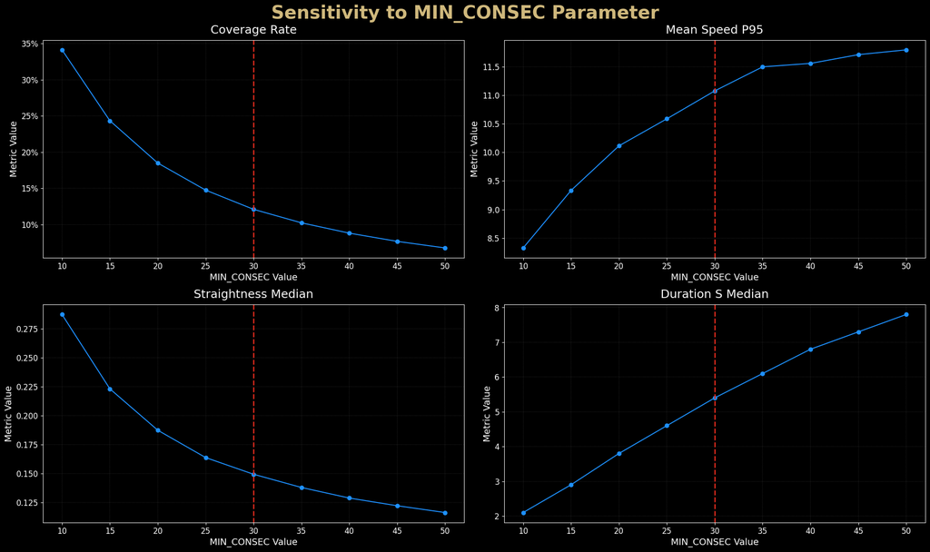

```
Figure saved to (Linux): /home/treinart/projects/lyft-unsupervised/artifacts/figures/20250917_201903_sensitivity_analysis_min_consec.png
Figure saved to (Win):   /mnt/c/Users/travi/Documents/Training/Colorado/MS-AI/CSCA 5632 Final Project/artifacts/figures/20250917_201903_sensitivity_analysis_min_consec.png
```

```python
# This cell will only run if the full computation is enabled.
if RUN_FEATURE_ENGINEERING:
    min_consec_values = range(10, 51, 5)
    sensitivity_results = []

    # Loop through the values, build features, and summarize
    for mc_value in min_consec_values:
        temp_feat_df = build_feature_table(agents_df_clean, min_consec=mc_value, dt=DT)
        if not temp_feat_df.empty:
            sensitivity_results.append({
                "min_consec": mc_value,
                "tracks_kept": len(temp_feat_df),
                "coverage_rate": len(temp_feat_df) / total_tracks,
                "mean_speed_median": temp_feat_df["mean_speed"].median(),
                "mean_speed_p95": temp_feat_df["mean_speed"].quantile(0.95),
                "straightness_median": temp_feat_df["straightness"].median(),
                "duration_s_median": temp_feat_df["duration_s"].median(),
            })

    sensitivity_df = pd.DataFrame(sensitivity_results)

    # Visualize the Results
    metrics_to_plot = [
        "coverage_rate", "mean_speed_p95",
        "straightness_median", "duration_s_median"
    ]

    # Plot each metric on its own subplot
    fig, axes = plt.subplots(2, 2, figsize=(20, 12), facecolor="black")
    fig.patch.set_facecolor("black")
    fig.suptitle("Sensitivity to MIN_CONSEC Parameter", fontsize=28, color="#CFB87C", fontweight="bold")
    axes = axes.flatten()

    # Plot each metric on its own subplot
    for ax, metric in zip(axes, metrics_to_plot):
        ax.plot(sensitivity_df["min_consec"], sensitivity_df[metric], marker='o', linestyle='-', color='dodgerblue')

        # Highlight MIN_CONSEC=30
        ax.axvline(30, color="#DA291C", linestyle='--', linewidth=2, label="Selected Value (30)")

        # Style the subplot
        ax.set_title(metric.replace("_", " ").title(), fontsize=18, color="#F8F8F8", pad=10)
        ax.set_xlabel("MIN_CONSEC Value", fontsize=14, color="white")
        ax.set_ylabel("Metric Value", fontsize=14, color="white")
        ax.set_facecolor("black")
        ax.tick_params(colors="white", labelsize=12)
        for spine in ax.spines.values():
            spine.set_edgecolor("white")
        ax.grid(color='gray', linestyle='--', linewidth=0.3, alpha=0.5)
        if metric == "coverage_rate": # Format y-axis as percentage for coverage
            ax.yaxis.set_major_formatter(plt.FuncFormatter('{:.0%}'.format))

    save_fig(fig, "sensitivity_analysis_min_consec")
else:
    print("--- Skipped: Loading from cache ---")
```

### 5.7 Final Feature Distributions

As a final check on the engineered features, this section plots the distribution of each metric after capping outliers. This visual "feature panel" provides a comprehensive overview of the shape, scale, and range of the data that will be fed into the clustering models. It's a crucial step to confirm that the preprocessing was effective and to understand the characteristics of the final feature space.

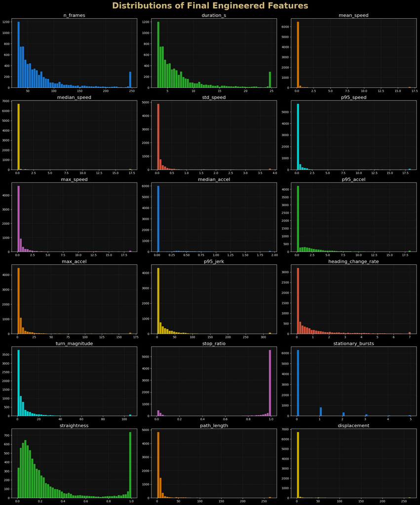

```
Figure saved to (Linux): /home/treinart/projects/lyft-unsupervised/artifacts/figures/20250917_205513_final_feature_distributions.png
Figure saved to (Win):   /mnt/c/Users/travi/Documents/Training/Colorado/MS-AI/CSCA 5632 Final Project/artifacts/figures/20250917_205513_final_feature_distributions.png
```

```python
# This cell will only run if the full computation is enabled.
if RUN_FEATURE_ENGINEERING:
    # Select all numeric feature columns
    numeric_cols = [c for c in feat_df_capped.columns if c not in ["scene_id", "track_id"]]

    # Determine the grid layout (3 columns) and create subplots
    n_features = len(numeric_cols)
    n_cols = 3
    n_rows = (n_features + n_cols - 1) // n_cols
    fig, axes = plt.subplots(n_rows, n_cols, figsize=(20, n_rows * 4), facecolor="black")
    fig.patch.set_facecolor("black")
    fig.suptitle("Distributions of Final Engineered Features", fontsize=28, color="#CFB87C", fontweight="bold", y=0.995)
    axes = axes.flatten()
    colors = ['dodgerblue', 'limegreen', 'darkorange', 'gold', 'tomato', 'aqua', 'orchid']

    # Plot a histogram for each feature
    for i, col in enumerate(numeric_cols):
        ax = axes[i]
        data = feat_df_capped[col].dropna()
        ax.hist(data, bins=50, color=colors[i % len(colors)], edgecolor='black', alpha=0.8)
        ax.set_title(col, fontsize=16, color="#F8F8F8", pad=5)
        ax.set_facecolor("#111111")
        ax.tick_params(colors="white", labelsize=10)
        for spine in ax.spines.values(): spine.set_edgecolor("white")
        ax.grid(color='gray', linestyle='--', linewidth=0.3, alpha=0.5)

    # Save the figure
    save_fig(fig, "final_feature_distributions")
else:
    print("--- Skipped: Loading from cache ---")
```

### **Observation: Classical Feature Engineering and Selection**

This section successfully transitioned from raw trajectory data to a structured, interpretable feature space suitable for clustering. A comprehensive catalog of 16 kinematic and geometric features was defined to numerically describe agent behavior. The core of the analysis involved a sensitivity test to determine an optimal track length threshold, culminating in a final, preprocessed feature matrix for Pipeline A.

**Conclusion:** Pipeline A's feature engineering is complete. The process successfully distilled raw trajectories into an interpretable feature set for **7,824** tracks. The analysis provided a clear, quantitative justification for the crucial `MIN_CONSEC` hyperparameter and confirmed the overwhelmingly stationary nature of the data that will be fed to the clustering algorithms. The final, standardized feature matrix is now ready for the modeling phase in Section 6.

## Section 6: Pipeline A - Clustering with Classical Features

This section executes the core modeling phase of Pipeline A. The goal is to apply a suite of unsupervised clustering algorithms to the interpretable features engineered in Section 5. The process involves a systematic approach: dimensionality reduction with PCA, extensive hyperparameter sweeps for three distinct clustering models (KMeans, GMM, HDBSCAN), and a data-driven model selection process based on a scorecard of internal validation and stability metrics. The section concludes by fitting the winning model and interpreting the resulting behavioral clusters.

### Section Plan:

**Checkpoint & Loader:** Option to skip computation and load the latest cached artifacts.

**Feature Selection & QA:** Select the final feature subset and perform a final quality assurance check.

**Dimensionality Reduction:** Apply PCA to create embeddings that capture 90%, 95%, and 98% of the variance.

**KMeans Hyperparameter Sweep:** Systematically test a range of cluster counts (k) for KMeans.

**GMM Hyperparameter Sweep:** Test a range of components and covariance types for Gaussian Mixture Models.

**HDBSCAN Hyperparameter Sweep:** Explore the parameter space for the density-based HDBSCAN model.

**Stability Analysis:** Evaluate the stability of the best KMeans and GMM models using bootstrap and the Adjusted Rand Index (ARI).

**Final Model Selection:** Use a weighted scorecard to rank all candidate models and select the overall winner.

**Fit Final Model:** Train the winning model on the full dataset and assign a cluster label to every track.

**Interpret Clusters (Profiling):** Analyze the median feature values for each cluster to create a numerical "persona" for each behavior.

**Qualitative Validation:** Plot sample trajectories from each cluster for a final, visual confirmation of the results.

### 6.1 Checkpoint: Run Full Section or Load from Cache

This cell acts as a checkpoint for the modeling section. The hyperparameter sweeps are the most time-consuming part of the entire project. Set the flag below to control the behavior of this section.

**`True`:** Run the full clustering sweeps and analysis. This is required on the first run.

**`False`:** Skip the long computations and load the final results (cluster assignments and profiles) from a previous run.

```python
# Set to True to run the time-consuming clustering sweeps and analysis.
# Set to False to skip computation and load the final results from a previous run.
RUN_CLUSTERING_SWEEPS = True

if not RUN_CLUSTERING_SWEEPS:
    print("--- Skipping clustering sweeps. Loading final artifacts from cache... ---")
    try:
        # Load the final cluster assignments and profiles from the stable artifact files
        final_clusters_df = pd.read_parquet(ARTIFACT_DIR / "pipeline_a_cluster_assignments.parquet")
        cluster_profiles = pd.read_parquet(ARTIFACT_DIR / "pipeline_a_cluster_profiles.parquet")

        # Load the winning model's metadata
        with open(ARTIFACT_DIR / "pipeline_a_final_model_meta.json", 'r') as f:
            best_model_params = json.load(f)

        print(f"Loaded {len(final_clusters_df):,} cluster assignments for {best_model_params['k']} clusters.")
        print(f"Winning model type: {best_model_params['model_type']}")
        print("\n--- Successfully loaded artifacts. Ready to proceed to Section 7 ---")
    except FileNotFoundError:
        print("\n--- ERROR: No final artifacts found. Please set RUN_CLUSTERING_SWEEPS to True and run the full section ---")
        # Set flag to True to prevent errors in subsequent cells
        RUN_CLUSTERING_SWEEPS = True
else:
    print("--- RUN_CLUSTERING_SWEEPS is True. Proceeding with full computation. ---")
```

```
--- RUN_CLUSTERING_SWEEPS is True. Proceeding with full computation. ---
```

### 6.2 Feature Selection & Quality Assurance

Before modeling, a subset of the most informative and independent features from the full engineered set is selected. This step explicitly defines the feature space for clustering. A final quality assurance check is performed on this subset to confirm data types, ranges, and check for any remaining null values before standardization.

```python
# This cell will only run if the full computation is enabled.
if RUN_CLUSTERING_SWEEPS:
    # Select the Final Feature Subset for Clustering
    FINAL_FEATURE_COLS = [
        "mean_speed", "p95_speed", "std_speed",
        "heading_change_rate", "stop_ratio", "straightness", "duration_s"
    ]
    model_features_df = feat_df_capped[[col for col in FINAL_FEATURE_COLS if col in feat_df_capped.columns]].copy()

    # Perform Final Quality Assurance
    qa_rows = []
    for col in model_features_df.columns:
        v = pd.to_numeric(model_features_df[col], errors="coerce").to_numpy()
        is_finite = np.isfinite(v)
        finite_count = int(is_finite.sum())
        total_count = len(v)
        qa_rows.append({
            "feature": col, "non_null_count": finite_count,
            "null_rate": (1.0 - finite_count / total_count) if total_count > 0 else 0.0,
            "min": float(np.min(v[is_finite])) if finite_count > 0 else np.nan,
            "median": float(np.median(v[is_finite])) if finite_count > 0 else np.nan,
            "p95": float(np.percentile(v[is_finite], 95)) if finite_count > 0 else np.nan,
            "max": float(np.max(v[is_finite])) if finite_count > 0 else np.nan,
            "mean": float(np.mean(v[is_finite])) if finite_count > 0 else np.nan,
            "std": float(np.std(v[is_finite])) if finite_count > 0 else np.nan,
        })
    qa_df = pd.DataFrame(qa_rows)

    # Create a formatted version for display
    pretty_qa = qa_df.copy()
    def format_or_dash(x, precision=3):
        col_name = _col_name # Relies on loop variable from below
        if pd.isna(x) or (isinstance(x, (int, float)) and abs(x) < 1e-9): return "---"
        if isinstance(x, float):
            if col_name == 'null_rate': return f"{x:.2%}"
            return f"{x:.{precision}f}"
        if isinstance(x, int): return f"{x:,}"
        return x

    for _col_name in ["non_null_count", "null_rate", "min", "median", "p95", "max", "mean", "std"]:
        pretty_qa[_col_name] = pretty_qa[_col_name].apply(format_or_dash)

    # Display the styled summary table
    print("\n--- Final Feature Quality Assurance Summary ---")
    display(style_section_table(pretty_qa))

    print("\n" + "-" * 70)
    print(f"\nFinal features in use: {model_features_df.columns.tolist()}")
    print(f"\nTotal tracks for modeling: {len(model_features_df):,}")
    print("\n" + "-" * 70)
else:
    print("--- Skipped: Loading from cache ---")
```

```
--- Final Feature Quality Assurance Summary ---
```

| feature | non_null_count | null_rate | min | median | p95 | max | mean | std |
| --- | --- | --- | --- | --- | --- | --- | --- | --- |
| mean_speed | 7,824 | --- | --- | 0.007 | 11.074 | 16.911 | 1.225 | 3.536 |
| p95_speed | 7,824 | --- | --- | --- | 13.193 | 18.374 | 1.637 | 4.125 |
| std_speed | 7,824 | --- | --- | 0.036 | 2.353 | 3.867 | 0.356 | 0.786 |
| heading_change_rate | 7,824 | --- | --- | 0.318 | 4.985 | 7.058 | 1.079 | 1.631 |
| stop_ratio | 7,824 | --- | 0.004 | 1.000 | 1.000 | 1.000 | 0.854 | 0.319 |
| straightness | 7,824 | --- | 0.000 | 0.149 | 0.998 | 1.000 | 0.279 | 0.308 |
| duration_s | 7,824 | --- | 3.000 | 5.400 | 21.600 | 24.900 | 7.386 | 5.366 |

```
----------------------------------------------------------------------

Final features in use: ['mean_speed', 'p95_speed', 'std_speed', 'heading_change_rate', 'stop_ratio', 'straightness', 'duration_s']

Total tracks for modeling: 7,824

----------------------------------------------------------------------
```

### 6.3 Dimensionality Reduction with PCA

Before clustering, the feature space is transformed using Principal Component Analysis (PCA). PCA serves two purposes: it reduces dimensionality by creating a smaller set of uncorrelated components, and it removes multicollinearity between original features. Three separate PCA models are trained to create embeddings that retain 90%, 95%, and 98% of the original variance, allowing for a comparison of how the degree of dimensionality reduction impacts clustering performance.

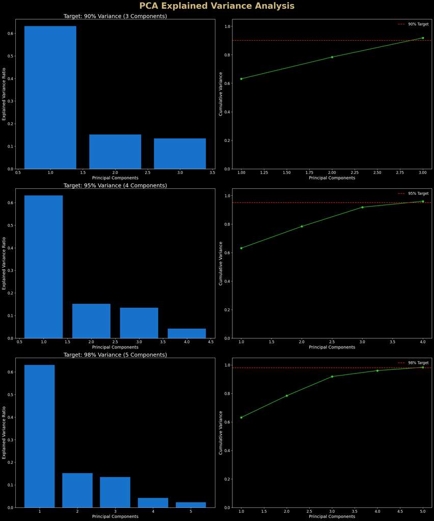

```
Figure saved to (Linux): /home/treinart/projects/lyft-unsupervised/artifacts/figures/20250917_202046_pca_variance_summary.png
Figure saved to (Win):   /mnt/c/Users/travi/Documents/Training/Colorado/MS-AI/CSCA 5632 Final Project/artifacts/figures/20250917_202046_pca_variance_summary.png
----------------------------------------------------------------------
PCA Model Summary:
  - pca_90: Retained 91.8% variance with 3 components.
  - pca_95: Retained 96.0% variance with 4 components.
  - pca_98: Retained 98.3% variance with 5 components.
----------------------------------------------------------------------
```

```python
# This cell will only run if the full computation is enabled.
if RUN_CLUSTERING_SWEEPS:
    # Standardize the Data
    X = model_features_df.fillna(model_features_df.mean()).to_numpy()
    scaler = StandardScaler()
    X_scaled = scaler.fit_transform(X)

    # Run PCA for Multiple Variance Targets
    VARIANCE_TARGETS = [0.90, 0.95, 0.98]
    PCA_MODELS = {}
    PCA_EMBEDDINGS = {}
    fig, axes = plt.subplots(len(VARIANCE_TARGETS), 2, figsize=(20, 8 * len(VARIANCE_TARGETS)), facecolor="black", constrained_layout=True)
    fig.patch.set_facecolor("black")
    fig.suptitle("PCA Explained Variance Analysis", fontsize=28, color="#CFB87C", fontweight="bold", y=0.995)

    for i, var_target in enumerate(VARIANCE_TARGETS):
        # Configure and fit the PCA model
        pca = PCA(n_components=var_target, random_state=SEED)
        Z = pca.fit_transform(X_scaled)
        key = f"pca_{int(var_target*100)}"
        PCA_MODELS[key] = pca
        PCA_EMBEDDINGS[key] = Z

        # Visualize Results for this Target
        ax1, ax2 = axes[i]
        explained_variance = pca.explained_variance_ratio_
        cumulative_variance = np.cumsum(explained_variance)
        ax1.bar(range(1, len(explained_variance) + 1), explained_variance, color='dodgerblue', alpha=0.8)
        ax1.set_title(f"Target: {var_target:.0%} Variance ({pca.n_components_} Components)", fontsize=18, color="#F8F8F8", pad=2)
        ax1.set_ylabel("Explained Variance Ratio", fontsize=14, color="white")
        ax2.plot(range(1, len(cumulative_variance) + 1), cumulative_variance, marker="o", color='limegreen')
        ax2.axhline(y=var_target, color='#DA291C', linestyle='--', label=f"{var_target:.0%} Target")
        ax2.set_ylabel("Cumulative Variance", fontsize=14, color="white")
        ax2.set_ylim(0, 1.05)
        ax2.legend(frameon=False, labelcolor="white", fontsize=12)
        for ax in [ax1, ax2]:
            ax.set_facecolor("black"); ax.tick_params(colors="white", labelsize=12)
            ax.set_xlabel("Principal Components", fontsize=14, color="white")
            for spine in ax.spines.values(): spine.set_edgecolor("white")

    # Finalize Plot and Print Summary
    save_fig(fig, "pca_variance_summary")

    print("-" * 70)
    print("PCA Model Summary:")
    for key, pca in PCA_MODELS.items():
        print(f"  - {key}: Retained {np.sum(pca.explained_variance_ratio_):.1%} variance with {pca.n_components_} components.")
    print("-" * 70)
else:
    print("--- Skipped: Loading from cache ---")
```

### 6.4 KMeans Hyperparameter Sweep

The first clustering model tested is KMeans. A "sweep" is performed to find the optimal number of clusters (k). The model is run for a range of k values across each of the three PCA embeddings. To ensure results are stable, each run is repeated with multiple random seeds. The quality of the resulting clusters is evaluated using three standard internal validation metrics: the Silhouette Score, Calinski-Harabasz Index, and Davies-Bouldin Index.

```
--- KMeans Metric Summary - pca_90 ---
```

| k | silhouette_mean | silhouette_std | calinski_harabasz_mean | calinski_harabasz_std | davies_bouldin_mean | davies_bouldin_std |
| --- | --- | --- | --- | --- | --- | --- |
| 4 | 0.558113 | 0.000195 | 10811.153367 | 0.250850 | 0.685120 | 0.000119 |
| 6 | 0.433921 | 0.042736 | 9485.525176 | 377.111747 | 0.897698 | 0.024360 |
| 8 | 0.411783 | 0.017212 | 9572.143739 | 415.896711 | 0.836856 | 0.005864 |
| 10 | 0.399580 | 0.019518 | 9996.236401 | 475.822988 | 0.841385 | 0.040188 |
| 12 | 0.390086 | 0.012525 | 10441.815522 | 79.281856 | 0.823006 | 0.005398 |
| 14 | 0.384684 | 0.005679 | 10191.732067 | 296.131068 | 0.862664 | 0.022568 |
| 16 | 0.380959 | 0.005245 | 9928.525339 | 115.421561 | 0.883743 | 0.018114 |
| 20 | 0.371993 | 0.005497 | 9539.111281 | 109.937480 | 0.902380 | 0.010010 |
| 24 | 0.367311 | 0.015064 | 9423.795582 | 130.357314 | 0.911917 | 0.023802 |

```
--- KMeans Metric Summary - pca_95 ---
```

| k | silhouette_mean | silhouette_std | calinski_harabasz_mean | calinski_harabasz_std | davies_bouldin_mean | davies_bouldin_std |
| --- | --- | --- | --- | --- | --- | --- |
| 4 | 0.514809 | 0.016230 | 8433.643582 | 751.488367 | 0.799536 | 0.140523 |
| 6 | 0.469594 | 0.075570 | 8235.681341 | 187.423089 | 0.869266 | 0.068815 |
| 8 | 0.368974 | 0.032001 | 7919.577282 | 154.285769 | 0.935235 | 0.022239 |
| 10 | 0.359268 | 0.012486 | 7963.450898 | 282.636038 | 0.878076 | 0.010764 |
| 12 | 0.365993 | 0.010430 | 8207.074484 | 211.260705 | 0.868232 | 0.022114 |
| 14 | 0.361116 | 0.010753 | 8096.907345 | 139.590823 | 0.875288 | 0.015906 |
| 16 | 0.352589 | 0.017004 | 7809.884371 | 113.396694 | 0.904471 | 0.007620 |
| 20 | 0.340587 | 0.005807 | 7546.713848 | 71.008301 | 0.934736 | 0.015227 |
| 24 | 0.329980 | 0.009266 | 7108.566868 | 76.889470 | 0.982610 | 0.027009 |

```
--- KMeans Metric Summary - pca_98 ---
```

| k | silhouette_mean | silhouette_std | calinski_harabasz_mean | calinski_harabasz_std | davies_bouldin_mean | davies_bouldin_std |
| --- | --- | --- | --- | --- | --- | --- |
| 4 | 0.504027 | 0.014991 | 7565.069355 | 609.543969 | 0.885779 | 0.196211 |
| 6 | 0.417754 | 0.100595 | 7189.419030 | 182.646279 | 0.966823 | 0.025617 |
| 8 | 0.370940 | 0.031851 | 6542.506545 | 177.845009 | 1.010975 | 0.033239 |
| 10 | 0.359228 | 0.026116 | 6632.616721 | 80.235354 | 0.954273 | 0.029806 |
| 12 | 0.354467 | 0.010858 | 6707.506901 | 260.762865 | 0.920963 | 0.030957 |
| 14 | 0.348860 | 0.023257 | 6733.494419 | 142.231824 | 0.916117 | 0.031247 |
| 16 | 0.344443 | 0.016859 | 6523.242601 | 134.319611 | 0.927473 | 0.025675 |
| 20 | 0.336156 | 0.007655 | 6187.553325 | 95.669432 | 0.976453 | 0.013826 |
| 24 | 0.328975 | 0.008320 | 5882.741494 | 29.280616 | 1.001827 | 0.022420 |

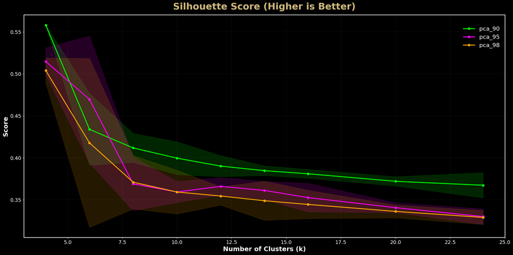

```
Figure saved to (Linux): /home/treinart/projects/lyft-unsupervised/artifacts/figures/20250917_202233_kmeans_sweep_silhouette.png
Figure saved to (Win):   /mnt/c/Users/travi/Documents/Training/Colorado/MS-AI/CSCA 5632 Final Project/artifacts/figures/20250917_202233_kmeans_sweep_silhouette.png
```

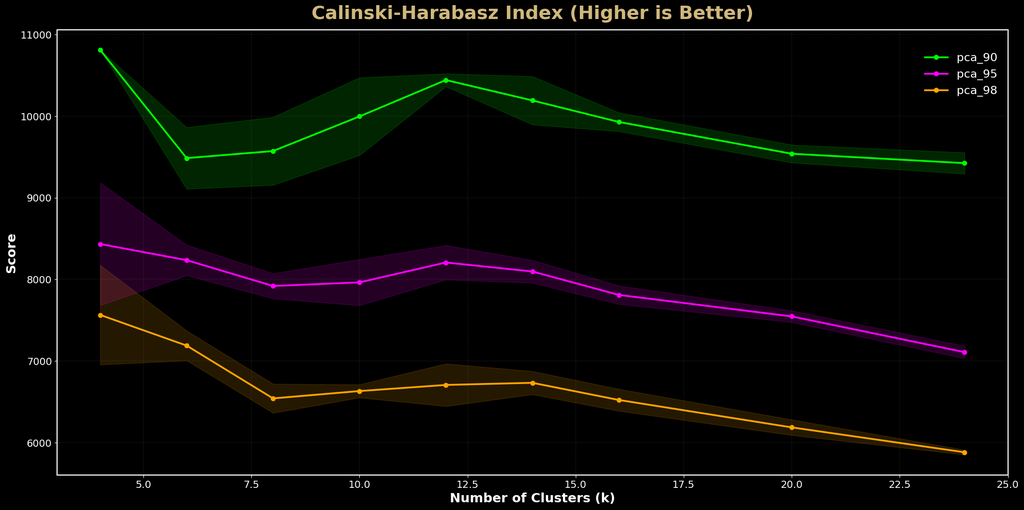

```
Figure saved to (Linux): /home/treinart/projects/lyft-unsupervised/artifacts/figures/20250917_202234_kmeans_sweep_calinski_harabasz.png
Figure saved to (Win):   /mnt/c/Users/travi/Documents/Training/Colorado/MS-AI/CSCA 5632 Final Project/artifacts/figures/20250917_202234_kmeans_sweep_calinski_harabasz.png
```

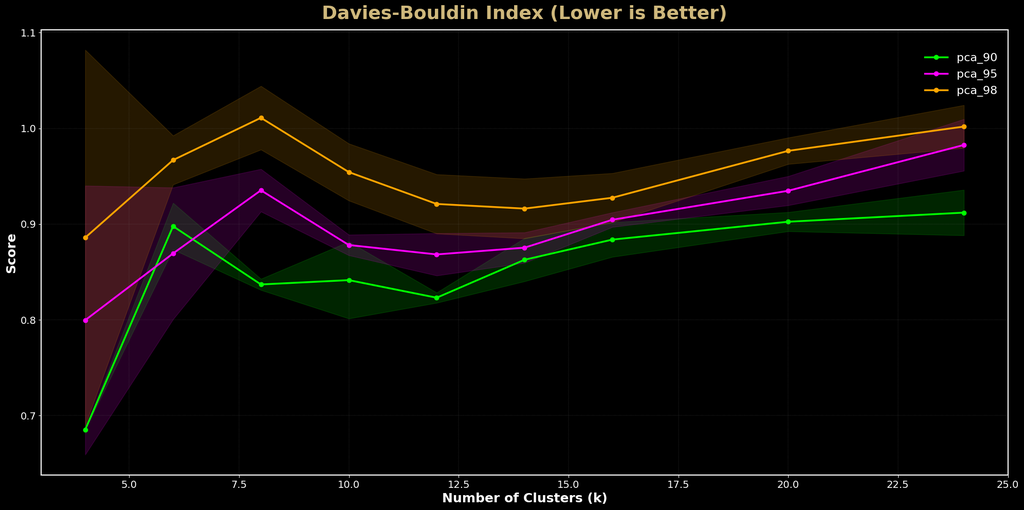

```
Figure saved to (Linux): /home/treinart/projects/lyft-unsupervised/artifacts/figures/20250917_202234_kmeans_sweep_davies_bouldin.png
Figure saved to (Win):   /mnt/c/Users/travi/Documents/Training/Colorado/MS-AI/CSCA 5632 Final Project/artifacts/figures/20250917_202234_kmeans_sweep_davies_bouldin.png
```

```python
# This cell will only run if the full computation is enabled.
if RUN_CLUSTERING_SWEEPS:
    # --- Define Sweep Parameters ---
    K_VALUES = [4, 6, 8, 10, 12, 14, 16, 20, 24]
    RANDOM_SEEDS = [0, 1, 2, 3, 4]

    # Run the KMeans Sweep
    kmeans_results = []
    pca_keys = list(PCA_EMBEDDINGS.keys())
    inner_total = len(K_VALUES) * len(RANDOM_SEEDS)
    pos_base = 0
    p_all = tqdm(total=len(pca_keys) * inner_total, desc="All KMeans runs", unit="run", position=pos_base, leave=True)
    bars = {key: tqdm(total=inner_total, desc=key, unit="run", position=pos_base + i + 1, leave=True) for i, key in enumerate(pca_keys)}

    for pca_key, p_bar in bars.items():
        Z = PCA_EMBEDDINGS[pca_key]
        for k in K_VALUES:
            for seed in RANDOM_SEEDS:
                kmeans = KMeans(n_clusters=k, n_init="auto", random_state=seed)
                labels = kmeans.fit_predict(Z)
                try:
                    sil = silhouette_score(Z, labels); ch = calinski_harabasz_score(Z, labels); db = davies_bouldin_score(Z, labels)
                except ValueError:
                    sil, ch, db = np.nan, np.nan, np.nan
                kmeans_results.append({"pca": pca_key, "k": k, "seed": seed, "silhouette": sil, "calinski_harabasz": ch, "davies_bouldin": db})
                p_bar.update(1); p_all.update(1)
                p_bar.set_postfix_str(f"k={k} seed={seed}")

    p_all.refresh(); [b.refresh() for b in bars.values()]
    kmeans_sweep_df = pd.DataFrame(kmeans_results)

    # Aggregate and Display Results
    kmeans_agg_df = (kmeans_sweep_df.groupby(["pca", "k"])
                     .agg(silhouette_mean=("silhouette", "mean"), silhouette_std=("silhouette", "std"),
                          calinski_harabasz_mean=("calinski_harabasz", "mean"), calinski_harabasz_std=("calinski_harabasz", "std"),
                          davies_bouldin_mean=("davies_bouldin", "mean"), davies_bouldin_std=("davies_bouldin", "std"))
                     .reset_index())
    for pca_key in PCA_EMBEDDINGS.keys():
        print(f"\n--- KMeans Metric Summary - {pca_key} ---")
        display(style_section_table(kmeans_agg_df[kmeans_agg_df["pca"] == pca_key].drop("pca", axis=1)))

    # Plot Metric Curves
    metrics_to_plot = {"silhouette": "Silhouette Score (Higher is Better)", "calinski_harabasz": "Calinski-Harabasz Index (Higher is Better)", "davies_bouldin": "Davies-Bouldin Index (Lower is Better)"}
    for metric, title in metrics_to_plot.items():
        fig, ax = plt.subplots(figsize=(20, 10), facecolor="black")
        ax.set_facecolor("black")

        colors = ['lime', 'magenta', 'orange']
        for color, pca_key in zip(colors, PCA_EMBEDDINGS.keys()):
            subset = kmeans_agg_df[kmeans_agg_df["pca"] == pca_key]
            ax.plot(subset["k"], subset[f"{metric}_mean"], marker='o', linestyle='-', label=pca_key, color=color, lw=2.5)
            ax.fill_between(subset["k"], subset[f"{metric}_mean"] - subset[f"{metric}_std"], subset[f"{metric}_mean"] + subset[f"{metric}_std"], alpha=0.15, color=color)

        ax.set_title(title, fontsize=26, color="#CFB87C", fontweight="bold", pad=15)
        ax.set_xlabel("Number of Clusters (k)", fontsize=18, color="white", fontweight="bold")
        ax.set_ylabel("Score", fontsize=18, color="white", fontweight="bold")
        ax.tick_params(colors="white", labelsize=14)
        for spine in ax.spines.values():
            spine.set_edgecolor("white"); spine.set_linewidth(1.5)
        ax.legend(frameon=False, labelcolor="white", fontsize=16, title="PCA Variant")
        ax.grid(color='gray', linestyle='--', linewidth=0.3, alpha=0.5)
        save_fig(fig, f"kmeans_sweep_{metric}")
else:
    print("--- Skipped: Loading from cache ---")
```

### 6.5 GMM Hyperparameter Sweep

The second model, Gaussian Mixture Models (GMM), offers more flexibility than KMeans by modeling clusters as ellipsoids. This allows for clusters of varying shape and orientation. The sweep for GMM tests a range of component counts (the equivalent of k) and two different covariance types ('full' and 'diag') across the three PCA embeddings. Model quality is evaluated using Silhouette Score and two information criteria metrics, BIC and AIC, which are well-suited for GMMs.

```
--- GMM BIC Winners (per PCA × covariance) ---
```

| PCA | Covariance | k | BIC ↓ | AIC ↓ | Silhouette ↑ |
| --- | --- | --- | --- | --- | --- |
| pca_90 | diag | 20 | 32,521 | 31,553 | 0.244 |
| pca_90 | full | 20 | 9,053 | 7,667 | 0.025 |
| pca_95 | diag | 20 | 29,344 | 28,097 | 0.172 |
| pca_95 | full | 20 | -28,336 | -30,419 | -0.001 |
| pca_98 | diag | 20 | 8,456 | 6,930 | 0.140 |
| pca_98 | full | 20 | -82,826 | -85,745 | -0.003 |

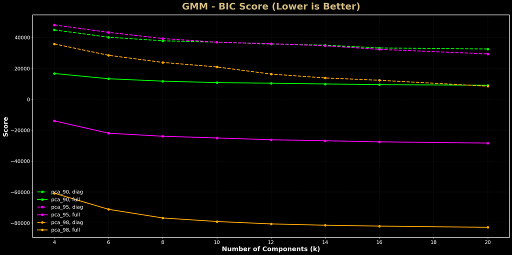

```
Figure saved to (Linux): /home/treinart/projects/lyft-unsupervised/artifacts/figures/20250917_204122_gmm_sweep_bic.png
Figure saved to (Win):   /mnt/c/Users/travi/Documents/Training/Colorado/MS-AI/CSCA 5632 Final Project/artifacts/figures/20250917_204122_gmm_sweep_bic.png
```

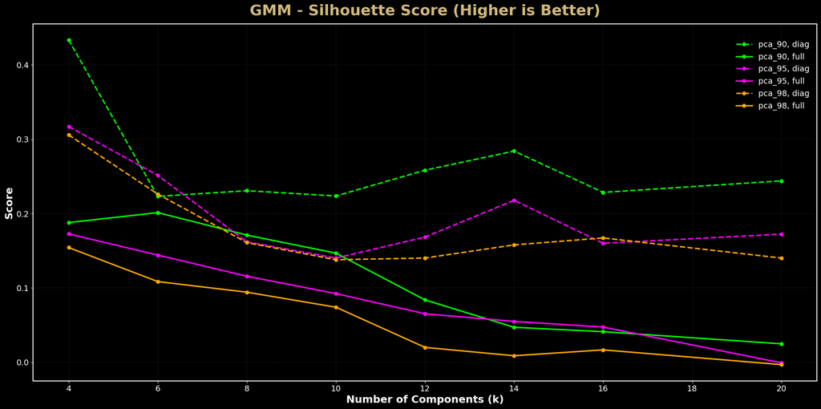

```
Figure saved to (Linux): /home/treinart/projects/lyft-unsupervised/artifacts/figures/20250917_204123_gmm_sweep_silhouette.png
Figure saved to (Win):   /mnt/c/Users/travi/Documents/Training/Colorado/MS-AI/CSCA 5632 Final Project/artifacts/figures/20250917_204123_gmm_sweep_silhouette.png
```

```python
# This cell will only run if the full computation is enabled.
if RUN_CLUSTERING_SWEEPS:
    # --- Define Sweep Parameters ---
    N_COMPONENTS = [4, 6, 8, 10, 12, 14, 16, 20]
    COVARIANCE_TYPES = ["full", "diag"]
    GMM_SEEDS = [0, 1, 2]

    # Run the GMM Sweep
    gmm_results = []
    pca_keys = list(PCA_EMBEDDINGS.keys())
    inner_total = len(COVARIANCE_TYPES) * len(N_COMPONENTS) * len(GMM_SEEDS)
    pos_base = 0
    p_all = tqdm(total=len(pca_keys) * inner_total, desc="All GMM runs", unit="run", position=pos_base, leave=True)
    bars = {key: tqdm(total=inner_total, desc=key, unit="run", position=pos_base + i + 1, leave=True) for i, key in enumerate(pca_keys)}

    for pca_key, p_bar in bars.items():
        Z = PCA_EMBEDDINGS[pca_key]
        for cov_type in COVARIANCE_TYPES:
            for k in N_COMPONENTS:
                for seed in GMM_SEEDS:
                    gmm = GaussianMixture(n_components=k, covariance_type=cov_type, random_state=seed)
                    labels = gmm.fit_predict(Z)
                    try:
                        sil = silhouette_score(Z, labels); bic = gmm.bic(Z); aic = gmm.aic(Z)
                    except ValueError:
                        sil, bic, aic = np.nan, np.nan, np.nan
                    gmm_results.append({"pca": pca_key, "covariance": cov_type, "k": k, "seed": seed, "silhouette": sil, "bic": bic, "aic": aic})
                    p_bar.update(1); p_all.update(1)
                    p_bar.set_postfix_str(f"{cov_type} k={k} seed={seed}")

    p_all.refresh(); [b.refresh() for b in bars.values()]
    gmm_sweep_df = pd.DataFrame(gmm_results)

    # Aggregate and Plot Results
    gmm_agg_df = (gmm_sweep_df.groupby(["pca", "covariance", "k"])
                  .agg(silhouette_mean=("silhouette", "mean"), bic_mean=("bic", "mean"), aic_mean=("aic", "mean"))
                  .reset_index())

    # BIC minimum per PCA × covariance table
    winners_df = (gmm_agg_df.sort_values("bic_mean", ascending=True)
                  .groupby(["pca", "covariance"], as_index=False)
                  .first()[["pca", "covariance", "k", "bic_mean", "aic_mean", "silhouette_mean"]])
    winners_pretty = winners_df.rename(columns={
        "pca": "PCA",
        "covariance": "Covariance",
        "k": "k",
        "bic_mean": "BIC ↓",
        "aic_mean": "AIC ↓",
        "silhouette_mean": "Silhouette ↑",
    }).copy()
    winners_pretty["BIC ↓"] = winners_pretty["BIC ↓"].map(lambda x: "---" if pd.isna(x) else f"{x:,.0f}")
    winners_pretty["AIC ↓"] = winners_pretty["AIC ↓"].map(lambda x: "---" if pd.isna(x) else f"{x:,.0f}")
    winners_pretty["Silhouette ↑"] = winners_pretty["Silhouette ↑"].map(lambda x: "---" if pd.isna(x) else f"{x:.3f}")
    print("\n--- GMM BIC Winners (per PCA × covariance) ---")
    display(style_section_table(winners_pretty))

    for metric, title in [("bic", "GMM - BIC Score (Lower is Better)"), ("silhouette", "GMM - Silhouette Score (Higher is Better)")]:
        fig, ax = plt.subplots(figsize=(20, 10), facecolor="black")
        ax.set_facecolor("black")

        styles = {"full": "-", "diag": "--"}; colors = {"pca_90": 'lime', "pca_95": 'magenta', "pca_98": 'orange'}
        for (pca_key, cov_type), group in gmm_agg_df.groupby(["pca", "covariance"]):
            ax.plot(group["k"], group[f"{metric}_mean"], marker='o', linestyle=styles[cov_type], label=f"{pca_key}, {cov_type}", color=colors[pca_key], lw=2.5)

        ax.set_title(title, fontsize=26, color="#CFB87C", fontweight="bold", pad=15)
        ax.set_xlabel("Number of Components (k)", fontsize=18, color="white", fontweight="bold")
        ax.set_ylabel("Score", fontsize=18, color="white", fontweight="bold")
        ax.tick_params(colors="white", labelsize=14)
        for spine in ax.spines.values():
            spine.set_edgecolor("white"); spine.set_linewidth(1.5)
        ax.legend(frameon=False, labelcolor="white", fontsize=14, title="PCA & Covariance")
        ax.grid(color='gray', linestyle='--', linewidth=0.3, alpha=0.5)
        save_fig(fig, f"gmm_sweep_{metric}")
else:
    print("--- Skipped: Loading from cache ---")
```

### 6.6 HDBSCAN Hyperparameter Sweep

The final model, HDBSCAN, is a powerful density-based algorithm that can discover clusters of arbitrary shape and, critically, identify points that do not belong to any cluster (marking them as noise). This is a significant advantage for real-world data. The sweep explores different settings for `min_cluster_size` and `min_samples` to see how these parameters affect the number of clusters found, the noise rate, and the quality of the non-noise clusters.

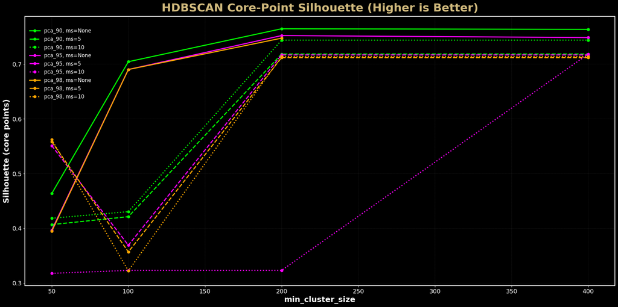

```
Figure saved to (Linux): /home/treinart/projects/lyft-unsupervised/artifacts/figures/20250917_204204_hdbscan_sweep_silhouette.png
Figure saved to (Win):   /mnt/c/Users/travi/Documents/Training/Colorado/MS-AI/CSCA 5632 Final Project/artifacts/figures/20250917_204204_hdbscan_sweep_silhouette.png
```

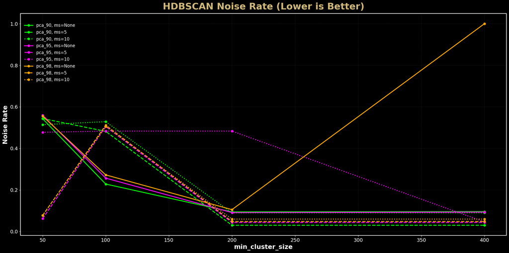

```
Figure saved to (Linux): /home/treinart/projects/lyft-unsupervised/artifacts/figures/20250917_204204_hdbscan_sweep_noise.png
Figure saved to (Win):   /mnt/c/Users/travi/Documents/Training/Colorado/MS-AI/CSCA 5632 Final Project/artifacts/figures/20250917_204204_hdbscan_sweep_noise.png

----------------------------------------------------------------------
HDBSCAN Sweep Summary
```

| pca | min_cluster_size | min_samples | clusters_found | noise_rate | silhouette_core |
| --- | --- | --- | --- | --- | --- |
| pca_90 | 50 | -1 | 5 | 0.542945 | 0.463477 |
| pca_90 | 50 | 5 | 10 | 0.543456 | 0.406803 |
| pca_90 | 50 | 10 | 7 | 0.513931 | 0.418383 |
| pca_90 | 100 | -1 | 3 | 0.228144 | 0.704251 |
| pca_90 | 100 | 5 | 4 | 0.481851 | 0.421262 |
| pca_90 | 100 | 10 | 4 | 0.528502 | 0.430424 |
| pca_90 | 200 | -1 | 2 | 0.093942 | 0.764389 |
| pca_90 | 200 | 5 | 2 | 0.029780 | 0.718295 |
| pca_90 | 200 | 10 | 2 | 0.089596 | 0.743606 |
| pca_90 | 400 | -1 | 2 | 0.095348 | 0.763257 |
| pca_90 | 400 | 5 | 2 | 0.029780 | 0.718295 |
| pca_90 | 400 | 10 | 2 | 0.089596 | 0.743606 |
| pca_95 | 50 | -1 | 6 | 0.559560 | 0.396691 |
| pca_95 | 50 | 5 | 5 | 0.061989 | 0.550982 |
| pca_95 | 50 | 10 | 8 | 0.477377 | 0.317806 |
| pca_95 | 100 | -1 | 3 | 0.256518 | 0.690012 |
| pca_95 | 100 | 5 | 4 | 0.505240 | 0.369126 |
| pca_95 | 100 | 10 | 4 | 0.483001 | 0.323197 |
| pca_95 | 200 | -1 | 2 | 0.090746 | 0.751962 |
| pca_95 | 200 | 5 | 2 | 0.043073 | 0.716676 |
| pca_95 | 200 | 10 | 4 | 0.483001 | 0.323197 |
| pca_95 | 400 | -1 | 2 | 0.093047 | 0.748298 |
| pca_95 | 400 | 5 | 2 | 0.043073 | 0.716676 |
| pca_95 | 400 | 10 | 2 | 0.046012 | 0.718181 |
| pca_98 | 50 | -1 | 4 | 0.555087 | 0.394590 |
| pca_98 | 50 | 5 | 6 | 0.076304 | 0.558311 |
| pca_98 | 50 | 10 | 6 | 0.078093 | 0.562045 |
| pca_98 | 100 | -1 | 3 | 0.272239 | 0.689982 |
| pca_98 | 100 | 5 | 4 | 0.511631 | 0.356951 |
| pca_98 | 100 | 10 | 4 | 0.505496 | 0.322478 |
| pca_98 | 200 | -1 | 2 | 0.104934 | 0.747233 |
| pca_98 | 200 | 5 | 2 | 0.047929 | 0.711730 |
| pca_98 | 200 | 10 | 2 | 0.059560 | 0.713755 |
| pca_98 | 400 | -1 | 0 | 1.000000 | nan |
| pca_98 | 400 | 5 | 2 | 0.047929 | 0.711730 |
| pca_98 | 400 | 10 | 2 | 0.059560 | 0.713755 |

```python
# This cell will only run if the full computation is enabled.
if RUN_CLUSTERING_SWEEPS:
    # Define Sweep Parameters
    MIN_CLUSTER_SIZES = [50, 100, 200, 400]
    MIN_SAMPLES = [None, 5, 10]

    # Run the HDBSCAN Sweep
    hdbscan_results = []
    params = list(product(PCA_EMBEDDINGS.keys(), MIN_CLUSTER_SIZES, MIN_SAMPLES))
    for pca_key, mcs, ms in tqdm(params, desc="Running HDBSCAN Sweep"):
        Z = PCA_EMBEDDINGS[pca_key]
        clusterer = hdbscan.HDBSCAN(min_cluster_size=mcs, min_samples=ms, metric='euclidean')
        labels = clusterer.fit_predict(Z)

        # Calculate quality metrics
        is_core_point = labels >= 0
        noise_rate = 1.0 - is_core_point.mean()
        n_clusters = len(set(labels)) - (1 if -1 in labels else 0)
        sil = silhouette_score(Z[is_core_point], labels[is_core_point]) if n_clusters > 1 else np.nan

        hdbscan_results.append({
            "pca": pca_key, "min_cluster_size": mcs, "min_samples": -1 if ms is None else ms,
            "clusters_found": n_clusters, "noise_rate": noise_rate, "silhouette_core": sil,
        })
    hdbscan_sweep_df = pd.DataFrame(hdbscan_results)

    # Summary plots for HDBSCAN trade-offs ---
    ms_styles = {-1: "-", 5: "--", 10: ":"}
    ms_labels = {-1: "None", 5: "5", 10: "10"}
    pca_colors = {"pca_90": "lime", "pca_95": "magenta", "pca_98": "orange"}

    # Plot 1: Silhouette on core points
    fig, ax = plt.subplots(figsize=(20, 10), facecolor="black")
    ax.set_facecolor("black")
    for pca_key in PCA_EMBEDDINGS.keys():
        for ms in sorted(hdbscan_sweep_df["min_samples"].unique()):
            sub = (hdbscan_sweep_df[(hdbscan_sweep_df["pca"] == pca_key) &
                                    (hdbscan_sweep_df["min_samples"] == ms)]
                   .sort_values("min_cluster_size"))
            if len(sub):
                ax.plot(sub["min_cluster_size"], sub["silhouette_core"],
                        marker="o", lw=2.5,
                        linestyle=ms_styles.get(ms, "-"),
                        color=pca_colors.get(pca_key, "white"),
                        label=f"{pca_key}, ms={ms_labels.get(ms, str(ms))}")
    ax.set_title("HDBSCAN Core-Point Silhouette (Higher is Better)", fontsize=26, color="#CFB87C", fontweight="bold", pad=12)
    ax.set_xlabel("min_cluster_size", fontsize=18, color="white", fontweight="bold")
    ax.set_ylabel("Silhouette (core points)", fontsize=18, color="white", fontweight="bold")
    ax.tick_params(colors="white", labelsize=14)
    for sp in ax.spines.values():
        sp.set_edgecolor("white"); sp.set_linewidth(1.5)
    ax.grid(color="gray", linestyle="--", linewidth=0.3, alpha=0.5)
    ax.legend(frameon=False, labelcolor="white", fontsize=12, title="PCA, min_samples")
    save_fig(fig, "hdbscan_sweep_silhouette")

    # Plot 2: Noise rate
    fig, ax = plt.subplots(figsize=(20, 10), facecolor="black")
    ax.set_facecolor("black")
    for pca_key in PCA_EMBEDDINGS.keys():
        for ms in sorted(hdbscan_sweep_df["min_samples"].unique()):
            sub = (hdbscan_sweep_df[(hdbscan_sweep_df["pca"] == pca_key) &
                                    (hdbscan_sweep_df["min_samples"] == ms)]
                   .sort_values("min_cluster_size"))
            if len(sub):
                ax.plot(sub["min_cluster_size"], sub["noise_rate"],
                        marker="o", lw=2.5,
                        linestyle=ms_styles.get(ms, "-"),
                        color=pca_colors.get(pca_key, "white"),
                        label=f"{pca_key}, ms={ms_labels.get(ms, str(ms))}")
    ax.set_title("HDBSCAN Noise Rate (Lower is Better)", fontsize=26, color="#CFB87C", fontweight="bold", pad=12)
    ax.set_xlabel("min_cluster_size", fontsize=18, color="white", fontweight="bold")
    ax.set_ylabel("Noise Rate", fontsize=18, color="white", fontweight="bold")
    ax.tick_params(colors="white", labelsize=14)
    for sp in ax.spines.values():
        sp.set_edgecolor("white"); sp.set_linewidth(1.5)
    ax.grid(color="gray", linestyle="--", linewidth=0.3, alpha=0.5)
    ax.legend(frameon=False, labelcolor="white", fontsize=12, title="PCA, min_samples")
    save_fig(fig, "hdbscan_sweep_noise")

    # Display Results
    print("\n" + "-" * 70)
    print("HDBSCAN Sweep Summary")
    display(style_section_table(hdbscan_sweep_df))
else:
    print("--- Skipped: Loading from cache ---")
```

### 6.7 Stability Analysis

Internal validation metrics are useful, but they don't guarantee that a clustering solution is stable or reproducible. This analysis checks the stability of the best-performing KMeans and GMM models. A bootstrap resampling method is used: the model is trained on multiple random subsets of the data, and the consistency of the resulting cluster assignments is measured using the Adjusted Rand Index (ARI). A high average ARI score indicates a stable and reliable clustering solution.

```python
# This cell will only run if the full computation is enabled.
if RUN_CLUSTERING_SWEEPS:
    # Identify Best Candidate Models from Sweeps
    best_km_params = kmeans_agg_df.loc[kmeans_agg_df['silhouette_mean'].idxmax()]
    km_candidate = {"pca": best_km_params["pca"], "k": int(best_km_params["k"])}
    best_gmm_params = gmm_agg_df.loc[gmm_agg_df['bic_mean'].idxmin()]
    gmm_candidate = {"pca": best_gmm_params["pca"], "k": int(best_gmm_params["k"]), "cov": best_gmm_params["covariance"]}

    # Define the Bootstrap ARI Function
    def calculate_bootstrap_ari(model_type: str, params: dict, n_bootstraps: int = 10, frac: float = 0.8):
        Z = PCA_EMBEDDINGS[params["pca"]]
        n_samples = Z.shape[0]
        bootstrap_labels = []
        p_boot = tqdm(range(n_bootstraps),
                      desc=f"{model_type.upper()} bootstraps",
                      unit="fit",
                      leave=True,
                      dynamic_ncols=True)

        for i in p_boot:
            rng = np.random.default_rng(SEED + i)
            indices = rng.choice(n_samples, size=int(frac * n_samples), replace=True)
            Z_sample = Z[indices]

            if model_type == "kmeans":
                model = KMeans(n_clusters=params["k"], n_init="auto", random_state=SEED)
            else:
                model = GaussianMixture(n_components=params["k"], covariance_type=params["cov"], random_state=SEED)

            full_labels = np.full(n_samples, -1)
            sample_labels = model.fit_predict(Z_sample)
            full_labels[indices] = sample_labels
            bootstrap_labels.append(full_labels)

            p_boot.set_postfix_str(f"done={i+1}/{n_bootstraps}")

        total_pairs = n_bootstraps * (n_bootstraps - 1) // 2
        p_pair = tqdm(total=total_pairs,
                      desc=f"{model_type.upper()} pairwise ARI",
                      unit="pair",
                      leave=True,
                      dynamic_ncols=True)

        ari_scores = []
        for i in range(n_bootstraps):
            for j in range(i + 1, n_bootstraps):
                common = (bootstrap_labels[i] >= 0) & (bootstrap_labels[j] >= 0)
                if common.sum() > 1:
                    ari = ARI(bootstrap_labels[i][common], bootstrap_labels[j][common])
                    ari_scores.append(ari)
                p_pair.update(1)

        return (np.mean(ari_scores) if ari_scores else np.nan,
                np.std(ari_scores) if ari_scores else np.nan)

    # Run Stability Analysis
    print("\n--- Running Stability Analysis (Bootstrap ARI) ---")
    print("KMeans candidate:", km_candidate)
    print("GMM candidate   :", gmm_candidate)
    km_ari_mean, km_ari_std = calculate_bootstrap_ari("kmeans", km_candidate)
    gm_ari_mean, gm_ari_std = calculate_bootstrap_ari("gmm", gmm_candidate)

    stability_df = pd.DataFrame([
        {"model": "KMeans", **km_candidate, "ari_mean": km_ari_mean, "ari_std": km_ari_std},
        {"model": "GMM", **gmm_candidate, "ari_mean": gm_ari_mean, "ari_std": gm_ari_std},
    ])

    print("\n--- Model Stability Summary ---")
    display(style_section_table(stability_df))
else:
    print("--- Skipped: Loading from cache ---")
```

```
--- Running Stability Analysis (Bootstrap ARI) ---
KMeans candidate: {'pca': 'pca_90', 'k': 4}
GMM candidate   : {'pca': 'pca_98', 'k': 20, 'cov': 'full'}
```

```
--- Model Stability Summary ---
```

| model | pca | k | ari_mean | ari_std | cov |
| --- | --- | --- | --- | --- | --- |
| KMeans | pca_90 | 4 | 0.778518 | 0.163606 | nan |
| GMM | pca_98 | 20 | 0.904325 | 0.017322 | full |

### 6.8 Final Model Selection

To make a final, data-driven decision, a weighted scorecard is created. This table collects the top-performing configurations for KMeans and GMM from the hyperparameter sweeps, along with their stability scores. Each metric is normalized (as a Z-score), and a final weighted score is calculated to rank all candidates. The weights prioritize models with high Silhouette and high stability (ARI), providing a balanced evaluation to select the single best model for this pipeline.

```python
# This cell will only run if the full computation is enabled.
if RUN_CLUSTERING_SWEEPS:

    # Consolidate All Candidate Models
    candidates = []
    top_kmeans = (kmeans_agg_df.sort_values("silhouette_mean", ascending=False).groupby("pca").head(5).reset_index(drop=True))
    for _, row in top_kmeans.iterrows():
        is_best_stable = (row["pca"] == km_candidate["pca"] and row["k"] == km_candidate["k"])
        candidates.append({"model": "KMeans", "pca": row["pca"], "k": int(row["k"]), "cov_type": None, "sil": row["silhouette_mean"], "ch": row["calinski_harabasz_mean"], "db": row["davies_bouldin_mean"], "bic": np.nan, "aic": np.nan, "ari_mean": km_ari_mean if is_best_stable else np.nan})

    top_gmm = (gmm_agg_df.sort_values("bic_mean", ascending=True).groupby(["pca", "covariance"]).head(5).reset_index(drop=True))
    for _, row in top_gmm.iterrows():
        is_best_stable = (row["pca"] == gmm_candidate["pca"] and row["k"] == gmm_candidate["k"] and row["covariance"] == gmm_candidate["cov"])
        candidates.append({"model": "GMM", "pca": row["pca"], "k": int(row["k"]), "cov_type": row["covariance"], "sil": row["silhouette_mean"], "ch": np.nan, "db": np.nan, "bic": row["bic_mean"], "aic": row["aic_mean"], "ari_mean": gm_ari_mean if is_best_stable else np.nan})
    candidates_df = pd.DataFrame(candidates)

    # Create the Weighted Scorecard
    scorecard_df = candidates_df.copy()
    metrics_to_normalize = {"sil": 1, "ch": 1, "db": -1, "bic": -1, "aic": -1, "ari_mean": 1}
    for metric, sign in metrics_to_normalize.items():
        col = scorecard_df[metric]
        scorecard_df[f"{metric}_z"] = sign * (col - col.mean()) / col.std()

    scorecard_df = scorecard_df.fillna(0)
    scorecard_df["final_score"] = (1.5 * scorecard_df["sil_z"] + 1.0 * scorecard_df["ch_z"] + 1.0 * scorecard_df["db_z"] + 1.0 * scorecard_df["bic_z"] + 0.5 * scorecard_df["aic_z"] + 2.0 * scorecard_df["ari_mean_z"])

    # Display Final Ranking
    ranked_df = scorecard_df.sort_values("final_score", ascending=False).reset_index(drop=True)
    display_cols = ["model", "pca", "k", "cov_type", "final_score", "sil", "ari_mean", "bic", "db", "ch"]
    pretty_df = ranked_df[display_cols].head(10).copy()
    def format_or_dash(x, precision=3, is_score=False):
        if pd.isna(x): return "---"
        if isinstance(x, (int, float)) and abs(x) < 1e-9 and not is_score: return "---"
        if isinstance(x, float): return f"{x:+.{precision}f}" if is_score else f"{x:.{precision}f}"
        return x

    pretty_df['cov_type'] = pretty_df['cov_type'].fillna("---")
    pretty_df['final_score'] = pretty_df['final_score'].apply(lambda v: format_or_dash(v, is_score=True))
    for col in ["sil", "ari_mean", "db"]: pretty_df[col] = pretty_df[col].apply(format_or_dash)
    for col in ["bic", "ch"]: pretty_df[col] = pretty_df[col].apply(lambda v: format_or_dash(v, precision=0))

    print("--- Final Model Scorecard and Ranking ---")
    display(style_section_table(pretty_df))

    # Select the Winning Model
    best_model_params = ranked_df.iloc[0].to_dict()
    print("\n" + "-" * 70)
    print("\n--- WINNING MODEL CONFIGURATION ---")
    print(f"  - Model: {best_model_params['model']}")
    print(f"  - PCA Embedding: {best_model_params['pca']}")
    print(f"  - Number of Clusters (k): {int(best_model_params['k'])}")
    if best_model_params['model'] == 'GMM': print(f"  - Covariance Type: {best_model_params['cov_type']}")
    print("\n" + "-" * 70)
else:
    print("--- Skipped: Loading from cache ---")
```

```
--- Final Model Scorecard and Ranking ---
```

| model | pca | k | cov_type | final_score | sil | ari_mean | bic | db | ch |
| --- | --- | --- | --- | --- | --- | --- | --- | --- | --- |
| KMeans | pca_90 | 4 | 0 | +5.910 | 0.558 | 0.779 | --- | 0.685 | 10811 |
| KMeans | pca_95 | 4 | 0 | +3.761 | 0.515 | --- | --- | 0.800 | 8434 |
| KMeans | pca_90 | 12 | 0 | +3.756 | 0.390 | --- | --- | 0.823 | 10442 |
| KMeans | pca_90 | 10 | 0 | +3.290 | 0.400 | --- | --- | 0.841 | 9996 |
| KMeans | pca_90 | 8 | 0 | +3.155 | 0.412 | --- | --- | 0.837 | 9572 |
| KMeans | pca_90 | 6 | 0 | +2.523 | 0.434 | --- | --- | 0.898 | 9486 |
| KMeans | pca_95 | 6 | 0 | +2.314 | 0.470 | --- | --- | 0.869 | 8236 |
| GMM | pca_98 | 20 | full | +2.286 | -0.003 | 0.904 | -82826 | --- | --- |
| KMeans | pca_98 | 4 | 0 | +1.940 | 0.504 | --- | --- | 0.886 | 7565 |
| GMM | pca_98 | 10 | full | +1.430 | 0.074 | --- | -79058 | --- | --- |

```
----------------------------------------------------------------------

--- WINNING MODEL CONFIGURATION ---
  - Model: KMeans
  - PCA Embedding: pca_90
  - Number of Clusters (k): 4

----------------------------------------------------------------------
```

### 6.9 Fit Final Model & Assign Labels

```python
# This cell will only run if the full computation is enabled.
if RUN_CLUSTERING_SWEEPS:
    # Configure the Final Model
    pca_key = best_model_params['pca']
    Z_final = PCA_EMBEDDINGS[pca_key]
    k_final = int(best_model_params['k'])
    if best_model_params['model'] == 'KMeans':
        final_model = KMeans(n_clusters=k_final, n_init='auto', random_state=SEED)
        model_meta = {"model_type": "KMeans", "k": k_final, "pca_variant": pca_key, "pca_components": PCA_MODELS[pca_key].n_components_, "seed": SEED}
    else:  # GMM
        cov_final = best_model_params['cov_type']
        final_model = GaussianMixture(n_components=k_final, covariance_type=cov_final, random_state=SEED)
        model_meta = {"model_type": "GMM", "k": k_final, "covariance_type": cov_final, "pca_variant": pca_key, "pca_components": PCA_MODELS[pca_key].n_components_, "seed": SEED}

    # Fit the Model and Predict Labels
    print(f"\n--- Fitting final {model_meta['model_type']} model ---")
    final_labels = final_model.fit_predict(Z_final)

    # Create Final Output Table
    final_clusters_df = feat_df_capped[["scene_id", "track_id"]].copy()
    final_clusters_df["cluster_id"] = final_labels

    # Save Timestamped and Final Artifacts
    print("\n--- Caching timestamped cluster assignments ---")
    _save_df(final_clusters_df, "final_cluster_assignments_pipeline_a")

    print("\nSaving final cluster assignments for Section 11...")
    final_clusters_df.to_parquet(ARTIFACT_DIR / "pipeline_a_cluster_assignments.parquet", index=False)

    print(f"Saved to: {ARTIFACT_DIR / 'pipeline_a_cluster_assignments.parquet'}")

    ts = time.strftime("%Y%m%d_%H%M%S")
    meta_path_linux = CACHE_DIR / f"{ts}_final_model_meta_pipeline_a.json"
    meta_path_final = ARTIFACT_DIR / "pipeline_a_final_model_meta.json"

    def _py(obj):
        import numpy as np
        if isinstance(obj, np.generic):
            return obj.item()
        return obj
    model_meta = {k: _py(v) for k, v in model_meta.items()}

    with open(meta_path_linux, "w") as f:
        json.dump(model_meta, f, indent=2)
    with open(meta_path_final, "w") as f:
        json.dump(model_meta, f, indent=2)
    try:
        shutil.copy2(meta_path_linux, WINDOWS_MIRROR / "cache")
    except Exception:
        pass

    print(f"\nModel metadata saved to (cache): {meta_path_linux}")
    print(f"Model metadata saved to (final): {meta_path_final}")
    print("\n" + "-" * 70)
else:
    print("--- Skipped: Loading from cache ---")
```

```
--- Fitting final KMeans model ---

--- Caching timestamped cluster assignments ---

Saving final cluster assignments for Section 11...
Saved to: /home/treinart/projects/lyft-unsupervised/artifacts/pipeline_a_cluster_assignments.parquet

Model metadata saved to (cache): /home/treinart/projects/lyft-unsupervised/artifacts/cache/20250917_210001_final_model_meta_pipeline_a.json
Model metadata saved to (final): /home/treinart/projects/lyft-unsupervised/artifacts/pipeline_a_final_model_meta.json

----------------------------------------------------------------------
```

### 6.10 Interpret Clusters: Quantitative Profiling

```
--- Cluster Feature Profiles (Median Values) ---
```

| mean_speed | p95_speed | std_speed | heading_change_rate | stop_ratio | straightness | duration_s |
| --- | --- | --- | --- | --- | --- | --- |
| 10.377 | 12.571 | 2.209 | 0.337 | 0.026 | 0.998 | 6.700 |
| --- | --- | --- | --- | 1.000 | 0.111 | 5.800 |
| 0.160 | 0.561 | 0.233 | 5.027 | 0.933 | 0.129 | 6.900 |
| 0.044 | 0.295 | 0.120 | 1.946 | 1.000 | 0.201 | 4.100 |

```
--- Saving final cluster profiles for later use ---
Saved to: /home/treinart/projects/lyft-unsupervised/artifacts/pipeline_a_cluster_profiles.parquet
```

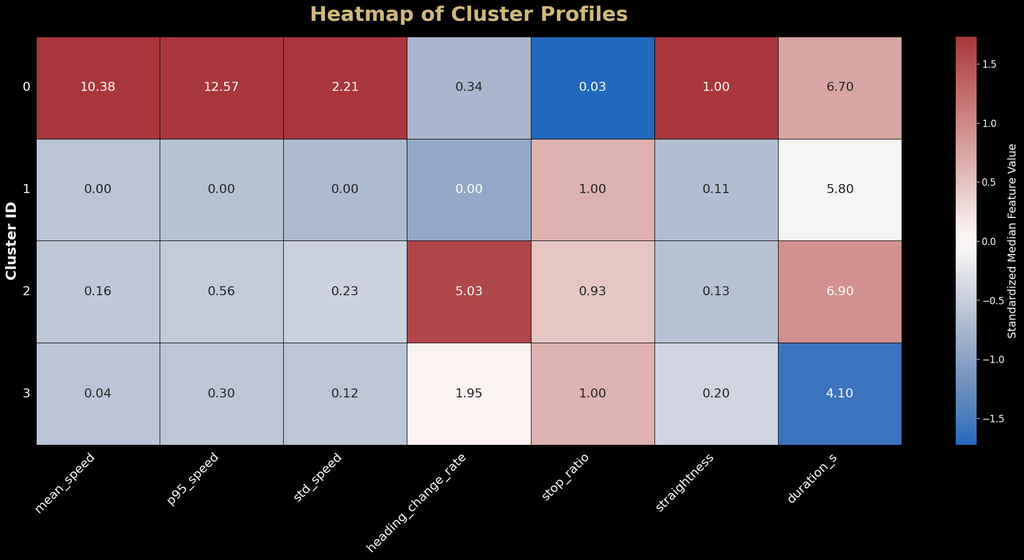

```
Figure saved to (Linux): /home/treinart/projects/lyft-unsupervised/artifacts/figures/20250917_210004_cluster_profiles_heatmap.png
Figure saved to (Win):   /mnt/c/Users/travi/Documents/Training/Colorado/MS-AI/CSCA 5632 Final Project/artifacts/figures/20250917_210004_cluster_profiles_heatmap.png
```

```python
# Create Cluster Profiles
profiles_df_input = final_clusters_df.merge(feat_df_capped, on=["scene_id", "track_id"])
cols = [c for c in FINAL_FEATURE_COLS if c in profiles_df_input.columns]
cluster_profiles = (profiles_df_input.groupby("cluster_id")[cols]
                    .median()
                    .sort_index())

# Create a formatted version for display
pretty_profiles = cluster_profiles.copy()
def format_or_dash(x, precision=3):
    if pd.isna(x) or (isinstance(x, (int, float)) and abs(x) < 1e-9): return "---"
    if isinstance(x, float): return f"{x:.{precision}f}"
    return x
for col in pretty_profiles.columns:
    pretty_profiles[col] = pretty_profiles[col].apply(format_or_dash)
print("--- Cluster Feature Profiles (Median Values) ---")
display(style_section_table(pretty_profiles))

# Save Final Profiles for Section 11
print("\n--- Saving final cluster profiles for later use ---")
cluster_profiles.to_parquet(ARTIFACT_DIR / "pipeline_a_cluster_profiles.parquet")
print(f"Saved to: {ARTIFACT_DIR / 'pipeline_a_cluster_profiles.parquet'}")

# Visualize Profiles with a Heatmap
profile_scaled = StandardScaler().fit_transform(cluster_profiles)
fig, ax = plt.subplots(figsize=(20, 10), facecolor="black")
sns.heatmap(
    profile_scaled, annot=cluster_profiles.to_numpy(), fmt=".2f", cmap="vlag",
    linewidths=0.5, linecolor='black', ax=ax, cbar_kws={"shrink": 1.0}, annot_kws={"size": 16}
)
ax.set_title("Heatmap of Cluster Profiles", fontsize=26, color="#CFB87C", fontweight="bold", pad=20)
ax.set_xticklabels(cluster_profiles.columns, rotation=45, ha="right", fontsize=16, color="white")
ax.set_yticklabels(cluster_profiles.index, rotation=0, fontsize=16, color="white")
ax.set_ylabel("Cluster ID", fontsize=18, color="white", fontweight="bold")
cbar = ax.collections[0].colorbar
cbar.set_label("Standardized Median Feature Value", color="white", fontsize=14)
cbar.ax.tick_params(colors="white", labelsize=12)
cbar.outline.set_edgecolor("white")
save_fig(fig, "cluster_profiles_heatmap")
```

### 6.11 Qualitative Validation: Trajectory Samples

The final step in the analysis is a qualitative validation of the clusters. This involves plotting a large, random sample of the trajectories belonging to each of the most populous clusters. By normalizing each trajectory to start at (0,0), we can overlay their shapes to visually inspect the characteristic pattern of movement for each group. This provides a powerful, intuitive confirmation that the clustering has successfully identified distinct and meaningful behavioral archetypes.

```
--- Visualizing sample trajectories for the winning model (KMeans, k=4) ---
```

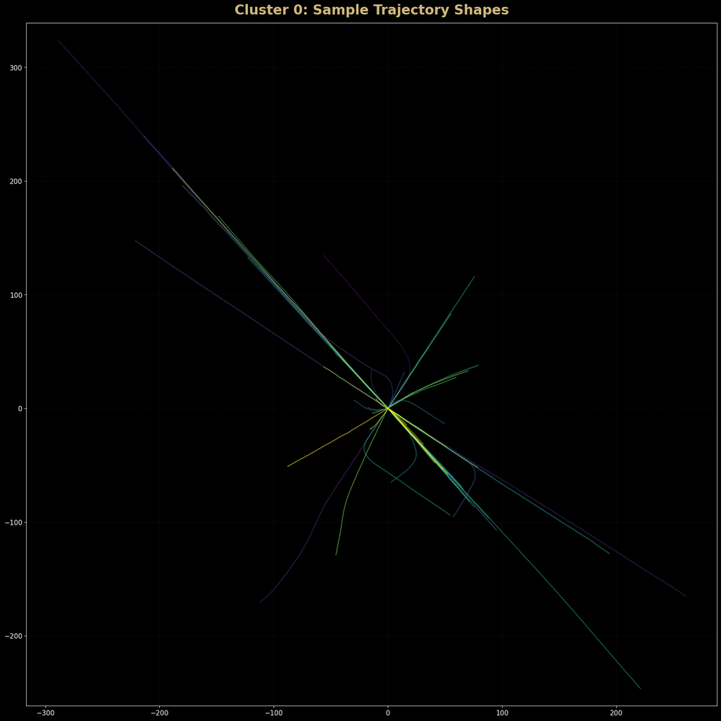

```
Figure saved to (Linux): /home/treinart/projects/lyft-unsupervised/artifacts/figures/20250917_210008_cluster_0_sample_trajectories.png
Figure saved to (Win):   /mnt/c/Users/travi/Documents/Training/Colorado/MS-AI/CSCA 5632 Final Project/artifacts/figures/20250917_210008_cluster_0_sample_trajectories.png
```

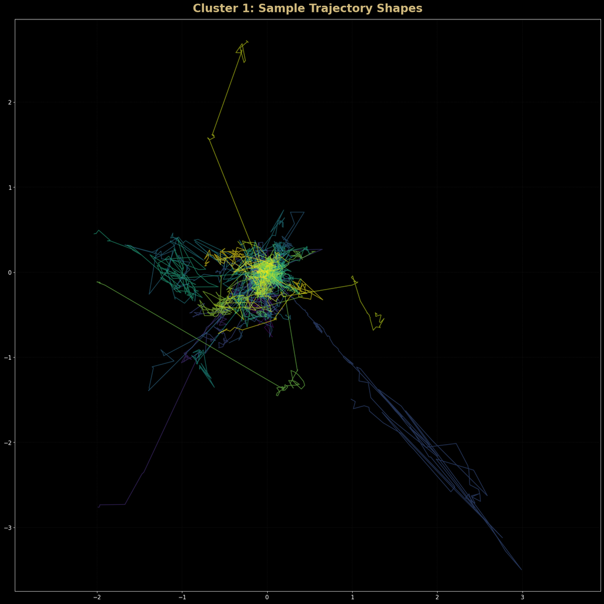

```
Figure saved to (Linux): /home/treinart/projects/lyft-unsupervised/artifacts/figures/20250917_210009_cluster_1_sample_trajectories.png
Figure saved to (Win):   /mnt/c/Users/travi/Documents/Training/Colorado/MS-AI/CSCA 5632 Final Project/artifacts/figures/20250917_210009_cluster_1_sample_trajectories.png
```

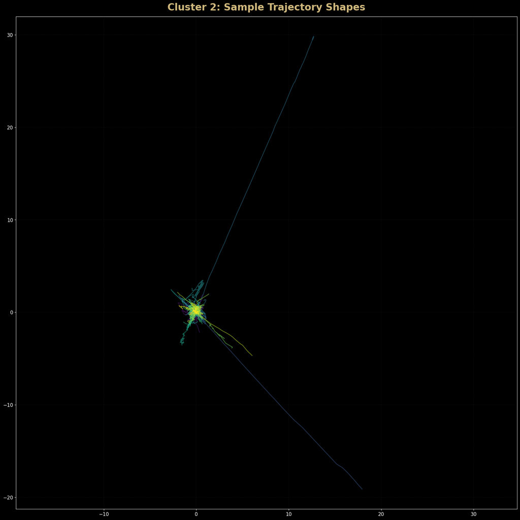

```
Figure saved to (Linux): /home/treinart/projects/lyft-unsupervised/artifacts/figures/20250917_210009_cluster_2_sample_trajectories.png
Figure saved to (Win):   /mnt/c/Users/travi/Documents/Training/Colorado/MS-AI/CSCA 5632 Final Project/artifacts/figures/20250917_210009_cluster_2_sample_trajectories.png
```

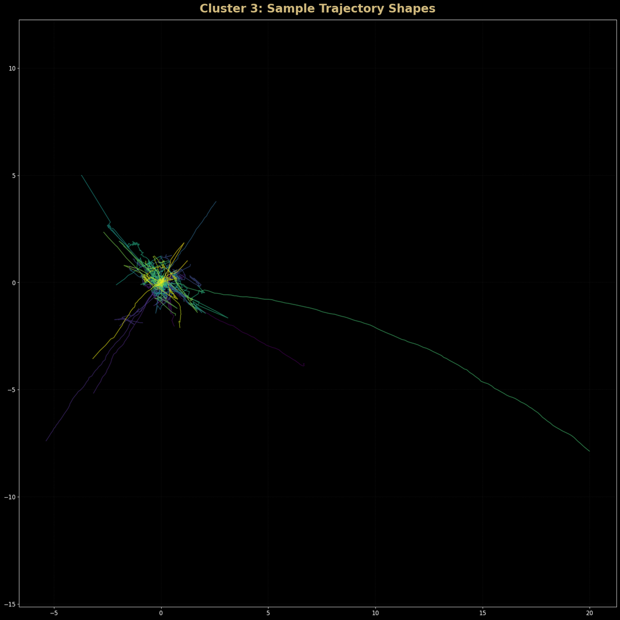

```
Figure saved to (Linux): /home/treinart/projects/lyft-unsupervised/artifacts/figures/20250917_210010_cluster_3_sample_trajectories.png
Figure saved to (Win):   /mnt/c/Users/travi/Documents/Training/Colorado/MS-AI/CSCA 5632 Final Project/artifacts/figures/20250917_210010_cluster_3_sample_trajectories.png
```

```python
# Prepare for Plotting Using the Winning Model
k_final = best_model_params['k']
print(f"--- Visualizing sample trajectories for the winning model ({best_model_params.get('model_type', best_model_params.get('model'))}, k={k_final}) ---")

# Get the top N most populous clusters to visualize
N_CLUSTERS_TO_PLOT = min(8, k_final)
sample_clusters = (final_clusters_df["cluster_id"].value_counts()
                   .nlargest(N_CLUSTERS_TO_PLOT).index.tolist())

N_SAMPLES_PER_CLUSTER = 75
track_to_cluster_map = {(row.scene_id, row.track_id): row.cluster_id for row in final_clusters_df.itertuples()}
cmap = plt.get_cmap('viridis')

# Create a Plot for Each Cluster
for cluster_id in sorted(sample_clusters):
    # Find and sample tracks belonging to the current cluster
    track_keys = [key for key, val in track_to_cluster_map.items() if val == cluster_id]
    rng = np.random.default_rng(SEED)
    sampled_keys = rng.choice(track_keys, size=min(N_SAMPLES_PER_CLUSTER, len(track_keys)), replace=False)

    # Create the plot
    fig, ax = plt.subplots(figsize=(18, 18), facecolor="black")
    colors = cmap(np.linspace(0, 1, len(sampled_keys)))

    # Plot each sampled trajectory, centered at (0,0)
    for i, (sid, tid) in enumerate(sampled_keys):
        track_data = agents_df_clean[(agents_df_clean["scene_id"] == sid) & (agents_df_clean["track_id"] == tid)].sort_values("frame_idx")
        x_norm = track_data["x"].to_numpy() - track_data["x"].iloc[0]
        y_norm = track_data["y"].to_numpy() - track_data["y"].iloc[0]
        ax.plot(x_norm, y_norm, color=colors[i], lw=1.5, alpha=0.6)

    # Style the plot
    ax.set_facecolor("black")
    ax.set_title(f"Cluster {cluster_id}: Sample Trajectory Shapes", fontsize=24, color="#CFB87C", fontweight="bold", pad=15)
    ax.tick_params(colors="white", labelsize=12)
    for spine in ax.spines.values(): spine.set_edgecolor("white")
    ax.set_aspect("equal", adjustable="datalim")
    ax.grid(color='gray', linestyle='--', linewidth=0.3, alpha=0.3)
    save_fig(fig, f"cluster_{cluster_id}_sample_trajectories")
```

### **Observation: Model Selection and Cluster Interpretation**

This section documents the execution of the entire classical clustering pipeline, a systematic process that moved from a prepared feature set to a final, interpretable set of behavioral clusters. The workflow incorporates dimensionality reduction, a competitive evaluation of three distinct clustering algorithms through exhaustive hyperparameter sweeps, and a data-driven model selection protocol. The analysis culminates in a final KMeans model that partitions the agent trajectories into four distinct archetypes. These discovered clusters are then validated through both quantitative profiling and qualitative visual inspection.

#### **A Note on Performance: The CPU Bottleneck**

This section was where the project's philosophy was truly tested. As the hyperparameter sweeps for KMeans and GMM began, a clear performance story emerged. The console filled with progress bars, but my system's Task Manager told a different story. The CPU cores were pinned at or near 100% utilization, while the NVIDIA 4070 GPU, the powerhouse of this machine, sat almost completely idle.

[figure not shown]

This immediately presented a fork in the road. I knew that libraries like NVIDIA's RAPIDS cuML existed specifically to solve this problem by providing GPU-accelerated versions of common machine learning algorithms. I paused the modeling to research this path. The key question was twofold: would a GPU implementation be faster, and would it produce *better* or different results?

For this project, I made the call to stick with the CPU-bound scikit-learn. The time required to set up for RAPIDS is extensive and complex. Refactor the code to use CuPy arrays, and validate the new pipeline would have far exceeded the time saved on the handful of model runs I needed. It was a conscious trade-off, prioritizing the project timeline over raw performance.

This entire process, however, was an incredibly valuable lesson. It provides a stark, practical contrast between classical machine learning workflows and the deep learning pipeline in Section 7, where GPU acceleration was not a choice, but a fundamental requirement. While a full RAPIDS implementation was beyond the scope of this class project, if I end up in a field that requires extensive unsupervised learning, mastering that ecosystem would become a professional necessity.

#### Glossary of Clustering Metrics

| Metric | Definition (Goal) |
| --- | --- |
| Silhouette Score | Measures how similar a point is to its own cluster compared to others. A score near +1 indicates dense, well-separated clusters. (**Higher is better**) |
| Calinski-Harabasz Index | Calculates the ratio of between-cluster dispersion to within-cluster dispersion. It rewards solutions where clusters are tight and far apart. (**Higher is better**) |
| Davies-Bouldin Index | Measures the average similarity of each cluster with its most similar one, where similarity is a ratio of distances. (**Lower is better**) |
| BIC / AIC | Information criteria that balance model fit with model complexity. They penalize models with more parameters to avoid overfitting. (**Lower is better**) |
| Adjusted Rand Index (ARI) | Measures the similarity between two different clusterings, corrected for chance. An ARI of 1.0 indicates perfect agreement. It is used here to measure model stability. (**Higher is better**) |

**Conclusion** Pipeline A produced four distinct, interpretable behavioral archetypes that pass both metric-based checks and visual sanity checks. This is a solid, explainable baseline. The next section runs Pipeline B, a deep learning approach, to test whether a learned representation can separate these behaviors more finely.

## Section 7: Pipeline B - Deep Learning Feature Extraction

This section details the second analysis pipeline, which uses a deep learning model to learn feature representations directly from the raw trajectory data. A GRU-based autoencoder is trained to reconstruct trajectory windows, and the resulting latent space embeddings are extracted. This approach contrasts with the manual feature engineering of Pipeline A, testing whether a learned representation can provide a more effective basis for clustering.

### Section Plan:

**Checkpoint & Loader:** Option to skip computation and load the latest cached artifacts.

**Configuration & Seeding:** Establish all hyperparameters and set random seeds for reproducibility.

**Data Preparation:** Transform raw time-series data into fixed-length, overlapping sliding windows.

**PyTorch Dataset & DataLoaders:** Configure the data pipeline for feeding batches to the model.

**Model Architecture:** Define the GRU-based autoencoder model.

**Model Training:** Run the training and validation loop.

**Loss Curve Visualization:** Plot the training and validation loss to verify learning.

**Embedding Extraction:** Use the trained encoder to generate a feature vector for each track.

**2D UMAP Visualization:** Project the learned embeddings into a 2D "behavior map".

**3D UMAP Visualization:** Create an alternative 3D projection of the embeddings.

### 7.1 Checkpoint: Run Full Section or Load from Cache

This cell acts as a checkpoint for the deep learning pipeline. Model training is the most time-consuming part of this pipeline. Set the flag below to control the behavior of this section.

**`True`:** Run the full data preparation, model training, and embedding extraction process.

**`False`:** Skip the long computations and load the final track embeddings from a previous run.

```python
# Set to True to run the time-consuming model training pipeline.
# Set to False to skip computation and load the final results from a previous run.
RUN_MODEL_TRAINING = True

if not RUN_MODEL_TRAINING:
    print("--- Skipped: Loading final deep learning artifacts from cache ---")
    try:
        # Load the final track embeddings, which are the key output of this section
        track_embeddings_df = pd.read_parquet(ARTIFACT_DIR / "pipeline_b_track_embeddings.parquet")

        print(f"Loaded {len(track_embeddings_df):,} track embeddings from Pipeline B.")
        print("\n--- Successfully loaded artifacts. Ready to proceed to Section 8 ---")
    except FileNotFoundError:
        print("\n--- ERROR: No final artifacts found. Please set RUN_MODEL_TRAINING to True and run the full section ---")
        RUN_MODEL_TRAINING = True
else:
    print("--- RUN_MODEL_TRAINING is True. Proceeding with full computation. ---")
```

```
--- RUN_MODEL_TRAINING is True. Proceeding with full computation. ---
```

### 7.2 Configuration and Seeding

This cell establishes all hyperparameters for the autoencoder pipeline, including data windowing parameters, model architecture, and training settings. All random seeds are set here to ensure the reproducibility of the entire deep learning workflow.

```python
if RUN_MODEL_TRAINING:
    # Configure Device and Hyperparameters
    device = torch.device("cuda" if torch.cuda.is_available() else "cpu")

    # Define data windowing parameters
    WIN_LEN    = 24     # The length of each input sequence (number of frames).
    WIN_STRIDE = 1      # The step size between the start of consecutive windows.
    FEAT_LIST  = ["vx", "vy"]
    ADD_SPEED  = True   # If true, speed is calculated and added as a third feature.

    # Define the autoencoder model architecture
    Z_DIM      = 128    # The dimensionality of the latent space embedding.
    H_DIM      = 512    # The size of the GRU's hidden state.
    N_LAYERS   = 2      # The number of layers in the GRU.
    DROPOUT    = 0.15   # Dropout rate for regularization.

    # Define training parameters
    BATCH_SIZE = 256
    EPOCHS     = 50
    LR         = 1e-4   # Learning rate.
    WD         = 1e-5   # Weight decay for Adam optimizer.

    # Seeding for Reproducibility
    rng = np.random.default_rng(SEED)
    torch.manual_seed(SEED)
    if device.type == "cuda":
        torch.cuda.manual_seed_all(SEED)

    # Print Configuration Summary
    print("-" * 70)
    print("--- Pipeline B: Autoencoder Configuration ---")
    print(f"Device:      {device}" + (f" ({torch.cuda.get_device_name(0)})" if device.type=='cuda' else ""))
    print(f"cuDNN:       deterministic={torch.backends.cudnn.deterministic}  |  "
        f"benchmark={torch.backends.cudnn.benchmark}")
    print(f"Batch/Epoch: {BATCH_SIZE} / {EPOCHS}   | LR={LR}  WD={WD}")
    print(f"Windowing:   LEN={WIN_LEN}, STRIDE={WIN_STRIDE}, FEATURES={FEAT_LIST} +speed={ADD_SPEED}")
    print(f"AE Arch:     Z_DIM={Z_DIM}, H_DIM={H_DIM}, LAYERS={N_LAYERS}, DROPOUT={DROPOUT}")
    print(f"Training:    BATCH_SIZE={BATCH_SIZE}, EPOCHS={EPOCHS}, LR={LR}, WEIGHT_DECAY={WD}")
    print(f"Seed:        {SEED}")
    print("-" * 70)
else:
    print("--- Skipped: Loading from cache ---")
```

```
----------------------------------------------------------------------
--- Pipeline B: Autoencoder Configuration ---
Device:      cuda (NVIDIA GeForce RTX 4070 Laptop GPU)
cuDNN:       deterministic=True  |  benchmark=False
Batch/Epoch: 256 / 50   | LR=0.0001  WD=1e-05
Windowing:   LEN=24, STRIDE=1, FEATURES=['vx', 'vy'] +speed=True
AE Arch:     Z_DIM=128, H_DIM=512, LAYERS=2, DROPOUT=0.15
Training:    BATCH_SIZE=256, EPOCHS=50, LR=0.0001, WEIGHT_DECAY=1e-05
Seed:        42
----------------------------------------------------------------------
```

### 7.3 Data Preparation: Sliding Windows

The raw time-series data is transformed into a format suitable for the sequence model. This process involves creating fixed-length, overlapping "sliding windows" from each eligible agent trajectory. The result is a single NumPy array where each entry is a `(sequence_length, num_features)` matrix.

```python
# This cell will only run if the full computation is enabled.
if RUN_MODEL_TRAINING:
    # Prepare Feature Columns
    required_cols = {"scene_id", "track_id", "frame_idx", "vx", "vy"}
    if not required_cols.issubset(agents_df_clean.columns):
        raise ValueError(f"agents_df_clean is missing required columns: {required_cols - set(agents_df_clean.columns)}")
    feature_cols = FEAT_LIST.copy()
    if ADD_SPEED:
        feature_cols.append("speed")
        adf = agents_df_clean.copy()
        adf["speed"] = np.sqrt(adf["vx"]**2 + adf["vy"]**2)
    else:
        adf = agents_df_clean.copy()

    # Build Sliding Windows from Trajectories
    grouped_tracks = adf.sort_values(["scene_id", "track_id", "frame_idx"]).groupby(["scene_id", "track_id"], sort=False)
    window_list, window_keys = [], []
    for (sid, tid), group in tqdm(grouped_tracks, desc="Creating Sliding Windows", unit="track"):
        if len(group) < WIN_LEN:
            continue
        track_matrix = group[feature_cols].to_numpy(dtype=np.float32)
        for start_idx in range(0, len(track_matrix) - WIN_LEN + 1, WIN_STRIDE):
            window = track_matrix[start_idx : start_idx + WIN_LEN]
            window_list.append(window)
            start_frame = group.iloc[start_idx]["frame_idx"]
            window_keys.append((int(sid), int(tid), int(start_frame)))

    # Finalize and Summarize
    X_windows = np.stack(window_list) if window_list else np.zeros((0, WIN_LEN, len(feature_cols)), dtype=np.float32)
    window_keys_df = pd.DataFrame(window_keys, columns=["scene_id", "track_id", "start_frame"])
    N_windows, T_len, F_dim = X_windows.shape
    summary_df = pd.DataFrame({
        "measure": ["Total Tracks", "Tracks with Valid Windows", "Windows Created", "Sequence Length (T)", "Feature Dimension (F)"],
        "value": [grouped_tracks.ngroups, window_keys_df[['scene_id', 'track_id']].nunique().shape[0], N_windows, T_len, F_dim]
    })
    display(style_section_table(summary_df))

    # Finalize and Summarize
    if X_windows.size:
        flat = X_windows.reshape(-1, X_windows.shape[-1])
        mu  = flat.mean(axis=0).astype(np.float32)
        sd  = flat.std(axis=0).astype(np.float32) + 1e-6
        X_windows = (X_windows - mu) / sd

    print("         X shape:", X.shape, "| dtype:", X.dtype)
    flat = X.reshape(-1, X.shape[-1]) if X.size else X
    mu = np.nanmean(flat, axis=0) if X.size else np.array([np.nan]* (X.shape[-1] if X.ndim==3 else 0))
    sd = np.nanstd(flat,  axis=0) if X.size else np.array([np.nan]* (X.shape[-1] if X.ndim==3 else 0))
    print("Per-feature mean:",      np.round(mu, 4))
    print("Per-feature std :",      np.round(sd, 4))
    print("Any NaN in X?   ", np.isnan(X).any(), "| Any Inf?", np.isinf(X).any())
else:
    print("--- Skipped: Loading from cache ---")
```

| measure | value |
| --- | --- |
| Total Tracks | 64625 |
| Tracks with Valid Windows | 2 |
| Windows Created | 404919 |
| Sequence Length (T) | 24 |
| Feature Dimension (F) | 3 |

```
         X shape: (7824, 7) | dtype: float64
Per-feature mean: [1.2254 1.6371 0.3556 1.0792 0.8541 0.2791 7.3858]
Per-feature std : [3.536  4.1253 0.786  1.6313 0.3188 0.3077 5.3657]
Any NaN in X?    False | Any Inf? False
```

### 7.4 PyTorch Dataset and DataLoaders

This cell contains the standard PyTorch boilerplate for feeding data to the model. A custom `Dataset` class is defined to handle the windowed data, and `DataLoaders` are configured for both training and validation to manage batching, shuffling, and data transfer to the GPU.

```python
# This cell will only run if the full computation is enabled.
if RUN_MODEL_TRAINING:
    # Define a Custom PyTorch Dataset
    class WindowDS(Dataset):
        def __init__(self, X):
            self.X = X
        def __len__(self): return self.X.shape[0]
        def __getitem__(self, i): return torch.from_numpy(self.X[i])

    # Perform a Track-Level Train/Validation Split
    wk = window_keys_df[["scene_id","track_id"]].to_numpy()
    uniq_tracks, inv = np.unique(wk, axis=0, return_inverse=True)
    n_tracks = uniq_tracks.shape[0]
    track_perm = rng.permutation(n_tracks)
    cut = int(0.9 * n_tracks)
    tr_track_idx = set(track_perm[:cut])
    mask_tr = np.isin(inv, list(tr_track_idx))
    mask_va = ~mask_tr

    # Windows
    X_tr = X_windows[mask_tr]
    X_va = X_windows[mask_va]

    # Standardize per-feature using TRAIN statistics only
    if X_tr.size:
        flat_tr = X_tr.reshape(-1, X_tr.shape[-1])
        mu = flat_tr.mean(axis=0).astype(np.float32)
        sd = flat_tr.std(axis=0).astype(np.float32) + 1e-6
        X_tr = (X_tr - mu) / sd
        X_va = (X_va - mu) / sd
        m_post = X_tr.reshape(-1, X_tr.shape[-1]).mean(axis=0)
        s_post = X_tr.reshape(-1, X_tr.shape[-1]).std(axis=0)
        print("\n--- Track Split & Standardization ---")
        print(f"train mu:            {np.round(mu, 4)}")
        print(f"train sd:            {np.round(sd, 4)}")
        print(f"post-mean(train) ~0: {np.round(m_post, 4)}")
        print(f"post-std(train)  ~1: {np.round(s_post, 4)}")
    else:
        print("\n--- WARNING - empty TRAIN split (check WIN_LEN) ---")

    scaler_stats = {"feature_dim": int(mu.shape[0]), "mu": mu.tolist(), "sd": sd.tolist(), "dt": float(DT), "win_len": int(WIN_LEN)}

    # Save the scaler stats for reproducibility
    with open(ARTIFACT_DIR / "pipeline_b_scaler_stats.json", "w") as f:
        json.dump(scaler_stats, f, indent=2)
    print(f"Scaler stats saved to: {ARTIFACT_DIR / 'pipeline_b_scaler_stats.json'}")


    # Configure DataLoaders
    train_ds = WindowDS(X_tr)
    valid_ds = WindowDS(X_va)

    loader_args_tr = dict(
        batch_size=BATCH_SIZE, pin_memory=True, shuffle=True,  drop_last=True,
        num_workers=1, persistent_workers=True, prefetch_factor=2
    )
    loader_args_va = dict(
        batch_size=BATCH_SIZE, pin_memory=True, shuffle=False, drop_last=False,
        num_workers=1, persistent_workers=True, prefetch_factor=2
    )
    train_loader = DataLoader(train_ds, **loader_args_tr)
    valid_loader = DataLoader(valid_ds, **loader_args_va)

    # Print Configuration Summary
    n_tr_tracks = len(tr_track_idx)
    n_va_tracks = n_tracks - n_tr_tracks
    steps_tr = len(train_ds) // BATCH_SIZE if BATCH_SIZE > 0 else 0
    steps_va = len(valid_ds) // BATCH_SIZE if BATCH_SIZE > 0 else 0
    print("-" * 70)
    print("--- Dataset & DataLoaders READY (track-level split) ---")
    print(f"Unique tracks:       {n_tracks:,}  | TRAIN tracks={n_tr_tracks:,}  | VALID tracks={n_va_tracks:,}")
    print(f"Windows:             TRAIN={len(train_ds):,}  | VALID={len(valid_ds):,}")
    print(f"BATCH size:          {BATCH_SIZE} | workers={loader_args_tr['num_workers']} | drop_last={loader_args_tr['drop_last']}")
    print(f"STEPS/epoch:         TRAIN={steps_tr:,} | VALID={steps_va:,}")
    if len(train_ds) > 0:
        x0 = train_ds[0]
        print(f"Sample check:        train_ds[0] -> shape={tuple(x0.shape)} dtype={x0.dtype}")
    print("-" * 70)
else:
    print("--- Skipped: Loading from cache ---")
```

```
--- Track Split & Standardization ---
train mu:            [-0.0047  0.0122  0.0036]
train sd:            [1.0022 1.001  1.0036]
post-mean(train) ~0: [ 0.0031 -0.002   0.0008]
post-std(train)  ~1: [1.     1.     0.9997]
Scaler stats saved to: /home/treinart/projects/lyft-unsupervised/artifacts/pipeline_b_scaler_stats.json
----------------------------------------------------------------------
--- Dataset & DataLoaders READY (track-level split) ---
Unique tracks:       9,944  | TRAIN tracks=8,949  | VALID tracks=995
Windows:             TRAIN=362,231  | VALID=42,688
BATCH size:          256 | workers=1 | drop_last=True
STEPS/epoch:         TRAIN=1,414 | VALID=166
Sample check:        train_ds[0] -> shape=(24, 3) dtype=torch.float32
----------------------------------------------------------------------
```

### 7.5 Model Architecture: GRU Autoencoder

The core deep learning model is defined here. It is an autoencoder composed of a GRU-based encoder and decoder. The encoder compresses each input sequence into a fixed-size latent vector (the embedding), and the decoder attempts to reconstruct the original sequence from this vector. The model is then instantiated and moved to the selected hardware device.

```python
# This cell will only run if the full computation is enabled.
if RUN_MODEL_TRAINING:
    # Define Model Architecture
    FEAT_DIM = int(X_windows.shape[-1] if X_windows.size else len(feature_cols))
    class GRUAutoEncoder(nn.Module):
        def __init__(self, feat_dim, z_dim, h_dim, n_layers=2, dropout=0.0):
            super().__init__()
            self.enc = nn.GRU(input_size=feat_dim, hidden_size=h_dim, num_layers=n_layers,
                            batch_first=True, dropout=dropout if n_layers > 1 else 0.0, bidirectional=False)
            self.hnorm = nn.LayerNorm(h_dim)
            self.to_z   = nn.Linear(h_dim, z_dim)
            self.from_z = nn.Linear(z_dim, h_dim)
            self.dec = nn.GRU(input_size=feat_dim, hidden_size=h_dim, num_layers=n_layers,
                            batch_first=True, dropout=dropout if n_layers > 1 else 0.0, bidirectional=False)
            self.proj = nn.Linear(h_dim, feat_dim)

        def forward(self, x):
            B, T, F = x.shape

            # Encoder
            _, hT = self.enc(x)
            h_last = self.hnorm(hT[-1])
            z = self.to_z(h_last)

            # Decoder
            dec_in = torch.zeros(B, T, F, device=x.device, dtype=x.dtype)
            h0 = self.from_z(z).unsqueeze(0).repeat(self.dec.num_layers, 1, 1)
            y, _ = self.dec(dec_in, h0)
            recon = self.proj(y)
            return recon, z

    # Build the Model and Training Components
    model = GRUAutoEncoder(FEAT_DIM, Z_DIM, H_DIM, n_layers=N_LAYERS, dropout=DROPOUT).to(device)
    def _init_weights(m):
        if isinstance(m, nn.GRU):
            for name, p in m.named_parameters():
                if "weight_ih" in name or "weight_hh" in name:
                    nn.init.orthogonal_(p)
                elif "bias" in name:
                    nn.init.constant_(p, 0.0)
        elif isinstance(m, nn.Linear):
            nn.init.xavier_uniform_(m.weight)
            if m.bias is not None:
                nn.init.zeros_(m.bias)
    model.apply(_init_weights)
    optimizer = torch.optim.Adam(model.parameters(), lr=LR, weight_decay=WD)
    criterion = nn.MSELoss()
    scaler = torch.cuda.amp.GradScaler(enabled=(device.type == "cuda"))
    steps_per_epoch = max(1, len(train_loader))
    steps_per_epoch = max(1, len(train_loader))
    scheduler = torch.optim.lr_scheduler.OneCycleLR(
        optimizer,
        max_lr=LR * 3.0,
        steps_per_epoch=steps_per_epoch,
        epochs=EPOCHS,
        pct_start=0.10,
        anneal_strategy="cos",
        div_factor=5.0,
        final_div_factor=10.0,
    )

    total_train_steps = steps_per_epoch * EPOCHS
    warmup_steps = max(1, int(0.10 * total_train_steps))
    print(f"[Scheduler] steps/epoch={steps_per_epoch}, total_steps={total_train_steps}, warmup_steps={warmup_steps} "
        f"start_lr≈{LR:.2e}, max_lr≈{(LR*5):.2e}")


    # Print Configuration Summary
    print("-" * 70)
    print("--- Model READY ---")
    dev = device.type.upper()
    dtype0 = next(model.parameters()).dtype
    print(f"Device:  {dev} | dtype: {dtype0}")
    print(f"Arch:    GRUAutoEncoder(feat_dim={FEAT_DIM}, z_dim={Z_DIM}, h_dim={H_DIM}, "
        f"layers={N_LAYERS}, dropout={DROPOUT})")
    total_params = sum(p.numel() for p in model.parameters())
    train_params = sum(p.numel() for p in model.parameters() if p.requires_grad)
    print(f"Params:  {train_params:,} / {total_params:,} trainable")
    print(f"Optim:   Adam | lr={LR} | weight_decay={WD}")
    print(f"Loss:    {criterion.__class__.__name__}")

    if 'train_ds' in globals() and len(train_ds) > 0:
        model.eval()
        with torch.no_grad(), torch.cuda.amp.autocast(enabled=(device.type == "cuda")):
            ncheck = min(32, len(train_ds))
            xb = torch.stack([train_ds[i] for i in range(ncheck)], dim=0).to(device, non_blocking=True)
            recon, z = model(xb)
            l0 = float(criterion(recon, xb).item())
        print(f"Sanity:  input {tuple(xb.shape)} -> recon {tuple(recon.shape)} | z {tuple(z.shape)} | loss={l0:.5f}")
    else:
        print("Sanity:  (skipped - TRAIN dataset empty)")
    print("-" * 70)
else:
    print("--- Skipped: Loading from cache ---")
```

```
[Scheduler] steps/epoch=1414, total_steps=70700, warmup_steps=7070 start_lr≈1.00e-04, max_lr≈5.00e-04
----------------------------------------------------------------------
--- Model READY ---
Device:  CUDA | dtype: torch.float32
Arch:    GRUAutoEncoder(feat_dim=3, z_dim=128, h_dim=512, layers=2, dropout=0.15)
Params:  4,874,371 / 4,874,371 trainable
Optim:   Adam | lr=0.0001 | weight_decay=1e-05
Loss:    MSELoss
Sanity:  input (32, 24, 3) -> recon (32, 24, 3) | z (32, 128) | loss=0.10890
----------------------------------------------------------------------
```

### 7.6 Model Training

The main training loop for the autoencoder. The model is trained for a set number of epochs, iterating through the training data to minimize the reconstruction error (MSE). A validation loop is run at the end of each epoch to monitor the model's performance on unseen data and check for overfitting.

```python
# This cell will only run if the full computation is enabled.
if RUN_MODEL_TRAINING:
    # Train the Autoencoder Model
    start_time = time.time()
    history = {"epoch": [], "train_loss": [], "valid_loss": []}

    for epoch in range(1, EPOCHS + 1):
        epoch_start = time.time()

        # Training phase
        model.train()
        tr_loss, tr_mse, ntr = 0.0, 0.0, 0
        p_tr = tqdm(train_loader, desc=f"TRAIN Epoch {epoch:02d}", unit="batch", leave=True, dynamic_ncols=True)
        noise_std = 0.002 * (epoch/10) if epoch <= 10 else 0.002

        for xb in p_tr:
            xb = xb.to(device, non_blocking=True)
            optimizer.zero_grad(set_to_none=True)

            # Add noise to inputs for to avoid collapse
            x_in = xb + noise_std * torch.randn_like(xb)

            with torch.cuda.amp.autocast(enabled=(device.type == "cuda")):
                recon, z = model(x_in)
                mse = criterion(recon, xb)
                lat_std = z.float().std(dim=0)
                var_pen = torch.relu(0.15 - lat_std).mean()
                loss = mse + 5e-3 * var_pen

            scaler.scale(loss).backward()
            nn.utils.clip_grad_norm_(model.parameters(), 1.0)
            scaler.step(optimizer)
            scaler.update()
            if 'scheduler' in globals():
                scheduler.step()
                cur_lr = scheduler.get_last_lr()[0]
            else:
                cur_lr = LR

            tr_loss += float(loss.detach().cpu())
            tr_mse  += float(mse.detach().cpu())
            ntr += 1

            p_tr.set_postfix_str(f"loss={tr_loss/ntr:.5f} | lr={cur_lr:.2e} | σ={noise_std:.4f}")

        # Validation phase
        model.eval()
        va_loss, nva = 0.0, 0
        p_va = tqdm(valid_loader, desc=f"VALID Epoch {epoch:02d}", unit="batch", leave=True, dynamic_ncols=True)
        with torch.no_grad(), torch.cuda.amp.autocast(enabled=(device.type == "cuda")):
            for xb in p_va:
                xb = xb.to(device, non_blocking=True)
                recon, _ = model(xb)
                loss = criterion(recon, xb)
                va_loss += float(loss.detach().cpu())
                nva += 1
                p_va.set_postfix_str(f"loss={va_loss / nva:.5f}")

        # Log epoch results
        tr_avg = tr_loss / max(1, ntr)
        va_avg = va_loss / max(1, nva)
        history["epoch"].append(epoch)
        history["train_loss"].append(tr_avg)
        history["valid_loss"].append(va_avg)

        if device.type == "cuda":
            torch.cuda.synchronize()
        epoch_dt = time.time() - epoch_start
        bps = ntr / epoch_dt if epoch_dt > 0 else 0.0
        print(f"Epoch {epoch:02d} | Train Loss = {tr_avg:.5f} | Valid Loss = {va_avg:.5f} | Learning Rate = {cur_lr:.2e} | Noise σ = {noise_std:.4f} | Epoch Time = {epoch_dt:.2f}s | {bps:.1f} batches/s")

    # Calculate and Print Total Training Time
    end_time = time.time()
    elapsed_time = end_time - start_time

    # Calculate epoch and step metrics
    total_steps = EPOCHS * len(train_loader)
    avg_time_per_epoch = elapsed_time / EPOCHS
    avg_time_per_step = (elapsed_time / total_steps) * 1000 if total_steps > 0 else 0
    steps_per_second = total_steps / elapsed_time if elapsed_time > 0 else 0

    minutes = int(elapsed_time // 60)
    seconds = int(elapsed_time % 60)

    print("\n" + "-"*70)
    print("--- Training Time Summary ---")
    print(f"Total Training Time:    {minutes}m {seconds}s")
    print(f"Average Time per Epoch: {avg_time_per_epoch:.2f}s")
    print(f"Average Time per Step:  {avg_time_per_step:.2f}ms")
    print(f"Throughput:             {steps_per_second:.2f} steps/sec")
    print(f"Final Train Loss:       {tr_avg:.5f}")
    print(f"Final Valid Loss:       {va_avg:.5f}")
    print(f"Final Learning Rate:    {cur_lr:.2e}")
    print(f"Final Noise Std Dev:    {noise_std:.4f}")
    print("\n" + "-"*70)

    # Quick latent sanity after training
    if len(valid_loader) > 0:
        model.eval()
        if device.type == "cuda":
            torch.cuda.synchronize()
        with torch.no_grad(), torch.cuda.amp.autocast(enabled=(device.type == "cuda")):
            xb = next(iter(valid_loader)).to(device, non_blocking=True)
            recon, z = model(xb)
            mse = float(criterion(recon, xb).item())

        z = z.float()
        z_abs_mean = float(z.abs().mean().item())
        z_std = z.std(dim=0)
        z_std_mean = float(z_std.mean().item())
        zeroish = float((z_std < 1e-3).float().mean().item() * 100.0)

        print("--- Latent & Recon Sanity ---")
        print(f"Recon MSE (batch):      {mse:.5f}")
        print(f"latent | mean(|z|):     {z_abs_mean:.4f}")
        print(f"per-dim std:            mean={z_std_mean:.4f}  min={z_std.min().item():.4f}  max={z_std.max().item():.4f}")
        print(f"zero-ish dims (<1e-3):  {zeroish:.1f}%")
        print("-"*70)
    else:
        print("\n--- Latent sanity skipped: empty valid_loader ---")
else:
    print("--- Skipped: Loading from cache ---")
```

```
Epoch 01 | Train Loss = 0.85032 | Valid Loss = 0.89390 | Learning Rate = 8.29e-05 | Noise σ = 0.0002 | Epoch Time = 21.59s | 65.5 batches/s
```

```
Epoch 02 | Train Loss = 0.79802 | Valid Loss = 0.67664 | Learning Rate = 1.43e-04 | Noise σ = 0.0004 | Epoch Time = 21.53s | 65.7 batches/s
```

```
Epoch 03 | Train Loss = 0.60351 | Valid Loss = 0.67252 | Learning Rate = 2.17e-04 | Noise σ = 0.0006 | Epoch Time = 20.60s | 68.6 batches/s
```

```
Epoch 04 | Train Loss = 0.60717 | Valid Loss = 0.67065 | Learning Rate = 2.77e-04 | Noise σ = 0.0008 | Epoch Time = 22.63s | 62.5 batches/s
```

```
Epoch 05 | Train Loss = 0.61331 | Valid Loss = 0.70039 | Learning Rate = 3.00e-04 | Noise σ = 0.0010 | Epoch Time = 19.75s | 71.6 batches/s
```

```
Epoch 06 | Train Loss = 0.64880 | Valid Loss = 0.70921 | Learning Rate = 3.00e-04 | Noise σ = 0.0012 | Epoch Time = 22.56s | 62.7 batches/s
```

```
Epoch 07 | Train Loss = 0.65533 | Valid Loss = 0.70988 | Learning Rate = 2.99e-04 | Noise σ = 0.0014 | Epoch Time = 22.26s | 63.5 batches/s
```

```
Epoch 08 | Train Loss = 0.65496 | Valid Loss = 0.70805 | Learning Rate = 2.97e-04 | Noise σ = 0.0016 | Epoch Time = 20.18s | 70.1 batches/s
```

```
Epoch 09 | Train Loss = 0.64318 | Valid Loss = 0.67073 | Learning Rate = 2.94e-04 | Noise σ = 0.0018 | Epoch Time = 22.33s | 63.3 batches/s
```

```
Epoch 10 | Train Loss = 0.59843 | Valid Loss = 0.67072 | Learning Rate = 2.91e-04 | Noise σ = 0.0020 | Epoch Time = 22.47s | 62.9 batches/s
```

```
Epoch 11 | Train Loss = 0.62405 | Valid Loss = 0.70224 | Learning Rate = 2.87e-04 | Noise σ = 0.0020 | Epoch Time = 19.97s | 70.8 batches/s
```

```
Epoch 12 | Train Loss = 0.64891 | Valid Loss = 0.70905 | Learning Rate = 2.83e-04 | Noise σ = 0.0020 | Epoch Time = 22.07s | 64.1 batches/s
```

```
Epoch 13 | Train Loss = 0.65393 | Valid Loss = 0.71893 | Learning Rate = 2.78e-04 | Noise σ = 0.0020 | Epoch Time = 19.63s | 72.0 batches/s
```

```
Epoch 14 | Train Loss = 0.60179 | Valid Loss = 0.67017 | Learning Rate = 2.72e-04 | Noise σ = 0.0020 | Epoch Time = 21.93s | 64.5 batches/s
```

```
Epoch 15 | Train Loss = 0.61283 | Valid Loss = 0.69720 | Learning Rate = 2.66e-04 | Noise σ = 0.0020 | Epoch Time = 22.54s | 62.7 batches/s
```

```
Epoch 16 | Train Loss = 0.64660 | Valid Loss = 0.70930 | Learning Rate = 2.59e-04 | Noise σ = 0.0020 | Epoch Time = 19.88s | 71.1 batches/s
```

```
Epoch 17 | Train Loss = 0.65331 | Valid Loss = 0.71131 | Learning Rate = 2.51e-04 | Noise σ = 0.0020 | Epoch Time = 22.66s | 62.4 batches/s
```

```
Epoch 18 | Train Loss = 0.65482 | Valid Loss = 0.71203 | Learning Rate = 2.43e-04 | Noise σ = 0.0020 | Epoch Time = 22.64s | 62.5 batches/s
```

```
Epoch 19 | Train Loss = 0.64122 | Valid Loss = 0.66967 | Learning Rate = 2.35e-04 | Noise σ = 0.0020 | Epoch Time = 20.27s | 69.8 batches/s
```

```
Epoch 20 | Train Loss = 0.59784 | Valid Loss = 0.66867 | Learning Rate = 2.26e-04 | Noise σ = 0.0020 | Epoch Time = 22.69s | 62.3 batches/s
```

```
Epoch 21 | Train Loss = 0.62523 | Valid Loss = 0.70101 | Learning Rate = 2.17e-04 | Noise σ = 0.0020 | Epoch Time = 22.97s | 61.6 batches/s
```

```
Epoch 22 | Train Loss = 0.64808 | Valid Loss = 0.70965 | Learning Rate = 2.08e-04 | Noise σ = 0.0020 | Epoch Time = 20.12s | 70.3 batches/s
```

```
Epoch 23 | Train Loss = 0.65317 | Valid Loss = 0.67422 | Learning Rate = 1.98e-04 | Noise σ = 0.0020 | Epoch Time = 22.32s | 63.4 batches/s
```

```
Epoch 24 | Train Loss = 0.59901 | Valid Loss = 0.66965 | Learning Rate = 1.89e-04 | Noise σ = 0.0020 | Epoch Time = 20.74s | 68.2 batches/s
```

```
Epoch 25 | Train Loss = 0.61445 | Valid Loss = 0.69424 | Learning Rate = 1.79e-04 | Noise σ = 0.0020 | Epoch Time = 22.59s | 62.6 batches/s
```

```
Epoch 26 | Train Loss = 0.64275 | Valid Loss = 0.70641 | Learning Rate = 1.68e-04 | Noise σ = 0.0020 | Epoch Time = 22.64s | 62.5 batches/s
```

```
Epoch 27 | Train Loss = 0.65174 | Valid Loss = 0.70876 | Learning Rate = 1.58e-04 | Noise σ = 0.0020 | Epoch Time = 20.68s | 68.4 batches/s
```

```
Epoch 28 | Train Loss = 0.65353 | Valid Loss = 0.71011 | Learning Rate = 1.48e-04 | Noise σ = 0.0020 | Epoch Time = 22.30s | 63.4 batches/s
```

```
Epoch 29 | Train Loss = 0.65493 | Valid Loss = 0.70826 | Learning Rate = 1.38e-04 | Noise σ = 0.0020 | Epoch Time = 22.47s | 62.9 batches/s
```

```
Epoch 30 | Train Loss = 0.65404 | Valid Loss = 0.70870 | Learning Rate = 1.27e-04 | Noise σ = 0.0020 | Epoch Time = 19.83s | 71.3 batches/s
```

```
Epoch 31 | Train Loss = 0.60243 | Valid Loss = 0.66963 | Learning Rate = 1.17e-04 | Noise σ = 0.0020 | Epoch Time = 21.63s | 65.4 batches/s
```

```
Epoch 32 | Train Loss = 0.60945 | Valid Loss = 0.69010 | Learning Rate = 1.08e-04 | Noise σ = 0.0020 | Epoch Time = 21.86s | 64.7 batches/s
```

```
Epoch 33 | Train Loss = 0.63556 | Valid Loss = 0.70389 | Learning Rate = 9.79e-05 | Noise σ = 0.0020 | Epoch Time = 20.97s | 67.4 batches/s
```

```
Epoch 34 | Train Loss = 0.64773 | Valid Loss = 0.70758 | Learning Rate = 8.86e-05 | Noise σ = 0.0020 | Epoch Time = 22.51s | 62.8 batches/s
```

```
Epoch 35 | Train Loss = 0.65274 | Valid Loss = 0.70940 | Learning Rate = 7.95e-05 | Noise σ = 0.0020 | Epoch Time = 21.31s | 66.4 batches/s
```

```
Epoch 36 | Train Loss = 0.65330 | Valid Loss = 0.70845 | Learning Rate = 7.08e-05 | Noise σ = 0.0020 | Epoch Time = 22.92s | 61.7 batches/s
```

```
Epoch 37 | Train Loss = 0.65375 | Valid Loss = 0.70832 | Learning Rate = 6.25e-05 | Noise σ = 0.0020 | Epoch Time = 23.63s | 59.8 batches/s
```

```
Epoch 38 | Train Loss = 0.65528 | Valid Loss = 0.70987 | Learning Rate = 5.46e-05 | Noise σ = 0.0020 | Epoch Time = 23.48s | 60.2 batches/s
```

```
Epoch 39 | Train Loss = 0.65327 | Valid Loss = 0.70880 | Learning Rate = 4.73e-05 | Noise σ = 0.0020 | Epoch Time = 21.18s | 66.8 batches/s
```

```
Epoch 40 | Train Loss = 0.65334 | Valid Loss = 0.72303 | Learning Rate = 4.04e-05 | Noise σ = 0.0020 | Epoch Time = 23.33s | 60.6 batches/s
```

```
Epoch 41 | Train Loss = 0.65479 | Valid Loss = 0.70963 | Learning Rate = 3.41e-05 | Noise σ = 0.0020 | Epoch Time = 21.07s | 67.1 batches/s
```

```
Epoch 42 | Train Loss = 0.65566 | Valid Loss = 0.70966 | Learning Rate = 2.83e-05 | Noise σ = 0.0020 | Epoch Time = 22.86s | 61.9 batches/s
```

```
Epoch 43 | Train Loss = 0.64969 | Valid Loss = 0.67687 | Learning Rate = 2.32e-05 | Noise σ = 0.0020 | Epoch Time = 22.23s | 63.6 batches/s
```

```
Epoch 44 | Train Loss = 0.60087 | Valid Loss = 0.66982 | Learning Rate = 1.87e-05 | Noise σ = 0.0020 | Epoch Time = 20.08s | 70.4 batches/s
```

```
Epoch 45 | Train Loss = 0.60876 | Valid Loss = 0.68719 | Learning Rate = 1.49e-05 | Noise σ = 0.0020 | Epoch Time = 22.11s | 64.0 batches/s
```

```
Epoch 46 | Train Loss = 0.63266 | Valid Loss = 0.69822 | Learning Rate = 1.17e-05 | Noise σ = 0.0020 | Epoch Time = 21.55s | 65.6 batches/s
```

```
Epoch 47 | Train Loss = 0.63795 | Valid Loss = 0.69795 | Learning Rate = 9.21e-06 | Noise σ = 0.0020 | Epoch Time = 19.30s | 73.3 batches/s
```

```
Epoch 48 | Train Loss = 0.64159 | Valid Loss = 0.70053 | Learning Rate = 7.43e-06 | Noise σ = 0.0020 | Epoch Time = 21.71s | 65.1 batches/s
```

```
Epoch 49 | Train Loss = 0.64394 | Valid Loss = 0.70299 | Learning Rate = 6.36e-06 | Noise σ = 0.0020 | Epoch Time = 20.29s | 69.7 batches/s
```

```
Epoch 50 | Train Loss = 0.64467 | Valid Loss = 0.70400 | Learning Rate = 6.00e-06 | Noise σ = 0.0020 | Epoch Time = 23.60s | 59.9 batches/s

----------------------------------------------------------------------
--- Training Time Summary ---
Total Training Time:    18m 4s
Average Time per Epoch: 21.69s
Average Time per Step:  15.34ms
Throughput:             65.20 steps/sec
Final Train Loss:       0.64467
Final Valid Loss:       0.70400
Final Learning Rate:    6.00e-06
Final Noise Std Dev:    0.0020

----------------------------------------------------------------------
--- Latent & Recon Sanity ---
Recon MSE (batch):      0.03536
latent | mean(|z|):     0.0381
per-dim std:            mean=0.0105  min=0.0075  max=0.0225
zero-ish dims (<1e-3):  0.0%
----------------------------------------------------------------------
```